# gan_cifar10

```python
# ==================== #
# Name: Kenneth Chen #
# Student ID: 2100072  #
# ==================== #

# Notebook Configuration
GPU_COUNT = 1
WINDOWS = True
import os
os.environ["KMP_DUPLICATE_LIB_OK"]="TRUE"
```

```python
!pip install -q pandas
!pip install -q seaborn
!pip install -q matplotlib
!pip install -q torchmetrics
!pip install -q scikit-learn
!pip install -q torch-fidelity
```

[output not shown]

[figure not shown]

### References and Credits

I would like to thank the collaborators and developers at POSTECH StudioGAN for providing the reference code to work with and adapt from. Nevertheless, I suffered way too many headaches trying to adapt their python code structure into a Jupyter Notebook format. [GitHub](https://github.com/POSTECH-CVLab/PyTorch-StudioGAN/).

References:

1. Arjovsky, M. and Bottou, L. (2017) ‘Towards Principled Methods for Training Generative Adversarial Networks’. arXiv. Available at: http://arxiv.org/abs/1701.04862 (Accessed: 13 January 2023).
2. Arjovsky, M., Chintala, S. and Bottou, L. (2017) ‘Wasserstein GAN’. arXiv. Available at: http://arxiv.org/abs/1701.07875 (Accessed: 27 January 2023).
3. Borji, A. (2018) ‘Pros and Cons of GAN Evaluation Measures’. arXiv. Available at: http://arxiv.org/abs/1802.03446 (Accessed: 13 January 2023).
4. Brock, A., Donahue, J. and Simonyan, K. (2019) ‘Large Scale GAN Training for High Fidelity Natural Image Synthesis’. arXiv. Available at: http://arxiv.org/abs/1809.11096 (Accessed: 27 January 2023).
5. Brownlee, J. (2019a) ‘18 Impressive Applications of Generative Adversarial Networks (GANs)’. Machine Learning Mastery. Available at: https://machinelearningmastery.com/impressive-applications-of-generative-adversarial-networks/ (Accessed: 8 January 2023).
6. Brownlee, J. (2019b) ‘A Gentle Introduction to Generative Adversarial Networks (GANs)’. Machine Learning Mastery. Available at: https://machinelearningmastery.com/what-are-generative-adversarial-networks-gans/ (Accessed: 8 January 2023).
7. Goodfellow, I., Bengio, Y. and Courville, A. (2016) Deep learning. Cambridge, Massachusetts: The MIT Press (Adaptive computation and machine learning).
8. Goodfellow, I.J. et al. (2014) ‘Generative Adversarial Networks’. arXiv. Available at: http://arxiv.org/abs/1406.2661 (Accessed: 8 January 2023).
9. He, K. et al. (2015) ‘Deep Residual Learning for Image Recognition’. arXiv. Available at: http://arxiv.org/abs/1512.03385 (Accessed: 27 January 2023).
10. Kang, M. et al. (2021) ‘Rebooting ACGAN: Auxiliary Classifier GANs with Stable Training’. arXiv. Available at: http://arxiv.org/abs/2111.01118 (Accessed: 10 January 2023).
11. Karras, T. et al. (2020) ‘Analyzing and Improving the Image Quality of StyleGAN’. arXiv. Available at: http://arxiv.org/abs/1912.04958 (Accessed: 8 January 2023).
12. Krizhevsky, A. (2009) ‘CIFAR-10 and CIFAR-100 datasets’. cs.toronto.edu. Available at: Alex Krizhevsky, 2009 (Accessed: 12 January 2023).
13. Lim, J.H. and Ye, J.C. (2017) ‘Geometric GAN’. arXiv. Available at: http://arxiv.org/abs/1705.02894 (Accessed: 28 January 2023).
14. Mathieu, E. et al. (2019) ‘Disentangling Disentanglement in Variational Autoencoders’. arXiv. Available at: http://arxiv.org/abs/1812.02833 (Accessed: 16 January 2023).
15. Miyato, T. et al. (2018) ‘Spectral Normalization for Generative Adversarial Networks’. arXiv. Available at: http://arxiv.org/abs/1802.05957 (Accessed: 27 January 2023).
16. Miyato, T. and Koyama, M. (2018) ‘cGANs with Projection Discriminator’. arXiv. Available at: http://arxiv.org/abs/1802.05637 (Accessed: 17 January 2023).
17. Muppalla, V. and Hendryx, S. (2022) ‘Diffusion Models: A Practical Guide’. scale.com. Available at: https://scale.com/guides/diffusion-models-guide (Accessed: 8 January 2023).
18. Rocca, J. (2019) ‘Understanding Variational Autoencoders (VAEs)’. Medium. Available at: https://towardsdatascience.com/understanding-variational-autoencoders-vaes-f70510919f73 (Accessed: 8 January 2023).
19. Salimans, T. et al. (2016) ‘Improved Techniques for Training GANs’. arXiv. Available at: http://arxiv.org/abs/1606.03498 (Accessed: 27 January 2023).
20. Softology, J. (2019) ‘Style Transfer GANs (Generative Adversarial Networks)’. Softology’s Blog. Available at: https://softologyblog.wordpress.com/2019/03/31/style-transfer-gans-generative-adversarial-networks/ (Accessed: 10 January 2023).
21. Tewari, A. (N.d.) ‘Types of Generative Adversarial Networks’. OpenGenus IQ. Available at: https://iq.opengenus.org/types-of-gans/ (Accessed: 8 January 2023).
22. Yazıcı, Y. et al. (2019) ‘The Unusual Effectiveness of Averaging in GAN Training’. arXiv. Available at: http://arxiv.org/abs/1806.04498 (Accessed: 27 January 2023).
23. Zhang, H. et al. (2019) ‘Self-Attention Generative Adversarial Networks’. arXiv. Available at: http://arxiv.org/abs/1805.08318 (Accessed: 16 January 2023).
24. Zhao, S. et al. (2020) ‘Differentiable Augmentation for Data-Efficient GAN Training’. arXiv. Available at: http://arxiv.org/abs/2006.10738 (Accessed: 27 January 2023).

# Generative Adversarial Networks - CIFAR10

> Can we create a strong generative model for CIFAR10 using the GAN architecture?

## Background Research 📖

### Introduction 💡

The ultimate goal of Deep Learning is to be able to create a function that can **effectively model any form of data distribution**. History has time and time again displayed the impressive success of discriminators, models that learn to divide the data distribution/map a high dimensional vector to one that is lower (Goodfellow et al., 2014). For instance, tasks such as Image Classification are one type of discriminative modelling, as the high dimensional images are mapped into low dimensional probabilities of labels.

What about generative modelling? In generative modelling, the goal is instead given a data distribution to learn from, to produce or **generate new examples** that follow this distribution but still aim to be unique. Thus, a high performing generative model should be able to create examples that are both **plausible** (in that one can recognize what the generated example is supposed to be of) **and indistinguishable** from real data examples (Brownlee, 2019). Generative models can be Unsupervised or Semi-Supervised, depending on the exact task that one is trying to tackle.

There are different approaches to network architectures when it comes to trying to achieve Generative Models:

- Generative Adversarial Networks (GAN)
- Diffusion Models
- Variational Auto Encoders (VAE)

**GANs ⚔️**  
GANs are the main focus of this notebook. Proposed by Ian Goodfellow in 2014, it became one of the more popular types of Generative Models used. For instance, the commonly known website thispersondoesnotexist.com uses the StyleGAN2 architecture (Karras et al., 2020), to generate high fidelity images of humans. The idea for GANs is that **there are two networks that work against each other in a game**, where they try to one up each other. Thus, this leads to improvement in both networks. More details are discussed under "What's inside a GAN? 🔍".

**Diffusion Models ✨**  
These are the models that have been not only been successful, but widely popular as well. For instance, OpenAI Dall-E, Google Imagen, Stable Diffusion, Midjourney are models that fall under the category of Diffusion Models. (Muppalla and Hendryx, 2022). From a high level, it works like so:

- Noise is added to original images
- Noise is procedurally added until image is all noise
- The model then learns to remove the noise
- Guidance can be added in the form of e.g. text-to-image, to provide direction of the generation process

[figure not shown]

*Noise is procedurally added to the image. Image Credit: (Muppalla and Hendryx, 2022)*

[figure not shown]

*Model attempts to recreate the image. Image Credit: (Muppalla and Hendryx, 2022)*

**Variational Auto Encoders 🎲**  
We first take a look at what Auto Encoders are. An Auto Encoder is trained for it to learn to copy the input to the output (Goodfellow, Bengio and Courville, 2016). This is done by having an **encoder map the image** to a compressed representation of the image (the inner nodes), to which the decoder **uses this compressed representation** to generate an image similar to the original. Note that the trick is to **restrict the number of inner nodes** inside the network, such that it is **not able to generate a 1-to-1 copy**. This way, it's forced to learn the most promiment of features to recognize, using the limited number of nodes.

The idea with Variational Auto Encoders is that **instead of the encoder just mapping the image to a compressed representation** (aka latent vector), we instead **learn the distribution that the latent vector can take on**. Using this, we can then randomly sample from the learned latent distribution, for the decoder to give us a newly and controlled generated image.

[figure not shown]

*VAE Architecture. We note the learning of the latent distribution in the form of $\mu$ (mean) and $\sigma$ (standard deviation). Image Credit: (Rocca, 2019)*

### What's inside a GAN? 🔍

In a GAN, there are in fact two networks, a **generator** and a **discriminator** that improve each other by competing in a game scenario (Goodfellow, Bengio and Courville, 2016). The aim is to use the well established field of discriminators to assist the generator. The goal of the generator is to **create realistic images** that appear to be from the distribution of the training images, where as the goal of the discriminator is to determine **if a given image is from the data distribution**. The process goes as follows:

1. Generator creates images
2. Discriminator learns to distinguish real vs fake from a set of real images and these newly generated images
3. Using the updated Discriminator, Generator learns to trick the Discriminator

Mathematically speaking, the process of GANs can be described as so. Suppose we have some a random distribution or a "prior", which we can sample from. We can denote this as $p_z(z)$, where $z$ represents a vector of a specific size. This vector acts as the input to our generative model $G$. The model is ultimately described as $G(z; \theta_g)$ where $\theta_g$ represents the parameters of the generative model.

This "game" between the two models can be thought of as trying to optimize of minimax function of:

$$\underset{G}{\text{min}}\underset{D}{\text{max}} V(D, G) = \mathbb{E}_{x \sim p_{\text{data}}(x)} [\text{log}D(x)] + \mathbb{E}_{z \sim p_{\text{z}}(z)} [\text{log}(1 - D(G(z)))]$$

*(Goodfellow et al., 2014)*

Essentially, the function $V$ takes in two inputs, our models $D$ and $G$, and returns an output that has two parts. The left hand part of the sum $\mathbb{E}_{x \thicksim p_{\text{data}}(x)} [\text{log}D(x)]$ represents "the expected value that the discriminator model predicts real data is real". The right hand part of the sum $\mathbb{E}_{z \thicksim p_{\text{z}}(z)} [\text{log}(1 - D(G(z)))]$ looks at given some random vector $z$, "what is the expected value that the discriminator model predicts fake data is fake", in that the value of the right hand part is maximum when discriminator model is successful at labeling the fake images of a generator as fake.

$\underset{G}{\text{min}}\underset{D}{\text{max}}$ aims to do two things. Firstly, what is the generator model $G$ that *minimizes the value*, which means *the discriminator labels generator's images as real*. Secondly what is the disciminator model $D$ that will maximize this value, which means **discriminator model predicts real images as real and fake images as fake**. These two perfectly optimize each other, when the best approach the discriminator can take is to **just guess randomly** as the generator images are on the same realism as the real data.

### Types of GANs 🍐

There many different types of GANs, however I believe the most differing pair is the Vanilla GAN and the Conditional GAN. The Vanilla GAN is what was proposed by Ian Goodfellow in 2014, which consists of the basic architecture with multi-layer perceptrons (MLPs). Conditional GANs are different in the aspect that one can provide additional information to the model, which could be thought of as a form of guidance similar to diffusion models.

[figure not shown]

*Vanilla GAN architecture (Tewari, N.d.)*

[figure not shown]

*Conditional GAN architecture (Tewari, N.d.)*

We observe that there is an extra component of `y`, which represents the extra information presented both to the Generator and Discriminator. This extra information is usually in the form of class labels to allow one to possess control over the output, but it can be extended to different modal data, even something such as text (in which case it needs some sort of text processor).

One may think of Conditional GAN as a more *"supervised" version* of Vanilla GANs, as some condition techniques (in the form of perhaps label information) are provided **to support the adversarial training**. Conditional GANs have in fact become **the go-to method of generating high-quality images** (Kang et al., 2021). This may be due to the fact that **when image sizes become larger** and there is **no sense of direction**, there can be a **significant** amount of overlapping generation that occurs.

What's more, is that even among Conditional GANs, the category can be further broken down into different methods of **inputing this conditional information**. The common methods are:

1. Conditioning by concatenation
2. Conditioning with projection discriminator
3. Conditioning with auxiliary classifier
4. Conditioning with batch normalization

In this notebook, we utilize and explore the above 4 techniques.

### Uses of GANs 🧤

As a GAN is a generative model, there are a large number of applications of GANs (Brownlee, 2019). Personally, I find it interesting how the idea of GANs can be adjusted for any modal of data, as long as the architecture for the encoder and decoders are adjusted accordingly. Here are a few areas of GANs I believe are quite intriguing:

- Time Series
- Image Generation
- Music Generation
- Audio Generation
- Style Transfer (e.g. winter photo to summer photo, jazz to classical music)

Among them, I think Audio Generation stands out to me the most. The idea of using GANs in music composition sounds like a difficult challenge, but also an impressive feat if one could pull it off.

### The difficulty with GANs 🧩

Despite having achieved great success at generating realistic and sharp looking images, they are still remarkably difficult to train (Arjovsky and Bottou, 2017). Different symptoms/signs may appear as a result of non-optimal training process or architecture. Below, we attempt to discuss what such that we are able to know what to pay attention to, when developing our GANs as well.

#### Mode collapse

One of the largest and continuing issues with the GAN training process is mode collapse. Mode collapse is said to occur if the generator **maps multiple different vectors** $z$ to the same output of $x$, where $x$ is a vector which the **discriminator assigns high probability of being real** to. In other words, the generator **exploits the discovery** that a particular output can fool the generator and thus ultimately produces, **decreasing the diversity of one's outputs**.

#### Mode Dropping

This is another case of decreasing the diversity of one's outputs, however not in the same way as Mode Collapse. In Mode Collapse, diversity is decreased within the classes. However, in Mode Dropping, diversity is decreased **among the classes**. Specifically, the generator may learn that for certain classes, it is difficult to generate an image, sufficiently realistic enough to trick the generator. Thus the generator may learn to simply just ignore these difficult classes, to be the most effective in the game against discriminator.

#### Non-Lipschitz Continuity

A real-valued function $f: \mathbb{R} \rightarrow \mathbb{R}$ possesses the property of Lipschitz continuity if

$$ |f(x_1) - f(x_2) | \leq K|x_1 - x_2| $$

where $K$ is some constant and $x$ represents the input. Intuitively, this means that when we change the value of $x$, we can expect to be **relatively small**, in that the change can be described as a result of linear growth rather than **uncontrolled growth**.

**What does this mean in the context of neural networks?** Suppose we have some network that **does not** possess the property of being Lipschitz continuous (this is possible because neural networks are essentially a composition of functions). As there is no bound of $K$, it means the output of the function can grow uncontrollably and a small change in the input **can possibly lead to large changes in the output**. This is bad for GANs, as we lose our sense of control and also means that moving along one dimension may result in drastically different changes in the output.

If we can enforce Lipschitz continuity in GANs, it means that a small change in the input, guarantees a relative small change in the output as well, which is what we want. One method of achieving this is to utilize a different loss function in GANs such as Wasserstein Distance. We explore approaches to tackling this issue further in the *"Developing GANs"* section.

### **GAN Metrics**: what does it mean to be good?

The most straight forward method of telling whether the output of a GAN is good, is to well, use our human eyes. On a smaller-sized experiment or if one is assessing a few images, this may be a valid approach. However, when the amount of data scale up to a very large quantity (which naturally is the case with Deep Learning), the act of visually inspecting every output is **simply infeasible**. Besides, using our eye as a metric means our feedback is **qualitative**. This means if it comes down to comparing the performances of two incredibly well-performing models, it's also difficult for one to tell which one is better. Thus, we need to define a set of quantitative metrics that we can use to substitute the use of our human eyes.

There is no one metric that is the *"best"* (Borji, 2018). Each metric has its own advantages and disadvantages, but ideally an efficient evaluation metric should:

1. high quality
2. diverse
3. disentangled latent space

*(Borji, 2018)*

What is **Disentangled Latent Space**? Latent space is straight forward, it's the typically smaller representation that in the context of GANs, acts as the input to the generator network. Disentangled latent space means that going along one dimension of the latent space representation, the changes reflected in the output should have only an appropriate level of overlap with outputs achieved by going along a different dimension. Thus, there are a few cases:

[figure not shown]

*(Mathieu et al., 2019)*

Above is the context in Variational Auto Encoders, however as the problem statement of generator images to mimic the real distribution is the same, thus the evaluation metrics being the same as well, I use the image to explain how the concept of disentangled latent space in the context of GANs.

We see there are a total of 3 possible cases:

- Insufficient overlap
- Appropriate Overlap
- Too Much Overlap

In the case of insufficient overlap, we see that moving along the latent distribution $p(z)$ provides the property of independence, in that there are no two latent spaces that affect two features of the output. However, the problem is that the generated image distribution is not, does not take up much of our ideal output distribution $p_{\theta}(x)$. In the case of too much overlap, as indicated by the large overlapping regions, it tells us that moving along one dimension of the latent space leads to a change in many different images among the distribution (which in this 2d representation can be interpretted as changing too many of the same features). Thus, the ideal or appropriate level of overlap here, as seen in the center image, is where there is a good level of independence, in that moving along one dimension of the latent space vector results to changes associated only with the latent space vector, and where the covered area is also large, taking up most of the space of our distribution $p_{\theta}(x)$.

How about the two others -- quality and diversity?

##### **Measuring Quality**

What we mean by quality here is not the resolution of the image (doesn't make sense for the generator to output high-res images when the training data is low resolution). Here, quality means how well one is able to recognize an image, as the class it is intended to be. The two most popular metrics are **Inception Score** and **Frechet Inception Distance**. The term **inception** comes from the fact that these two metrics **actually use** a pretrained Inception classifier to aid in producing the metric values.

- Inception Score **(IS)**
- Frechet Inception Distance **(FID)**

##### **Measuring Diversity**

If we simply **focused on quality-measuring metrics**, our models may still be susceptible to something like Mode Collapse or Mode Dropping. We try to aim for a quantitative metric such as:

- Learned Perceptual Image Patch Similarity **(LPIPS)**
- Number of statistically-different bins **(NDB)**

Further details of these metrics are discussed in later sections, when we evaluate the models.

# The CIFAR10 Dataset

[figure not shown]

As per our assignment, we are instructed to utilize the CIFAR10 dataset to **generate 1000 small colour images**.

The CIFAR-10 dataset consists of **60000** `32x32` colour images in a total of 10 classes, with 6000 images per class (Krizhevsky, 2009).

## Developing GAN 💻

> Let's get to building our Conditional GAN.

Besides, if one appreciates the idea of not knowing what a Vanilla GAN may output, a simple random module can be attached as the conditional information to somewhat *hack* the Conditional GAN into being a normal GAN.

### Objectives 🖊️

We identify the tasks and objectives we want to meet, which will be used as a guide throughout the development of our Conditional GAN.

1. Explore the CIFAR10 dataset
2. Implement and evaluate to find the best performing model
3. Analyse the final model

### Importing Libraries

The necessary libraries are imported below.

```python
import torch
from torch import nn, autograd
from torch.utils.data import DataLoader, DistributedSampler
import torch.distributed as dist
from torch.nn import init
import torch.nn.functional as F

import pandas as pd
import seaborn as sns
sns.set('notebook')
import matplotlib.pyplot as plt

from IPython.display import clear_output

from torchmetrics.image.fid import FrechetInceptionDistance
from tqdm import tqdm

import torchvision
from torchvision import transforms, models
from torchvision.utils import save_image
from torch.utils.model_zoo import load_url as load_state_dict_from_url

import copy
import numpy as np
import matplotlib.pyplot as plt
import seaborn as sns

import scipy

import math
import pandas as pd
import numpy as np

import logging
from datetime import datetime
from os.path import dirname, exists, join

import gc
```

### Utility Functions 🔨

We define some utility functions below that will ease and help us with our analysis.

```python
def identity(x):
	return x

def loc_data(data, loc):
	datacopy = copy.deepcopy(data)
	arr = np.array(datacopy.loc[loc].drop('label'))
	label = datacopy.loc[loc]['label']
	root = int(len(arr) ** 0.5)
	arr.resize((root, root))
	return label, arr

def reshape_weight_to_matrix(weight):
    weight_mat = weight
    dim = 0
    if dim != 0:
        weight_mat = weight_mat.permute(dim, *[d for d in range(weight_mat.dim()) if d != dim])
    height = weight_mat.size(0)
    return weight_mat.reshape(height, -1)

def make_logger(save_dir, run_name, log_output):
    if log_output is not None:
        run_name = log_output.split('/')[-1].split('.')[0]
    logger = logging.getLogger(run_name)
    logger.propagate = False
    log_filepath = log_output if log_output is not None else join(save_dir, "logs", run_name + ".log")

    log_dir = dirname(log_filepath)
    if not exists(log_dir):
        os.makedirs(log_dir)

    if not logger.handlers:  # execute only if logger doesn't already exist
        file_handler = logging.FileHandler(log_filepath, 'a', 'utf-8')
        stream_handler = logging.StreamHandler(os.sys.stdout)

        formatter = logging.Formatter('[%(levelname)s] %(asctime)s > %(message)s', datefmt="%Y-%m-%d %H:%M:%S")

        file_handler.setFormatter(formatter)
        stream_handler.setFormatter(formatter)

        logger.addHandler(file_handler)
        logger.addHandler(stream_handler)
        logger.setLevel(logging.INFO)
    return logger

def accm_values_convert_dict(list_dict, value_dict, step, interval):
    for name, value_list in list_dict.items():
        if step is None:
            value_list += [value_dict[name]]
        else:
            try:
                value_list[step // interval - 1] = value_dict[name]
            except IndexError:
                try:
                    value_list += [value_dict[name]]
                except:
                    raise KeyError
        list_dict[name] = value_list
    return list_dict

def imshow(arr: list, label: list = None, figsize = None, shape = (32, 32, 3), is_int = None, fig_shape = None):
	if is_int == None:
		if type(arr[0]) == torch.Tensor:
			is_int = (arr[0].detach().cpu().numpy() > 1).sum() > 0
		else:
			is_int = (arr[0] > 1).sum() > 0
	if len(label) == 0:
		label = [''] * len(arr)

	if fig_shape == None:
		height = int(len(arr) ** 0.5)
		width = math.ceil(len(arr) / height)
	else:
		height = fig_shape[0]
		width = fig_shape[1]

	X_means = np.array([0.4919, 0.4827, 0.4472])
	X_stds = np.array([0.2470, 0.2434, 0.2616])
	unnormalize = transforms.Normalize((-X_means / X_stds).tolist(), (1.0 / X_stds).tolist())

	if figsize == None:
		fig = plt.figure()
	else:
		fig = plt.figure(figsize=figsize)
	for i in range(height):
		for j in range(width):
			if (i * width + j >= len(arr)):
				break
			ax = fig.add_subplot(height, width, i * width + j + 1)
			ax.grid(False)
			ax.set_xticks([])
			ax.set_yticks([])
			show = arr[i * width + j]
			if type(arr[i * width + j]) != torch.Tensor:
				show = torch.Tensor(show)

			show = (show + 1) / 2
			if len(show.squeeze(0).cpu().shape) == 2:
				ax.imshow((show.squeeze(0).detach().cpu()).type(torch.uint8 if is_int else torch.float), cmap='gray')
			else:

				try:
					ax.imshow((show.squeeze(0).detach().cpu().permute(1,2,0)).type(torch.uint8 if is_int else torch.float))
				except:
					ax.imshow((show.squeeze(0).detach().cpu()).type(torch.uint8 if is_int else torch.float))
			ax.set_title(label[i * width + j])

	return fig, ax

def df_to_tensor(df, shape = (32, 32)):
	return torch.tensor(df.values.reshape((-1, *shape)), dtype=torch.float32)

def preprocess(df):
	return df.copy() / 255

def count_parameters(module):
    return "Number of parameters: {num}".format(num=sum([p.data.nelement() for p in module.parameters()]))
```

[output not shown]

### Exploratory Data Analysis 🗺️

To start off, let's try to get a better feel for the dataset. We download the data from the Kaggle link: [link](https://www.kaggle.com/datasets/pankrzysiu/cifar10-python)

| Column Name | Description |
| --- | --- |
| pixel 1 ... pixel 3072 | Pixels representing the image, each pixel ranging from 0 to 255. Each image has a dimension of 32x32x3 |

```python
def unpickle(file):
    import pickle
    with open(file, 'rb') as fo:
        dict = pickle.load(fo, encoding='bytes')
    return dict

files = [f'data_batch_{i}' for i in range(1, 6)] + ['test_batch']

X = pd.DataFrame()
y = pd.DataFrame()
for file in files:
	X = pd.concat([X, pd.DataFrame(unpickle(f'data/cifar-10-batches-py/{file}')[b'data'])])
	y = pd.concat([y, pd.DataFrame(unpickle(f'data/cifar-10-batches-py/{file}')[b'labels'])])

print("X shape:",X.shape)
print("y shape:",y.shape)
```

```
X shape: (60000, 3072)
y shape: (60000, 1)
```

We see that there are a total of `60000` rows in both the `X DataFrame` and `y DataFrame`

Next, we open the metadata and see all the different labels we have. We see that **there are a total of 10 classes**.

```python
classes = np.array(
	list(map(
		lambda x: x.decode('utf-8'),
		unpickle('data/cifar-10-batches-py/batches.meta')[b'label_names']
	))
)
print("Number of classes:", len(classes))
print(classes)
```

```
Number of classes: 10
['airplane' 'automobile' 'bird' 'cat' 'deer' 'dog' 'frog' 'horse' 'ship'
 'truck']
```

#### Preprocessing

Before we move into EDA, we transform the dataframe to tensors, using the following transformations:

- Change from 3072 pixels to `3x32x32` images
- Normalize the values

```python
# Here we reshape the 3072 pixels accordingly into 3 channels of 32x32 images
X_tensor = torch.Tensor(np.transpose(X.values.reshape((-1, 3, 32, 32)), axes=(0, 1, 2, 3)))
```

```python
X_tensor.shape
```

```
torch.Size([60000, 3, 32, 32])
```

We ensure that the values are between **-1 and 1.**

```python
X_tensor /= 255
X_tensor *= 2
X_tensor -= 1

X /= 255
X *= 2
X -= 1

print(X_tensor.min(), X_tensor.max(), X.values.min(), X.values.max())
```

```
tensor(-1.) tensor(1.) -1.0 1.0
```

#### Signs of Class Imbalance

We try to discover if there are any signs of class imbalance. If so, this may indicate that our data processing pipeline is incorrect.

```python
pd.DataFrame(classes[y]).value_counts()
```

```
airplane      6000
automobile    6000
bird          6000
cat           6000
deer          6000
dog           6000
frog          6000
horse         6000
ship          6000
truck         6000
dtype: int64
```

We observe:

- For the `10` classes in the dataset, we see that each of the classes has a count of `6000`.
- Thus, we see there is no sign of class imbalance.

#### Null values?

Next, we perform a simple `.isnull()` check to see if there are any null values in any of our data.

```python
null_counts = 0
for iter_data in [X, y]:
	null_counts += iter_data.isnull().sum().sum()

print("Null counts among ALL the data:", null_counts)
```

```
Null counts among ALL the data: 0
```

The data we have downloaded and used present no null values. Thus, we can proceed with further data exploration.

#### What does the average image look like?

First, we take a look at a few images from our dataset.

```
(<Figure size 640x480 with 10 Axes>, <AxesSubplot: title={'center': 'cat'}>)
```

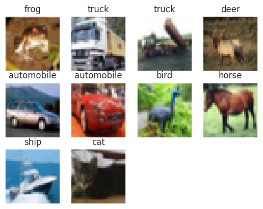

```python
imshow(X_tensor[0:10], label = classes[y[0:10].values].flatten().tolist(), is_int = False)
```

We observe:

- The objects in question such as `frog` and `deer`, do have some sort of background
- Visually, although the images are **quite blurry** due to the image size being `32x32`, it is still easy to tell the diffference between the classes.

What about the **average of all images**?

```
(<Figure size 640x480 with 1 Axes>,
 <AxesSubplot: title={'center': 'Average of all'}>)
```

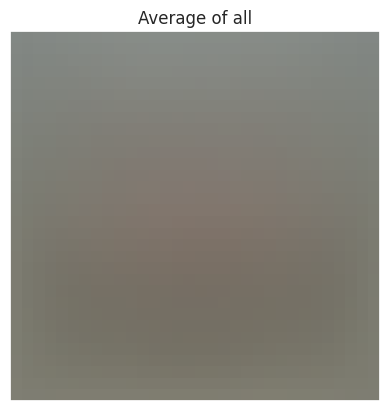

```python
imshow([
	X.mean().apply(lambda x: x).values.reshape(3, 32, 32)
], ['Average of all'])
```

We observe that there is no significance in the average of all images.

**Average image among the classes**  
We then split by the classes and find the average among each of the classes.

```
(<Figure size 1700x1000 with 10 Axes>,
 <AxesSubplot: title={'center': 'truck'}>)
```

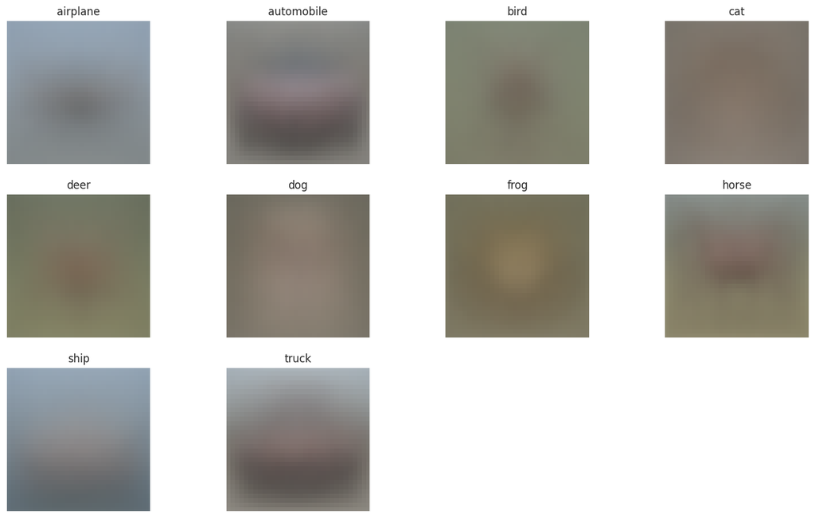

```python
images = []
titles = []

for i in range(10):
	idx = np.where((y.values == i))[0].flatten()
	images.append(X.iloc[idx].values.reshape(-1, 3, 32, 32).mean(axis=0))
	titles.append(classes[i])

imshow(images, titles, figsize = (17, 10))
```

We observe:

- We manage to *slightly* make out the shape of the `horse`
- It appears that the average `horse` seems to have a more dominant precence when it faces the left, which is quite an interesting note.
- For most of the classes, we manage to make out some sort of contour in the center, however it still is pixelated and blurry.

### Application and Evaluation of GAN Models

In this section, we attempt to make and apply our GAN models to tackle the CIFAR10 dataset. Additionally, for each model we try, we will also have a set of evaluation metrics and will analyze the outputs to gain a better understand of our progress.

The modeling process will go as such:

1. Explain the thought process and theory of GAN architecture
2. Train the GAN
3. Assess the progress
4. Evaluate on a series of metrics

#### Defining **Components**

In the next few sections, we define all the working parts that enables us to train and experiment with GANs smoothly. As this code is both length and convoluted, here is a list to skip the code definitions part.

- Skip to Model Application
- Skip to Model Evaluation

Defining **`Helper Functions`**

```python
# ====================================================
# |   Major credits to StudioGAN for code reference  |
# ====================================================

def set_deterministic_op_trainable(m):
	if isinstance(m, torch.nn.modules.conv.Conv2d):
		m.train()
	if isinstance(m, torch.nn.modules.conv.ConvTranspose2d):
		m.train()
	if isinstance(m, torch.nn.modules.linear.Linear):
		m.train()
	if isinstance(m, torch.nn.modules.Embedding):
		m.train()

def untrack_bn_statistics(m):
	if isinstance(m, torch.nn.modules.batchnorm._BatchNorm):
		m.track_running_stats = False

def track_bn_statistics(m):
	if isinstance(m, torch.nn.modules.batchnorm._BatchNorm):
		m.track_running_stats = True

class dummy_context_mgr():
	def __enter__(self):
		return None

	def __exit__(self, exc_type, exc_value, traceback):
		return False

def sample_y(y_sampler, batch_size, num_classes, device):
	if y_sampler == "totally_random":
		y_fake = torch.randint(low=0, high=num_classes, size=(batch_size, ), dtype=torch.long, device=device)

	elif y_sampler == "acending_some":
		assert batch_size % 8 == 0, "The size of batches should be a multiple of 8."
		num_classes_plot = batch_size // 8
		indices = np.random.permutation(num_classes)[:num_classes_plot]

	elif y_sampler == "acending_all":
		batch_size = num_classes * 8
		indices = [c for c in range(num_classes)]

	elif isinstance(y_sampler, int):
		y_fake = torch.tensor([y_sampler] * batch_size, dtype=torch.long).to(device)
	else:
		y_fake = None

	if y_sampler in ["acending_some", "acending_all"]:
		y_fake = []
		for idx in indices:
			y_fake += [idx] * 8
		y_fake = torch.tensor(y_fake, dtype=torch.long).to(device)
	return y_fake

from scipy.stats import truncnorm

def truncated_normal(size, threshold=1.):
	values = truncnorm.rvs(-threshold, threshold, size=size)
	return values

def sample_normal(batch_size, z_dim, truncation_factor, device):
	if truncation_factor == -1.0:
		latents = torch.randn(batch_size, z_dim, device=device)
	elif truncation_factor > 0:
		latents = torch.FloatTensor(truncated_normal([batch_size, z_dim], truncation_factor)).to(device)
	else:
		raise ValueError("truncated_factor must be positive.")
	return latents

def sample_zy(z_prior, batch_size, z_dim, num_classes, truncation_factor, y_sampler, radius, device, random_gen = None):
	fake_labels = sample_y(y_sampler=y_sampler, batch_size=batch_size, num_classes=num_classes, device=device)
	batch_size = fake_labels.shape[0]

	if z_prior == "gaussian":
		zs = sample_normal(batch_size=batch_size, z_dim=z_dim, truncation_factor=truncation_factor, device=device)
	elif z_prior == "uniform":
		zs = torch.FloatTensor(batch_size, z_dim).uniform_(-1.0, 1.0).to(device)
	elif z_prior == "fixed":
		assert random_gen != None, "generator must not be none"
		saved_state = random_gen.get_state()
		zs = torch.randn(batch_size, z_dim, device=device, generator=random_gen)
		random_gen.set_state(saved_state)
	elif z_prior == "interpolate":
		zs = torch.randn(z_dim, device = device).repeat(batch_size).reshape(batch_size, z_dim)
		zs[:, int(np.random.random() * z_dim)] = torch.linspace(-5, 5, steps = 8).repeat(int(batch_size / 8))
	else:
		raise NotImplementedError

	if isinstance(radius, float) and radius > 0.0:
		if z_prior == "gaussian":
			zs_eps = zs + radius * sample_normal(batch_size, z_dim, -1.0, device)
		elif z_prior == "uniform":
			zs_eps = zs + radius * torch.FloatTensor(batch_size, z_dim).uniform_(-1.0, 1.0).to(device)
	else:
		zs_eps = None

	return zs, fake_labels, zs_eps


def make_GAN_trainable(Gen, Gen_ema, Dis):
	Gen.train()
	Gen.apply(track_bn_statistics)
	if Gen_ema is not None:
		Gen_ema.train()
		Gen_ema.apply(track_bn_statistics)

	Dis.train()
	Dis.apply(track_bn_statistics)

def peel_model(model):
	if isinstance(model, nn.DataParallel):
		model = model.module
	return model

def toggle_grad(model, grad, num_freeze_layers=-1, is_stylegan=False):
	model = peel_model(model)
	if is_stylegan:
		for name, param in model.named_parameters():
			param.requires_grad = grad
	else:
		try:
			num_blocks = len(model.in_dims)
			assert num_freeze_layers < num_blocks,\
				"cannot freeze the {nfl}th block > total {nb} blocks.".format(nfl=num_freeze_layers,
																			nb=num_blocks)
		except:
			pass

		if num_freeze_layers == -1:
			for name, param in model.named_parameters():
				param.requires_grad = grad
		else:
			assert grad, "cannot freeze the model when grad is False"
			for name, param in model.named_parameters():
				param.requires_grad = True
				for layer in range(num_freeze_layers):
					block_name = "blocks.{layer}".format(layer=layer)
					if block_name in name:
						param.requires_grad = False

def calculate_all_sn(model, prefix):
    sigmas = {}
    with torch.no_grad():
        for name, param in model.named_parameters():
            operations = model
            if "weight_orig" in name:
                splited_name = name.split(".")
                for name_element in splited_name[:-1]:
                    operations = getattr(operations, name_element)
                weight_orig = reshape_weight_to_matrix(operations.weight_orig)
                weight_u = operations.weight_u
                weight_v = operations.weight_v
                sigmas[prefix + "_" + name] = torch.dot(weight_u, torch.mv(weight_orig, weight_v)).item()
    return sigmas

def cal_deriv(inputs, outputs, device):
	grads = autograd.grad(outputs=outputs,
						  inputs=inputs,
						  grad_outputs=torch.ones(outputs.size()).to(device),
						  create_graph=True,
						  retain_graph=True,
						  only_inputs=True)[0]
	return grads

def cal_r1_reg(adv_output, images, device):
	batch_size = images.size(0)
	grad_dout = cal_deriv(inputs=images, outputs=adv_output.sum(), device=device)
	grad_dout2 = grad_dout.pow(2)
	assert (grad_dout2.size() == images.size())
	r1_reg = 0.5 * grad_dout2.contiguous().view(batch_size, -1).sum(1).mean(0) + images[:,0,0,0].mean()*0
	return r1_reg

def cal_maxgrad_penalty(real_images, real_labels, fake_images, discriminator, device):
	batch_size, c, h, w = real_images.shape
	alpha = torch.rand(batch_size, 1)
	alpha = alpha.expand(batch_size, real_images.nelement() // batch_size).contiguous().view(batch_size, c, h, w)
	alpha = alpha.to(device)

	real_images = real_images.to(device)
	interpolates = alpha * real_images + ((1 - alpha) * fake_images)
	interpolates = interpolates.to(device)
	interpolates = autograd.Variable(interpolates, requires_grad=True)
	fake_dict = discriminator(interpolates, real_labels, eval=False)
	grads = cal_deriv(inputs=interpolates, outputs=fake_dict["adv_output"], device=device)
	grads = grads.view(grads.size(0), -1)

	maxgrad_penalty = torch.max(grads.norm(2, dim=1)**2) + interpolates[:,0,0,0].mean()*0
	return maxgrad_penalty

def generate_images(z_prior, truncation_factor, batch_size, z_dim, num_classes, y_sampler, radius, generator, discriminator,
					is_train, LOSS, RUN, MODEL, device, is_stylegan, cal_trsp_cost, random_gen = None):
	if is_train:
		truncation_factor = -1.0
		lo_steps = LOSS.lo_steps4train
		apply_langevin = False
	else:
		lo_steps = LOSS.lo_steps4eval
		if truncation_factor != -1:
			if is_stylegan:
				assert 0 <= truncation_factor <= 1, "Stylegan truncation_factor must lie btw 0(strong truncation) ~ 1(no truncation)"
			else:
				assert 0 <= truncation_factor, "truncation_factor must lie btw 0(strong truncation) ~ inf(no truncation)"

	zs, fake_labels, zs_eps = sample_zy(z_prior=z_prior,
										batch_size=batch_size,
										z_dim=z_dim,
										num_classes=num_classes,
										truncation_factor=-1 if is_stylegan else truncation_factor,
										y_sampler=y_sampler,
										radius=radius,
										device=device,
										random_gen = random_gen)
	batch_size = fake_labels.shape[0]
	info_discrete_c, info_conti_c = None, None
	if MODEL.info_type in ["discrete", "both"]:
		info_discrete_c = torch.randint(MODEL.info_dim_discrete_c,(batch_size, MODEL.info_num_discrete_c), device=device)
		zs = torch.cat((zs, F.one_hot(info_discrete_c, MODEL.info_dim_discrete_c).view(batch_size, -1)), dim=1)
	if MODEL.info_type in ["continuous", "both"]:
		info_conti_c = torch.rand(batch_size, MODEL.info_num_conti_c, device=device) * 2 - 1
		zs = torch.cat((zs, info_conti_c), dim=1)

	trsp_cost = None
	fake_images = generator(zs, fake_labels, eval=not is_train)
	ws = None

	if zs_eps is not None:
		fake_images_eps = generator(zs_eps, fake_labels, eval=not is_train)
	else:
		fake_images_eps = None
	return fake_images, fake_labels, fake_images_eps, trsp_cost, ws, info_discrete_c, info_conti_c

# Exponential Moving Average
class Ema(object):
    def __init__(self, source, target, decay=0.9999, start_iter=0):
        self.source = source
        self.target = target
        self.decay = decay
        self.start_iter = start_iter
        self.source_dict = self.source.state_dict()
        self.target_dict = self.target.state_dict()
        print("Initialize the copied generator's parameters to be source parameters.")
        with torch.no_grad():
            for p_ema, p in zip(self.target.parameters(), self.source.parameters()):
                p_ema.copy_(p)
            for b_ema, b in zip(self.target.buffers(), self.source.buffers()):
                b_ema.copy_(b)

    def update(self, iter=None):
        if iter >= 0 and iter < self.start_iter:
            decay = 0.0
        else:
            decay = self.decay

        with torch.no_grad():
            for p_ema, p in zip(self.target.parameters(), self.source.parameters()):
                p_ema.copy_(p.lerp(p_ema, decay))
            for (b_ema_name, b_ema), (b_name, b) in zip(self.target.named_buffers(), self.source.named_buffers()):
                if "num_batches_tracked" in b_ema_name:
                    b_ema.copy_(b)
                else:
                    b_ema.copy_(b.lerp(b_ema, decay))

def load_generator_discriminator(DATA, OPTIMIZATION, MODEL, STYLEGAN, MODULES, RUN, device, logger, Generator, Discriminator):
	# if device == 0:
	# 	logger.info("Build a Generative Adversarial Network.")
	# module = __import__("models.{backbone}".format(backbone=MODEL.backbone), fromlist=["something"])
	# if device == 0:
	# 	logger.info("Modules are located on './src/models.{backbone}'.".format(backbone=MODEL.backbone))

	Gen = Generator(z_dim=MODEL.z_dim,
							g_shared_dim=MODEL.g_shared_dim,
							img_size=DATA.img_size,
							g_conv_dim=MODEL.g_conv_dim,
							apply_attn=MODEL.apply_attn,
							attn_g_loc=MODEL.attn_g_loc,
							g_cond_mtd=MODEL.g_cond_mtd,
							num_classes=DATA.num_classes,
							g_init=MODEL.g_init,
							g_depth=MODEL.g_depth,
							MODULES=MODULES,
							MODEL=MODEL).to(device)

	Dis = Discriminator(img_size=DATA.img_size,
								d_conv_dim=MODEL.d_conv_dim,
								apply_d_sn=MODEL.apply_d_sn,
								apply_attn=MODEL.apply_attn,
								attn_d_loc=MODEL.attn_d_loc,
								d_cond_mtd=MODEL.d_cond_mtd,
								aux_cls_type=MODEL.aux_cls_type,
								d_embed_dim=MODEL.d_embed_dim,
								num_classes=DATA.num_classes,
								normalize_d_embed=MODEL.normalize_d_embed,
								d_init=MODEL.d_init,
								d_depth=MODEL.d_depth,
								MODULES=MODULES,
								MODEL=MODEL).to(device)
	if MODEL.apply_g_ema:
		# if device == 0:
		# 	logger.info("Prepare exponential moving average generator with decay rate of {decay}."\
		# 				.format(decay=MODEL.g_ema_decay))
		Gen_ema = copy.deepcopy(Gen)

		ema = Ema(source=Gen, target=Gen_ema, decay=MODEL.g_ema_decay, start_iter=MODEL.g_ema_start)
	else:
		Gen_ema, ema = None, None

	return Gen, Dis, Gen_ema, ema

preprop = transforms.Compose([
	transforms.ToTensor(),
	transforms.Lambda(lambda x: x * 2 - 1)
])
eval_set = torchvision.datasets.CIFAR10(root='./data', train=True,
										download=True, transform=preprop)

eval_dataloader = torch.utils.data.DataLoader(eval_set, batch_size=64, drop_last=False)
```

##### Defining **`Loss Functions`**

```python
class CrossEntropyLoss(torch.nn.Module):
	def __init__(self):
		super(CrossEntropyLoss, self).__init__()
		self.ce_loss = torch.nn.CrossEntropyLoss()

	def forward(self, cls_output, label, **_):
		return self.ce_loss(cls_output, label).mean()

class Data2DataCrossEntropyLoss(torch.nn.Module):
	def __init__(self, num_classes, temperature, m_p, master_rank, DDP):
		super(Data2DataCrossEntropyLoss, self).__init__()
		self.num_classes = num_classes
		self.temperature = temperature
		self.m_p = m_p
		self.master_rank = master_rank
		self.DDP = DDP
		self.calculate_similarity_matrix = self._calculate_similarity_matrix()
		self.cosine_similarity = torch.nn.CosineSimilarity(dim=-1)

	def _calculate_similarity_matrix(self):
		return self._cosine_simililarity_matrix

	def _cosine_simililarity_matrix(self, x, y):
		v = self.cosine_similarity(x.unsqueeze(1), y.unsqueeze(0))
		return v

	def make_index_matrix(self, labels):
		labels = labels.detach().cpu().numpy()
		num_samples = labels.shape[0]
		mask_multi, target = np.ones([self.num_classes, num_samples]), 0.0

		for c in range(self.num_classes):
			c_indices = np.where(labels==c)
			mask_multi[c, c_indices] = target
		return torch.tensor(mask_multi).type(torch.long).to(self.master_rank)

	def remove_diag(self, M):
		h, w = M.shape
		assert h==w, "h and w should be same"
		mask = np.ones((h, w)) - np.eye(h)
		mask = torch.from_numpy(mask)
		mask = (mask).type(torch.bool).to(self.master_rank)
		return M[mask].view(h, -1)

	def forward(self, embed, proxy, label, **_):
		# calculate similarities between sample embeddings
		sim_matrix = self.calculate_similarity_matrix(embed, embed) + self.m_p - 1
		# remove diagonal terms
		sim_matrix = self.remove_diag(sim_matrix/self.temperature)
		# for numerical stability
		sim_max, _ = torch.max(sim_matrix, dim=1, keepdim=True)
		sim_matrix = F.relu(sim_matrix) - sim_max.detach()

		# calculate similarities between sample embeddings and the corresponding proxies
		smp2proxy = self.cosine_similarity(embed, proxy)
		# make false negative removal
		removal_fn = self.remove_diag(self.make_index_matrix(label)[label])
		# apply the negative removal to the similarity matrix
		improved_sim_matrix = removal_fn*torch.exp(sim_matrix)

		# compute positive attraction term
		pos_attr = F.relu((self.m_p - smp2proxy)/self.temperature)
		# compute negative repulsion term
		neg_repul = torch.log(torch.exp(-pos_attr) + improved_sim_matrix.sum(dim=1))
		# compute data to data cross-entropy criterion
		criterion = pos_attr + neg_repul
		return criterion.mean()

def enable_allreduce(dict_):
	loss = 0
	for key, value in dict_.items():
		if value is not None and key != "label":
			loss += value.mean()*0
	return loss


def d_vanilla(d_logit_real, d_logit_fake, DDP):
	d_loss = torch.mean(F.softplus(-d_logit_real)) + torch.mean(F.softplus(d_logit_fake))
	return d_loss


def g_vanilla(d_logit_fake, DDP):
	return torch.mean(F.softplus(-d_logit_fake))


def d_logistic(d_logit_real, d_logit_fake, DDP):
	d_loss = F.softplus(-d_logit_real) + F.softplus(d_logit_fake)
	return d_loss.mean()


def g_logistic(d_logit_fake, DDP):
	# basically same as g_vanilla.
	return F.softplus(-d_logit_fake).mean()


def d_ls(d_logit_real, d_logit_fake, DDP):
	d_loss = 0.5 * (d_logit_real - torch.ones_like(d_logit_real))**2 + 0.5 * (d_logit_fake)**2
	return d_loss.mean()


def g_ls(d_logit_fake, DDP):
	gen_loss = 0.5 * (d_logit_fake - torch.ones_like(d_logit_fake))**2
	return gen_loss.mean()


def d_hinge(d_logit_real, d_logit_fake, DDP):
	return torch.mean(F.relu(1. - d_logit_real)) + torch.mean(F.relu(1. + d_logit_fake))


def g_hinge(d_logit_fake, DDP):
	return -torch.mean(d_logit_fake)


def d_wasserstein(d_logit_real, d_logit_fake, DDP):
	return torch.mean(d_logit_fake - d_logit_real)


def g_wasserstein(d_logit_fake, DDP):
	return -torch.mean(d_logit_fake)


def crammer_singer_loss(adv_output, label, DDP, **_):
	# https://github.com/ilyakava/BigGAN-PyTorch/blob/master/train_fns.py
	# crammer singer criterion
	num_real_classes = adv_output.shape[1] - 1
	mask = torch.ones_like(adv_output).to(adv_output.device)
	mask.scatter_(1, label.unsqueeze(-1), 0)
	wrongs = torch.masked_select(adv_output, mask.bool()).reshape(adv_output.shape[0], num_real_classes)
	max_wrong, _ = wrongs.max(1)
	max_wrong = max_wrong.unsqueeze(-1)
	target = adv_output.gather(1, label.unsqueeze(-1))
	return torch.mean(F.relu(1 + max_wrong - target))


def feature_matching_loss(real_embed, fake_embed):
	# https://github.com/ilyakava/BigGAN-PyTorch/blob/master/train_fns.py
	# feature matching criterion
	fm_loss = torch.mean(torch.abs(torch.mean(fake_embed, 0) - torch.mean(real_embed, 0)))
	return fm_loss


def lecam_reg(d_logit_real, d_logit_fake, ema):
	reg = torch.mean(F.relu(d_logit_real - ema.D_fake).pow(2)) + \
		  torch.mean(F.relu(ema.D_real - d_logit_fake).pow(2))
	return reg


def cal_deriv(inputs, outputs, device):
	grads = autograd.grad(outputs=outputs,
						  inputs=inputs,
						  grad_outputs=torch.ones(outputs.size()).to(device),
						  create_graph=True,
						  retain_graph=True,
						  only_inputs=True)[0]
	return grads


def latent_optimise(zs, fake_labels, generator, discriminator, batch_size, lo_rate, lo_steps, lo_alpha, lo_beta, eval,
					cal_trsp_cost, device):
	for step in range(lo_steps - 1):
		drop_mask = (torch.FloatTensor(batch_size, 1).uniform_() > 1 - lo_rate).to(device)

		zs = autograd.Variable(zs, requires_grad=True)
		fake_images = generator(zs, fake_labels, eval=eval)
		fake_dict = discriminator(fake_images, fake_labels, eval=eval)
		z_grads = cal_deriv(inputs=zs, outputs=fake_dict["adv_output"], device=device)
		z_grads_norm = torch.unsqueeze((z_grads.norm(2, dim=1)**2), dim=1)
		delta_z = lo_alpha * z_grads / (lo_beta + z_grads_norm)
		zs = torch.clamp(zs + drop_mask * delta_z, -1.0, 1.0)

		if cal_trsp_cost:
			if step == 0:
				trsf_cost = (delta_z.norm(2, dim=1)**2).mean()
			else:
				trsf_cost += (delta_z.norm(2, dim=1)**2).mean()
		else:
			trsf_cost = None
		return zs, trsf_cost


def cal_grad_penalty(real_images, real_labels, fake_images, discriminator, device):
	batch_size, c, h, w = real_images.shape
	alpha = torch.rand(batch_size, 1)
	alpha = alpha.expand(batch_size, real_images.nelement() // batch_size).contiguous().view(batch_size, c, h, w)
	alpha = alpha.to(device)

	real_images = real_images.to(device)
	interpolates = alpha * real_images + ((1 - alpha) * fake_images)
	interpolates = interpolates.to(device)
	interpolates = autograd.Variable(interpolates, requires_grad=True)
	fake_dict = discriminator(interpolates, real_labels, eval=False)
	grads = cal_deriv(inputs=interpolates, outputs=fake_dict["adv_output"], device=device)
	grads = grads.view(grads.size(0), -1)

	grad_penalty = ((grads.norm(2, dim=1) - 1)**2).mean() + interpolates[:,0,0,0].mean()*0
	return grad_penalty


def cal_dra_penalty(real_images, real_labels, discriminator, device):
	batch_size, c, h, w = real_images.shape
	alpha = torch.rand(batch_size, 1, 1, 1)
	alpha = alpha.to(device)

	real_images = real_images.to(device)
	differences = 0.5 * real_images.std() * torch.rand(real_images.size()).to(device)
	interpolates = real_images + (alpha * differences)
	interpolates = interpolates.to(device)
	interpolates = autograd.Variable(interpolates, requires_grad=True)
	fake_dict = discriminator(interpolates, real_labels, eval=False)
	grads = cal_deriv(inputs=interpolates, outputs=fake_dict["adv_output"], device=device)
	grads = grads.view(grads.size(0), -1)

	grad_penalty = ((grads.norm(2, dim=1) - 1)**2).mean() + interpolates[:,0,0,0].mean()*0
	return grad_penalty


def cal_maxgrad_penalty(real_images, real_labels, fake_images, discriminator, device):
	batch_size, c, h, w = real_images.shape
	alpha = torch.rand(batch_size, 1)
	alpha = alpha.expand(batch_size, real_images.nelement() // batch_size).contiguous().view(batch_size, c, h, w)
	alpha = alpha.to(device)

	real_images = real_images.to(device)
	interpolates = alpha * real_images + ((1 - alpha) * fake_images)
	interpolates = interpolates.to(device)
	interpolates = autograd.Variable(interpolates, requires_grad=True)
	fake_dict = discriminator(interpolates, real_labels, eval=False)
	grads = cal_deriv(inputs=interpolates, outputs=fake_dict["adv_output"], device=device)
	grads = grads.view(grads.size(0), -1)

	maxgrad_penalty = torch.max(grads.norm(2, dim=1)**2) + interpolates[:,0,0,0].mean()*0
	return maxgrad_penalty


def cal_r1_reg(adv_output, images, device):
	batch_size = images.size(0)
	grad_dout = cal_deriv(inputs=images, outputs=adv_output.sum(), device=device)
	grad_dout2 = grad_dout.pow(2)
	assert (grad_dout2.size() == images.size())
	r1_reg = 0.5 * grad_dout2.contiguous().view(batch_size, -1).sum(1).mean(0) + images[:,0,0,0].mean()*0
	return r1_reg


def adjust_k(current_k, topk_gamma, inf_k):
	current_k = max(current_k * topk_gamma, inf_k)
	return current_k


def normal_nll_loss(x, mu, var):
	# https://github.com/Natsu6767/InfoGAN-PyTorch/blob/master/utils.py
	# Calculate the negative log likelihood of normal distribution.
	# Needs to be minimized in InfoGAN. (Treats Q(c]x) as a factored Gaussian)
	logli = -0.5 * (var.mul(2 * np.pi) + 1e-6).log() - (x - mu).pow(2).div(var.mul(2.0) + 1e-6)
	nll = -(logli.sum(1).mean())
	return nll
```

##### Defining **`DiffAugment`**

```python
"""
Copyright (c) 2020, Shengyu Zhao, Zhijian Liu, Ji Lin, Jun-Yan Zhu, and Song Han
All rights reserved.

Redistribution and use in source and binary forms, with or without
modification, are permitted provided that the following conditions are met:

* Redistributions of source code must retain the above copyright notice, this
  list of conditions and the following disclaimer.

* Redistributions in binary form must reproduce the above copyright notice,
  this list of conditions and the following disclaimer in the documentation
  and/or other materials provided with the distribution.

THIS SOFTWARE IS PROVIDED BY THE COPYRIGHT HOLDERS AND CONTRIBUTORS "AS IS"
AND ANY EXPRESS OR IMPLIED WARRANTIES, INCLUDING, BUT NOT LIMITED TO, THE
IMPLIED WARRANTIES OF MERCHANTABILITY AND FITNESS FOR A PARTICULAR PURPOSE ARE
DISCLAIMED. IN NO EVENT SHALL THE COPYRIGHT HOLDER OR CONTRIBUTORS BE LIABLE
FOR ANY DIRECT, INDIRECT, INCIDENTAL, SPECIAL, EXEMPLARY, OR CONSEQUENTIAL
DAMAGES (INCLUDING, BUT NOT LIMITED TO, PROCUREMENT OF SUBSTITUTE GOODS OR
SERVICES; LOSS OF USE, DATA, OR PROFITS; OR BUSINESS INTERRUPTION) HOWEVER
CAUSED AND ON ANY THEORY OF LIABILITY, WHETHER IN CONTRACT, STRICT LIABILITY,
OR TORT (INCLUDING NEGLIGENCE OR OTHERWISE) ARISING IN ANY WAY OUT OF THE USE
OF THIS SOFTWARE, EVEN IF ADVISED OF THE POSSIBILITY OF SUCH DAMAGE.
"""

### Differentiable Augmentation for Data-Efficient GAN Training (https://arxiv.org/abs/2006.10738)
### Shengyu Zhao, Zhijian Liu, Ji Lin, Jun-Yan Zhu, and Song Han
### https://github.com/mit-han-lab/data-efficient-gans

def apply_diffaug(x, policy="color,translation,cutout", channels_first=True):
    if policy:
        if not channels_first:
            x = x.permute(0, 3, 1, 2)
        for p in policy.split(","):
            for f in AUGMENT_FNS[p]:
                x = f(x)
        if not channels_first:
            x = x.permute(0, 2, 3, 1)
        x = x.contiguous()
    return x


def rand_brightness(x):
    x = x + (torch.rand(x.size(0), 1, 1, 1, dtype=x.dtype, device=x.device) - 0.5)
    return x


def rand_saturation(x):
    x_mean = x.mean(dim=1, keepdim=True)
    x = (x - x_mean) * (torch.rand(x.size(0), 1, 1, 1, dtype=x.dtype, device=x.device) * 2) + x_mean
    return x


def rand_contrast(x):
    x_mean = x.mean(dim=[1, 2, 3], keepdim=True)
    x = (x - x_mean) * (torch.rand(x.size(0), 1, 1, 1, dtype=x.dtype, device=x.device) + 0.5) + x_mean
    return x


def rand_translation(x, ratio=0.125):
    shift_x, shift_y = int(x.size(2) * ratio + 0.5), int(x.size(3) * ratio + 0.5)
    translation_x = torch.randint(-shift_x, shift_x + 1, size=[x.size(0), 1, 1], device=x.device)
    translation_y = torch.randint(-shift_y, shift_y + 1, size=[x.size(0), 1, 1], device=x.device)
    grid_batch, grid_x, grid_y = torch.meshgrid(
        torch.arange(x.size(0), dtype=torch.long, device=x.device),
        torch.arange(x.size(2), dtype=torch.long, device=x.device),
        torch.arange(x.size(3), dtype=torch.long, device=x.device),
    )
    grid_x = torch.clamp(grid_x + translation_x + 1, 0, x.size(2) + 1)
    grid_y = torch.clamp(grid_y + translation_y + 1, 0, x.size(3) + 1)
    x_pad = F.pad(x, [1, 1, 1, 1, 0, 0, 0, 0])
    x = x_pad.permute(0, 2, 3, 1).contiguous()[grid_batch, grid_x, grid_y].permute(0, 3, 1, 2)
    return x


def rand_cutout(x, ratio=0.5):
    cutout_size = int(x.size(2) * ratio + 0.5), int(x.size(3) * ratio + 0.5)
    offset_x = torch.randint(0, x.size(2) + (1 - cutout_size[0] % 2), size=[x.size(0), 1, 1], device=x.device)
    offset_y = torch.randint(0, x.size(3) + (1 - cutout_size[1] % 2), size=[x.size(0), 1, 1], device=x.device)
    grid_batch, grid_x, grid_y = torch.meshgrid(
        torch.arange(x.size(0), dtype=torch.long, device=x.device),
        torch.arange(cutout_size[0], dtype=torch.long, device=x.device),
        torch.arange(cutout_size[1], dtype=torch.long, device=x.device),
    )
    grid_x = torch.clamp(grid_x + offset_x - cutout_size[0] // 2, min=0, max=x.size(2) - 1)
    grid_y = torch.clamp(grid_y + offset_y - cutout_size[1] // 2, min=0, max=x.size(3) - 1)
    mask = torch.ones(x.size(0), x.size(2), x.size(3), dtype=x.dtype, device=x.device)
    mask[grid_batch, grid_x, grid_y] = 0
    x = x * mask.unsqueeze(1)
    return x


AUGMENT_FNS = {
    "color": [rand_brightness, rand_saturation, rand_contrast],
    "translation": [rand_translation],
    "cutout": [rand_cutout],
}
```

##### Defining **`Network Components`**

```python
from torch.nn.utils import spectral_norm

class empty_object(object):
	pass

class ConditionalBatchNorm2d(nn.Module):
    # https://github.com/voletiv/self-attention-GAN-pytorch
    def __init__(self, in_features, out_features, MODULES):
        super().__init__()
        self.in_features = in_features
        self.bn = batchnorm_2d(out_features, eps=1e-4, momentum=0.1, affine=False)

        self.gain = MODULES.g_linear(in_features=in_features, out_features=out_features, bias=False)
        self.bias = MODULES.g_linear(in_features=in_features, out_features=out_features, bias=False)

    def forward(self, x, y):
        gain = (1 + self.gain(y)).view(y.size(0), -1, 1, 1)
        bias = self.bias(y).view(y.size(0), -1, 1, 1)
        out = self.bn(x)
        return out * gain + bias

class SelfAttention(nn.Module):
    """
    https://github.com/voletiv/self-attention-GAN-pytorch
    MIT License
    Copyright (c) 2019 Vikram Voleti
    Permission is hereby granted, free of charge, to any person obtaining a copy
    of this software and associated documentation files (the "Software"), to deal
    in the Software without restriction, including without limitation the rights
    to use, copy, modify, merge, publish, distribute, sublicense, and/or sell
    copies of the Software, and to permit persons to whom the Software is
    furnished to do so, subject to the following conditions:
    The above copyright notice and this permission notice shall be included in all
    copies or substantial portions of the Software.
    THE SOFTWARE IS PROVIDED "AS IS", WITHOUT WARRANTY OF ANY KIND, EXPRESS OR
    IMPLIED, INCLUDING BUT NOT LIMITED TO THE WARRANTIES OF MERCHANTABILITY,
    FITNESS FOR A PARTICULAR PURPOSE AND NONINFRINGEMENT. IN NO EVENT SHALL THE
    AUTHORS OR COPYRIGHT HOLDERS BE LIABLE FOR ANY CLAIM, DAMAGES OR OTHER
    LIABILITY, WHETHER IN AN ACTION OF CONTRACT, TORT OR OTHERWISE, ARISING FROM,
    OUT OF OR IN CONNECTION WITH THE SOFTWARE OR THE USE OR OTHER DEALINGS IN THE
    SOFTWARE.
    """
    def __init__(self, in_channels, is_generator, MODULES):
        super(SelfAttention, self).__init__()
        self.in_channels = in_channels

        if is_generator:
            self.conv1x1_theta = MODULES.g_conv2d(in_channels=in_channels, out_channels=in_channels // 8, kernel_size=1,
                                                  stride=1, padding=0, bias=False)
            self.conv1x1_phi = MODULES.g_conv2d(in_channels=in_channels, out_channels=in_channels // 8, kernel_size=1,
                                                stride=1, padding=0, bias=False)
            self.conv1x1_g = MODULES.g_conv2d(in_channels=in_channels, out_channels=in_channels // 2, kernel_size=1,
                                              stride=1, padding=0, bias=False)
            self.conv1x1_attn = MODULES.g_conv2d(in_channels=in_channels // 2, out_channels=in_channels, kernel_size=1,
                                                 stride=1, padding=0, bias=False)
        else:
            self.conv1x1_theta = MODULES.d_conv2d(in_channels=in_channels, out_channels=in_channels // 8, kernel_size=1,
                                                  stride=1, padding=0, bias=False)
            self.conv1x1_phi = MODULES.d_conv2d(in_channels=in_channels, out_channels=in_channels // 8, kernel_size=1,
                                                stride=1, padding=0, bias=False)
            self.conv1x1_g = MODULES.d_conv2d(in_channels=in_channels, out_channels=in_channels // 2, kernel_size=1,
                                              stride=1, padding=0, bias=False)
            self.conv1x1_attn = MODULES.d_conv2d(in_channels=in_channels // 2, out_channels=in_channels, kernel_size=1,
                                                 stride=1, padding=0, bias=False)

        self.maxpool = nn.MaxPool2d(2, stride=2, padding=0)
        self.softmax = nn.Softmax(dim=-1)
        self.sigma = nn.Parameter(torch.zeros(1), requires_grad=True)

    def forward(self, x):
        _, ch, h, w = x.size()
        # Theta path
        theta = self.conv1x1_theta(x)
        theta = theta.view(-1, ch // 8, h * w)
        # Phi path
        phi = self.conv1x1_phi(x)
        phi = self.maxpool(phi)
        phi = phi.view(-1, ch // 8, h * w // 4)
        # Attn map
        attn = torch.bmm(theta.permute(0, 2, 1), phi)
        attn = self.softmax(attn)
        # g path
        g = self.conv1x1_g(x)
        g = self.maxpool(g)
        g = g.view(-1, ch // 2, h * w // 4)
        # Attn_g
        attn_g = torch.bmm(g, attn.permute(0, 2, 1))
        attn_g = attn_g.view(-1, ch // 2, h, w)
        attn_g = self.conv1x1_attn(attn_g)
        return x + self.sigma * attn_g

def init_weights(modules, initialize):
    for module in modules():
        if (isinstance(module, nn.Conv2d) or isinstance(module, nn.ConvTranspose2d) or isinstance(module, nn.Linear)):
            if initialize == "ortho":
                init.orthogonal_(module.weight)
                if module.bias is not None:
                    module.bias.data.fill_(0.)
            elif initialize == "N02":
                init.normal_(module.weight, 0, 0.02)
                if module.bias is not None:
                    module.bias.data.fill_(0.)
            elif initialize in ["glorot", "xavier"]:
                init.xavier_uniform_(module.weight)
                if module.bias is not None:
                    module.bias.data.fill_(0.)
            else:
                pass
        elif isinstance(module, nn.Embedding):
            if initialize == "ortho":
                init.orthogonal_(module.weight)
            elif initialize == "N02":
                init.normal_(module.weight, 0, 0.02)
            elif initialize in ["glorot", "xavier"]:
                init.xavier_uniform_(module.weight)
            else:
                pass
        else:
            pass


def conv2d(in_channels, out_channels, kernel_size, stride=1, padding=0, dilation=1, groups=1, bias=True):
    return nn.Conv2d(in_channels=in_channels,
                     out_channels=out_channels,
                     kernel_size=kernel_size,
                     stride=stride,
                     padding=padding,
                     dilation=dilation,
                     groups=groups,
                     bias=bias)


def deconv2d(in_channels, out_channels, kernel_size, stride=2, padding=0, dilation=1, groups=1, bias=True):
    return nn.ConvTranspose2d(in_channels=in_channels,
                              out_channels=out_channels,
                              kernel_size=kernel_size,
                              stride=stride,
                              padding=padding,
                              dilation=dilation,
                              groups=groups,
                              bias=bias)


def linear(in_features, out_features, bias=True):
    return nn.Linear(in_features=in_features, out_features=out_features, bias=bias)


def embedding(num_embeddings, embedding_dim):
    return nn.Embedding(num_embeddings=num_embeddings, embedding_dim=embedding_dim)


def snconv2d(in_channels, out_channels, kernel_size, stride=1, padding=0, dilation=1, groups=1, bias=True):
    return spectral_norm(nn.Conv2d(in_channels=in_channels,
                                   out_channels=out_channels,
                                   kernel_size=kernel_size,
                                   stride=stride,
                                   padding=padding,
                                   dilation=dilation,
                                   groups=groups,
                                   bias=bias),
                         eps=1e-6)


def sndeconv2d(in_channels, out_channels, kernel_size, stride=2, padding=0, dilation=1, groups=1, bias=True):
    return spectral_norm(nn.ConvTranspose2d(in_channels=in_channels,
                                            out_channels=out_channels,
                                            kernel_size=kernel_size,
                                            stride=stride,
                                            padding=padding,
                                            dilation=dilation,
                                            groups=groups,
                                            bias=bias),
                         eps=1e-6)


def snlinear(in_features, out_features, bias=True):
    return spectral_norm(nn.Linear(in_features=in_features, out_features=out_features, bias=bias), eps=1e-6)


def sn_embedding(num_embeddings, embedding_dim):
    return spectral_norm(nn.Embedding(num_embeddings=num_embeddings, embedding_dim=embedding_dim), eps=1e-6)


def batchnorm_2d(in_features, eps=1e-4, momentum=0.1, affine=True):
    return nn.BatchNorm2d(in_features, eps=eps, momentum=momentum, affine=affine, track_running_stats=True)


def conv3x3(in_planes, out_planes, stride=1):
    "3x3 convolution with padding"
    return nn.Conv2d(in_planes, out_planes, kernel_size=3, stride=stride,
                     padding=1, bias=False)


def adjust_learning_rate(optimizer, lr_org, epoch, total_epoch, dataset):
    """Sets the learning rate to the initial LR decayed by 10 every 30 epochs"""
    if dataset in ["CIFAR10", "CIFAR100"]:
        lr = lr_org * (0.1 ** (epoch // (total_epoch * 0.5))) * (0.1 ** (epoch // (total_epoch * 0.75)))
    elif dataset in ["Tiny_ImageNet", "ImageNet"]:
        if total_epoch == 300:
            lr = lr_org * (0.1 ** (epoch // 75))
        else:
            lr = lr_org * (0.1 ** (epoch // 30))

    for param_group in optimizer.param_groups:
        param_group['lr'] = lr

def quantize_images(x):
    x = (x + 1)/2
    x = (255.0*x + 0.5).clamp(0.0, 255.0)
    x = x.detach().cpu().numpy().astype(np.uint8)
    return x

def make_GAN_untrainable(Gen, Gen_ema, Dis):
    Gen.eval()
    Gen.apply(set_deterministic_op_trainable)
    if Gen_ema is not None:
        Gen_ema.eval()
        Gen_ema.apply(set_deterministic_op_trainable)

    Dis.eval()
    Dis.apply(set_deterministic_op_trainable)

def resize_images(x, resizer, ToTensor, mean, std, device):
    x = x.transpose((0, 2, 3, 1))
    x = list(map(lambda x: ToTensor(resizer(x)), list(x)))
    x = torch.stack(x, 0).to(device)
    x = (x/255.0 - mean)/std
    return x
```

##### Defining **`Pretrained Inception V3`**

```python
# Inception weights ported to Pytorch from
# http://download.tensorflow.org/models/image/imagenet/inception-2015-12-05.tgz
FID_WEIGHTS_URL = 'https://github.com/mseitzer/pytorch-fid/releases/download/fid_weights/pt_inception-2015-12-05-6726825d.pth'


class InceptionV3(nn.Module):
    """Pretrained InceptionV3 network returning feature maps"""

    # Index of default block of inception to return,
    # corresponds to output of final average pooling
    def __init__(self, resize_input=True, normalize_input=False, requires_grad=False):
        """Build pretrained InceptionV3
        Parameters
        ----------
        resize_input : bool
            If true, bilinearly resizes input to width and height 299 before
            feeding input to model. As the network without fully connected
            layers is fully convolutional, it should be able to handle inputs
            of arbitrary size, so resizing might not be strictly needed
        normalize_input : bool
            If true, scales the input from range (0, 1) to the range the
            pretrained Inception network expects, namely (-1, 1)
        requires_grad : bool
            If true, parameters of the model require gradients. Possibly useful
            for finetuning the network
        """
        super(InceptionV3, self).__init__()

        self.resize_input = resize_input
        self.normalize_input = normalize_input
        self.blocks = nn.ModuleList()

        state_dict, inception = fid_inception_v3()

        block0 = [
            inception.Conv2d_1a_3x3, inception.Conv2d_2a_3x3, inception.Conv2d_2b_3x3,
            nn.MaxPool2d(kernel_size=3, stride=2)
        ]
        self.blocks.append(nn.Sequential(*block0))

        block1 = [inception.Conv2d_3b_1x1, inception.Conv2d_4a_3x3, nn.MaxPool2d(kernel_size=3, stride=2)]
        self.blocks.append(nn.Sequential(*block1))

        block2 = [
            inception.Mixed_5b,
            inception.Mixed_5c,
            inception.Mixed_5d,
            inception.Mixed_6a,
            inception.Mixed_6b,
            inception.Mixed_6c,
            inception.Mixed_6d,
            inception.Mixed_6e,
        ]
        self.blocks.append(nn.Sequential(*block2))

        block3 = [inception.Mixed_7a, inception.Mixed_7b, inception.Mixed_7c, nn.AdaptiveAvgPool2d(output_size=(1, 1))]
        self.blocks.append(nn.Sequential(*block3))

        with torch.no_grad():
            self.fc = nn.Linear(2048, 1008, bias=True)
            self.fc.weight.copy_(state_dict['fc.weight'])
            self.fc.bias.copy_(state_dict['fc.bias'])

        for param in self.parameters():
            param.requires_grad = requires_grad

    def forward(self, inp):
        """Get Inception feature maps
        Parameters
        ----------
        inp : torch.autograd.Variable
            Input tensor of shape Bx3xHxW. Values are expected to be in
            range (0, 1)
        Returns
        -------
        List of torch.autograd.Variable, corresponding to the selected output
        block, sorted ascending by index
        """
        x = inp

        if self.resize_input:
            x = F.interpolate(x, size=(299, 299), mode='bilinear', align_corners=False)

        if self.normalize_input:
            x = 2 * x - 1  # Scale from range (0, 1) to range (-1, 1)

        for idx, block in enumerate(self.blocks):
            x = block(x)

        x = F.dropout(x, training=False)
        x = torch.flatten(x, 1)
        logit = self.fc(x)
        return x, logit


def fid_inception_v3():
    """Build pretrained Inception model for FID computation
    The Inception model for FID computation uses a different set of weights
    and has a slightly different structure than torchvision's Inception.
    This method first constructs torchvision's Inception and then patches the
    necessary parts that are different in the FID Inception model.
    """
    inception = models.inception_v3(num_classes=1008, aux_logits=False, pretrained=False)

    inception.Mixed_5b = FIDInceptionA(192, pool_features=32)
    inception.Mixed_5c = FIDInceptionA(256, pool_features=64)
    inception.Mixed_5d = FIDInceptionA(288, pool_features=64)
    inception.Mixed_6b = FIDInceptionC(768, channels_7x7=128)
    inception.Mixed_6c = FIDInceptionC(768, channels_7x7=160)
    inception.Mixed_6d = FIDInceptionC(768, channels_7x7=160)
    inception.Mixed_6e = FIDInceptionC(768, channels_7x7=192)
    inception.Mixed_7b = FIDInceptionE_1(1280)
    inception.Mixed_7c = FIDInceptionE_2(2048)
    # inception.fc = nn.Linear(2048, 1008, bias=False)

    state_dict = load_state_dict_from_url(FID_WEIGHTS_URL, progress=True)
    inception.load_state_dict(state_dict)
    return state_dict, inception


class FIDInceptionA(models.inception.InceptionA):
    """InceptionA block patched for FID computation"""
    def __init__(self, in_channels, pool_features):
        super(FIDInceptionA, self).__init__(in_channels, pool_features)

    def forward(self, x):
        branch1x1 = self.branch1x1(x)

        branch5x5 = self.branch5x5_1(x)
        branch5x5 = self.branch5x5_2(branch5x5)

        branch3x3dbl = self.branch3x3dbl_1(x)
        branch3x3dbl = self.branch3x3dbl_2(branch3x3dbl)
        branch3x3dbl = self.branch3x3dbl_3(branch3x3dbl)

        # Patch: Tensorflow's average pool does not use the padded zero's in
        # its average calculation
        branch_pool = F.avg_pool2d(x, kernel_size=3, stride=1, padding=1, count_include_pad=False)
        branch_pool = self.branch_pool(branch_pool)

        outputs = [branch1x1, branch5x5, branch3x3dbl, branch_pool]
        return torch.cat(outputs, 1)


class FIDInceptionC(models.inception.InceptionC):
    """InceptionC block patched for FID computation"""
    def __init__(self, in_channels, channels_7x7):
        super(FIDInceptionC, self).__init__(in_channels, channels_7x7)

    def forward(self, x):
        branch1x1 = self.branch1x1(x)

        branch7x7 = self.branch7x7_1(x)
        branch7x7 = self.branch7x7_2(branch7x7)
        branch7x7 = self.branch7x7_3(branch7x7)

        branch7x7dbl = self.branch7x7dbl_1(x)
        branch7x7dbl = self.branch7x7dbl_2(branch7x7dbl)
        branch7x7dbl = self.branch7x7dbl_3(branch7x7dbl)
        branch7x7dbl = self.branch7x7dbl_4(branch7x7dbl)
        branch7x7dbl = self.branch7x7dbl_5(branch7x7dbl)

        # Patch: Tensorflow's average pool does not use the padded zero's in
        # its average calculation
        branch_pool = F.avg_pool2d(x, kernel_size=3, stride=1, padding=1, count_include_pad=False)
        branch_pool = self.branch_pool(branch_pool)

        outputs = [branch1x1, branch7x7, branch7x7dbl, branch_pool]
        return torch.cat(outputs, 1)


class FIDInceptionE_1(models.inception.InceptionE):
    """First InceptionE block patched for FID computation"""
    def __init__(self, in_channels):
        super(FIDInceptionE_1, self).__init__(in_channels)

    def forward(self, x):
        branch1x1 = self.branch1x1(x)

        branch3x3 = self.branch3x3_1(x)
        branch3x3 = [
            self.branch3x3_2a(branch3x3),
            self.branch3x3_2b(branch3x3),
        ]
        branch3x3 = torch.cat(branch3x3, 1)

        branch3x3dbl = self.branch3x3dbl_1(x)
        branch3x3dbl = self.branch3x3dbl_2(branch3x3dbl)
        branch3x3dbl = [
            self.branch3x3dbl_3a(branch3x3dbl),
            self.branch3x3dbl_3b(branch3x3dbl),
        ]
        branch3x3dbl = torch.cat(branch3x3dbl, 1)

        # Patch: Tensorflow's average pool does not use the padded zero's in
        # its average calculation
        branch_pool = F.avg_pool2d(x, kernel_size=3, stride=1, padding=1, count_include_pad=False)
        branch_pool = self.branch_pool(branch_pool)

        outputs = [branch1x1, branch3x3, branch3x3dbl, branch_pool]
        return torch.cat(outputs, 1)


class FIDInceptionE_2(models.inception.InceptionE):
    """Second InceptionE block patched for FID computation"""
    def __init__(self, in_channels):
        super(FIDInceptionE_2, self).__init__(in_channels)

    def forward(self, x):
        branch1x1 = self.branch1x1(x)

        branch3x3 = self.branch3x3_1(x)
        branch3x3 = [
            self.branch3x3_2a(branch3x3),
            self.branch3x3_2b(branch3x3),
        ]
        branch3x3 = torch.cat(branch3x3, 1)

        branch3x3dbl = self.branch3x3dbl_1(x)
        branch3x3dbl = self.branch3x3dbl_2(branch3x3dbl)
        branch3x3dbl = [
            self.branch3x3dbl_3a(branch3x3dbl),
            self.branch3x3dbl_3b(branch3x3dbl),
        ]
        branch3x3dbl = torch.cat(branch3x3dbl, 1)

        branch_pool = F.max_pool2d(x, kernel_size=3, stride=1, padding=1)
        branch_pool = self.branch_pool(branch_pool)

        outputs = [branch1x1, branch3x3, branch3x3dbl, branch_pool]
        return torch.cat(outputs, 1)
```

##### Defining **Evaluation Data**

When assessing the performance of a GAN, it is **important** to use the **same quantity** of images for both the real and generated images. This is because the metrics used to evaluate the quality and diversity of the generated images, such as the Inception Score and the Frechet Inception Distance, are based on the comparison of the statistics of the real and generated images. The statistics are estimated from a sample of images, and the **sample size affects the precision and reliability** of the estimate.

However, due to computational restraints, it is not possible for one to load the total number of images into one tensor and simply compare them (in our case of CIFAR10, this would be 50000 images per tensor). Thus, we **instead load them into a data loader** where we assess the metrics on a **per-batch basis**.

```python
def generate_images_and_stack_features(generator, discriminator, eval_model, num_generate, y_sampler, batch_size, z_prior,
									   truncation_factor, z_dim, num_classes, LOSS, RUN, MODEL, quantize, logger, disable_tqdm):


	eval_model.eval()
	feature_holder, prob_holder, fake_label_holder = [], [], []

	num_batches = int(math.ceil(float(num_generate) / float(batch_size)))
	for i in tqdm(range(num_batches), disable=disable_tqdm):
		fake_images, fake_labels, _, _, _, _, _ = generate_images(z_prior=z_prior,
																   truncation_factor=truncation_factor,
																   batch_size=batch_size,
																   z_dim=z_dim,
																   num_classes=num_classes,
																   y_sampler=y_sampler,
																   radius="N/A",
																   generator=generator,
																   discriminator=discriminator,
																   is_train=False,
																   LOSS=LOSS,
																   RUN=RUN,
																   MODEL=MODEL,
																   device=torch.device('cuda'),
																   is_stylegan = False,
																   cal_trsp_cost=False)

		with torch.no_grad():
			features, logits = eval_model.get_outputs(fake_images, quantize=quantize)
			probs = torch.nn.functional.softmax(logits, dim=1)

		feature_holder.append(features)
		prob_holder.append(probs)
		fake_label_holder.append(fake_labels)

	feature_holder = torch.cat(feature_holder, 0)
	prob_holder = torch.cat(prob_holder, 0)
	fake_label_holder = torch.cat(fake_label_holder, 0)
	del fake_images
	del fake_labels
	torch.cuda.empty_cache()

	return feature_holder, prob_holder, list(fake_label_holder.detach().cpu().numpy())

# Adapted from https://github.com/eitanrich/gans-n-gmms/blob/master/utils/ndb.py
import os
import numpy as np
from sklearn.cluster import KMeans
from scipy.stats import norm
from matplotlib import pyplot as plt
import pickle as pkl

class NDB:
    def __init__(self, training_data=None, number_of_bins=100, significance_level=0.05, z_threshold=None,
                 whitening=False, max_dims=None, cache_folder=None):
        """
        NDB Evaluation Class
        :param training_data: Optional - the training samples - array of m x d floats (m samples of dimension d)
        :param number_of_bins: Number of bins (clusters) default=100
        :param significance_level: The statistical significance level for the two-sample test
        :param z_threshold: Allow defining a threshold in terms of difference/SE for defining a bin as statistically different
        :param whitening: Perform data whitening - subtract mean and divide by per-dimension std
        :param max_dims: Max dimensions to use in K-means. By default derived automatically from d
        :param bins_file: Optional - file to write / read-from the clusters (to avoid re-calculation)
        """
        self.number_of_bins = number_of_bins
        self.significance_level = significance_level
        self.z_threshold = z_threshold
        self.whitening = whitening
        self.ndb_eps = 1e-6
        self.training_mean = 0.0
        self.training_std = 1.0
        self.max_dims = max_dims
        self.cache_folder = cache_folder
        self.bin_centers = None
        self.bin_proportions = None
        self.ref_sample_size = None
        self.used_d_indices = None
        self.results_file = None
        self.test_name = 'ndb_{}_bins_{}'.format(self.number_of_bins, 'whiten' if self.whitening else 'orig')
        self.cached_results = {}
        if self.cache_folder:
            self.results_file = os.path.join(cache_folder, self.test_name+'_results.pkl')
            if os.path.isfile(self.results_file):
                # print('Loading previous results from', self.results_file, ':')
                self.cached_results = pkl.load(open(self.results_file, 'rb'))
                # print(self.cached_results.keys())
        if training_data is not None or cache_folder is not None:
                bins_file = None
                if cache_folder:
                    os.makedirs(cache_folder, exist_ok=True)
                    bins_file = os.path.join(cache_folder, self.test_name+'.pkl')
                self.construct_bins(training_data, bins_file)

    def construct_bins(self, training_samples, bins_file):
        """
        Performs K-means clustering of the training samples
        :param training_samples: An array of m x d floats (m samples of dimension d)
        """

        if self.__read_from_bins_file(bins_file):
            return
        n, d = training_samples.shape
        k = self.number_of_bins
        if self.whitening:
            self.training_mean = np.mean(training_samples, axis=0)
            self.training_std = np.std(training_samples, axis=0) + self.ndb_eps

        if self.max_dims is None and d > 1000:
            # To ran faster, perform binning on sampled data dimension (i.e. don't use all channels of all pixels)
            self.max_dims = d//6

        whitened_samples = (training_samples-self.training_mean)/self.training_std
        d_used = d if self.max_dims is None else min(d, self.max_dims)
        self.used_d_indices = np.random.choice(d, d_used, replace=False)

        print('Performing K-Means clustering of {} samples in dimension {} / {} to {} clusters ...'.format(n, d_used, d, k))
        print('Can take a couple of minutes...')
        if n//k > 1000:
            print('Training data size should be ~500 times the number of bins (for reasonable speed and accuracy)')

        clusters = KMeans(n_clusters=k, max_iter=100).fit(whitened_samples[:, self.used_d_indices])

        bin_centers = np.zeros([k, d])
        for i in range(k):
            bin_centers[i, :] = np.mean(whitened_samples[clusters.labels_ == i, :], axis=0)

        # Organize bins by size
        label_vals, label_counts = np.unique(clusters.labels_, return_counts=True)
        bin_order = np.argsort(-label_counts)
        self.bin_proportions = label_counts[bin_order] / np.sum(label_counts)
        self.bin_centers = bin_centers[bin_order, :]
        self.ref_sample_size = n
        self.__write_to_bins_file(bins_file)
        print('Done.')
```

```python
    def evaluate(self, query_samples, model_label=None):
        """
        Assign each sample to the nearest bin center (in L2). Pre-whiten if required. and calculate the NDB
        (Number of statistically Different Bins) and JS divergence scores.
        :param query_samples: An array of m x d floats (m samples of dimension d)
        :param model_label: optional label string for the evaluated model, allows plotting results of multiple models
        :return: results dictionary containing NDB and JS scores and array of labels (assigned bin for each query sample)
        """
        n = query_samples.shape[0]
        query_bin_proportions, query_bin_assignments = self.__calculate_bin_proportions(query_samples)
        # print(query_bin_proportions)
        different_bins = NDB.two_proportions_z_test(self.bin_proportions, self.ref_sample_size, query_bin_proportions,
                                                    n, significance_level=self.significance_level,
                                                    z_threshold=self.z_threshold)
        ndb = np.count_nonzero(different_bins)
        js = NDB.jensen_shannon_divergence(self.bin_proportions, query_bin_proportions)
        results = {'NDB': ndb,
                   'JS': js,
                   'Proportions': query_bin_proportions,
                   'N': n,
                   'Bin-Assignment': query_bin_assignments,
                   'Different-Bins': different_bins}

        if model_label:
            self.cached_results[model_label] = results
            if self.results_file:
                # print('Storing result to', self.results_file)
                pkl.dump(self.cached_results, open(self.results_file, 'wb'))

        return results

    def print_results(self):
        print('NSB results (K={}{}):'.format(self.number_of_bins, ', data whitening' if self.whitening else ''))
        for model in sorted(list(self.cached_results.keys())):
            res = self.cached_results[model]
            print('%s: NDB = %d, NDB/K = %.3f, JS = %.4f' % (model, res['NDB'], res['NDB']/self.number_of_bins, res['JS']))

    def plot_results(self, models_to_plot=None):
        """
        Plot the binning proportions of different methods
        :param models_to_plot: optional list of model labels to plot
        """
        K = self.number_of_bins
        w = 1.0 / (len(self.cached_results)+1)
        assert K == self.bin_proportions.size
        assert self.cached_results

        # Used for plotting only
        def calc_se(p1, n1, p2, n2):
            p = (p1 * n1 + p2 * n2) / (n1 + n2)
            return np.sqrt(p * (1 - p) * (1/n1 + 1/n2))

        if not models_to_plot:
            models_to_plot = sorted(list(self.cached_results.keys()))

        # Visualize the standard errors using the train proportions and size and query sample size
        train_se = calc_se(self.bin_proportions, self.ref_sample_size,
                           self.bin_proportions, self.cached_results[models_to_plot[0]]['N'])
        plt.bar(np.arange(0, K)+0.5, height=train_se*2.0, bottom=self.bin_proportions-train_se,
                width=1.0, label='Train$\pm$SE', color='gray')

        ymax = 0.0
        for i, model in enumerate(models_to_plot):
            results = self.cached_results[model]
            label = '%s (%i : %.4f)' % (model, results['NDB'], results['JS'])
            ymax = max(ymax, np.max(results['Proportions']))
            if K <= 70:
                plt.bar(np.arange(0, K)+(i+1.0)*w, results['Proportions'], width=w, label=label)
            else:
                plt.plot(np.arange(0, K)+0.5, results['Proportions'], '--*', label=label)
        plt.legend(loc='best')
        plt.ylim((0.0, min(ymax, np.max(self.bin_proportions)*4.0)))
        plt.grid(True)
        plt.title('Binning Proportions Evaluation Results for {} bins (NDB : JS)'.format(K))
        plt.show()

    def __calculate_bin_proportions(self, samples):
        if self.bin_centers is None:
            print('First run construct_bins on samples from the reference training data')
        assert samples.shape[1] == self.bin_centers.shape[1]
        n, d = samples.shape
        k = self.bin_centers.shape[0]
        D = np.zeros([n, k], dtype=samples.dtype)

        print('Calculating bin assignments for {} samples...'.format(n))
        whitened_samples = (samples-self.training_mean)/self.training_std
        for i in range(k):
            print('.', end='', flush=True)
            D[:, i] = np.linalg.norm(whitened_samples[:, self.used_d_indices] - self.bin_centers[i, self.used_d_indices],
                                     ord=2, axis=1)
        print()
        labels = np.argmin(D, axis=1)
        probs = np.zeros([k])
        label_vals, label_counts = np.unique(labels, return_counts=True)
        probs[label_vals] = label_counts / n
        return probs, labels

    def __read_from_bins_file(self, bins_file):
        if bins_file and os.path.isfile(bins_file):
            print('Loading binning results from', bins_file)
            bins_data = pkl.load(open(bins_file,'rb'))
            self.bin_proportions = bins_data['proportions']
            self.bin_centers = bins_data['centers']
            self.ref_sample_size = bins_data['n']
            self.training_mean = bins_data['mean']
            self.training_std = bins_data['std']
            self.used_d_indices = bins_data['d_indices']
            return True
        return False

    def __write_to_bins_file(self, bins_file):
        if bins_file:
            print('Caching binning results to', bins_file)
            bins_data = {'proportions': self.bin_proportions,
                         'centers': self.bin_centers,
                         'n': self.ref_sample_size,
                         'mean': self.training_mean,
                         'std': self.training_std,
                         'd_indices': self.used_d_indices}
            pkl.dump(bins_data, open(bins_file, 'wb'))

    @staticmethod
    def two_proportions_z_test(p1, n1, p2, n2, significance_level, z_threshold=None):
        # Per http://stattrek.com/hypothesis-test/difference-in-proportions.aspx
        # See also http://www.itl.nist.gov/div898/software/dataplot/refman1/auxillar/binotest.htm
        p = (p1 * n1 + p2 * n2) / (n1 + n2)
        se = np.sqrt(p * (1 - p) * (1/n1 + 1/n2))
        z = (p1 - p2) / se
        # Allow defining a threshold in terms as Z (difference relative to the SE) rather than in p-values.
        if z_threshold is not None:
            return abs(z) > z_threshold
        p_values = 2.0 * norm.cdf(-1.0 * np.abs(z))    # Two-tailed test
        return p_values < significance_level
```

```python
    @staticmethod
    def jensen_shannon_divergence(p, q):
        """
        Calculates the symmetric Jensen–Shannon divergence between the two PDFs
        """
        m = (p + q) * 0.5
        return 0.5 * (NDB.kl_divergence(p, m) + NDB.kl_divergence(q, m))

    @staticmethod
    def kl_divergence(p, q):
        """
        The Kullback–Leibler divergence.
        Defined only if q != 0 whenever p != 0.
        """
        assert np.all(np.isfinite(p))
        assert np.all(np.isfinite(q))
        assert not np.any(np.logical_and(p != 0, q == 0))

        p_pos = (p > 0)
        return np.sum(p[p_pos] * np.log(p[p_pos] / q[p_pos]))


def inception_score(probs, splits):
	scores = []
	num_samples = probs.shape[0]
	with torch.no_grad():
		for j in range(splits):
			part = probs[(j * num_samples // splits):((j + 1) * num_samples // splits), :]
			kl = part * (torch.log(part) - torch.log(torch.unsqueeze(torch.mean(part, 0), 0)))
			kl = torch.mean(torch.sum(kl, 1))
			kl = torch.exp(kl)
			scores.append(kl.unsqueeze(0))

		scores = torch.cat(scores, 0)
		m_scores = torch.mean(scores).detach().cpu().numpy()
		m_std = torch.std(scores).detach().cpu().numpy()
	return m_scores, m_std

def frechet_inception_distance(mu1, sigma1, mu2, sigma2, eps=1e-6):
	mu1 = np.atleast_1d(mu1)
	mu2 = np.atleast_1d(mu2)

	sigma1 = np.atleast_2d(sigma1)
	sigma2 = np.atleast_2d(sigma2)

	assert mu1.shape == mu2.shape, \
		"Training and test mean vectors have different lengths."
	assert sigma1.shape == sigma2.shape, \
		"Training and test covariances have different dimensions."

	diff = mu1 - mu2

	# Product might be almost singular
	covmean, _ = scipy.linalg.sqrtm(sigma1.dot(sigma2), disp=False)
	if not np.isfinite(covmean).all():
		offset = np.eye(sigma1.shape[0]) * eps
		covmean = scipy.linalg.sqrtm((sigma1 + offset).dot(sigma2 + offset))

	# Numerical error might give slight imaginary component
	if np.iscomplexobj(covmean):
		if not np.allclose(np.diagonal(covmean).imag, 0, atol=1e-3):
			m = np.max(np.abs(covmean.imag))
			raise ValueError("Imaginary component {}".format(m))
		covmean = covmean.real

	tr_covmean = np.trace(covmean)
	return (diff.dot(diff) + np.trace(sigma1) + np.trace(sigma2) - 2 * tr_covmean)


def calculate_moments(data_loader, eval_model, num_generate, batch_size, quantize, disable_tqdm, fake_feats=None):
	if fake_feats is not None:
		total_instance = num_generate
		acts = fake_feats.detach().cpu().numpy()[:num_generate]
	else:
		eval_model.eval()
		total_instance = len(data_loader.dataset)
		data_iter = iter(data_loader)
		num_batches = math.ceil(float(total_instance) / float(batch_size))

		acts = []
		for i in tqdm(range(0, num_batches), disable=disable_tqdm):
			start = i * batch_size
			end = start + batch_size
			try:
				images, labels = next(data_iter)
			except StopIteration:
				break

			images, labels = images.to("cuda"), labels.to("cuda")

			with torch.no_grad():
				embeddings, logits = eval_model.get_outputs(images, quantize=quantize)
				acts.append(embeddings)

		acts = torch.cat(acts, dim=0)
		acts = acts.detach().cpu().numpy()[:total_instance].astype(np.float64)

	mu = np.mean(acts, axis=0)
	sigma = np.cov(acts, rowvar=False)
	return mu, sigma


def calculate_fid(data_loader,
				  eval_model,
				  num_generate,
				  cfgs,
				  pre_cal_mean=None,
				  pre_cal_std=None,
				  quantize=True,
				  fake_feats=None,
				  disable_tqdm=False):
	eval_model.eval()

	if pre_cal_mean is not None and pre_cal_std is not None:
		m1, s1 = pre_cal_mean, pre_cal_std
	else:
		m1, s1 = calculate_moments(data_loader=data_loader,
								   eval_model=eval_model,
								   num_generate="N/A",
								   batch_size=cfgs.OPTIMIZATION.batch_size,
								   quantize=quantize,
								   disable_tqdm=disable_tqdm,
								   fake_feats=None)

	m2, s2 = calculate_moments(data_loader="N/A",
							   eval_model=eval_model,
							   num_generate=num_generate,
							   batch_size=cfgs.OPTIMIZATION.batch_size,
							   quantize=quantize,
							   disable_tqdm=disable_tqdm,
							   fake_feats=fake_feats)

	fid_value = frechet_inception_distance(m1, s1, m2, s2)
	return fid_value, m1, s1



class LoadEvalModel(object):
	def __init__(self):
		super(LoadEvalModel, self).__init__()
		self.eval_backbone = "InceptionV3_tf"
		self.post_resizer = "legacy"
		self.device = torch.device('cuda')

		self.res, mean, std = 299, [0.5, 0.5, 0.5], [0.5, 0.5, 0.5]
		self.model = InceptionV3(resize_input=False, normalize_input=False).to(self.device)

		self.totensor = transforms.ToTensor()
		self.mean = torch.Tensor(mean).view(1, 3, 1, 1).to(self.device)
		self.std = torch.Tensor(std).view(1, 3, 1, 1).to(self.device)

	def resizer(self, x):
		x = torch.Tensor(x.transpose((2, 0, 1)))[None, ...]
		x = F.interpolate(x, size = self.res, mode = 'bilinear', align_corners = False)
		x = x[0, ...].cpu().data.numpy().transpose((1, 2, 0)).clip(0, 255)
		return x

	def eval(self):
		self.model.eval()

	def get_outputs(self, x, quantize=False):
		if quantize:
			x = quantize_images(x)
		else:
			x = x.detach().cpu().numpy().astype(np.uint8)

		x = resize_images(x, self.resizer, self.totensor, self.mean, self.std, device=self.device)

		repres, logits = self.model(x)
		return repres, logits


def prepare_moments(data_loader, eval_model, quantize, batch_size = 64):
	eval_model.eval()
	moment_dir = join('saves', 'moments')
	if not exists(moment_dir):
		os.makedirs(moment_dir)
	moment_path = join(moment_dir, f'fid_moments_{batch_size}')

	is_file = os.path.isfile(f'{moment_path}.npz')
	filename = f'{moment_path}.npz'

	if is_file:
		mu = np.load(filename)["mu"]
		sigma = np.load(filename)["sigma"]
	else:
		mu, sigma = calculate_moments(data_loader=data_loader,
										  eval_model=eval_model,
										  num_generate="N/A",
										  batch_size=batch_size,
										  quantize=quantize,
										  disable_tqdm=False,
										  fake_feats=None)

		np.savez(moment_path, **{"mu": mu, "sigma": sigma})
	return mu, sigma
```

```python
EVAL_MODEL = LoadEvalModel()
MU, SIGMA = prepare_moments(data_loader = eval_dataloader,
							eval_model = EVAL_MODEL,
							quantize = True)


ndb = NDB(X_tensor[:10000].reshape(-1, 3 * 32 * 32).detach().cpu().numpy(), number_of_bins=100, whitening=True)
del X_tensor
del X
torch.cuda.empty_cache()
```

```
Performing K-Means clustering of 10000 samples in dimension 512 / 3072 to 100 clusters ...
Can take a couple of minutes...
```

```
Done.
```

##### Developing **`Training Environment`**

We develop a training environment that will assist us in both training the GAN and also evaluating the performance and progress.

```python
class Tracker:
	"""
		Class to track the running loss during training
	"""
	def __init__(self):
		self.store = {}

	def add(self, data):
		for k, v in data.items():
			if k in self.store.keys():
				self.store[k].append(v)
			else:
				self.store[k] = [v]

class MetricTracker:
	"""
		Class to track the running FID and Inception scores
	"""
	def __init__(self):
		self.fid = {}
		self.is_ = {}

	def add(self, metric, model, val):
		if metric == 'fid':
			if model in self.fid.keys():
				self.fid[model].append(val)
			else:
				self.fid[model] = [val]
		elif metric == 'is':
			if model in self.is_.keys():
				self.is_[model].append(val)
			else:
				self.is_[model] = [val]

	def extend(self, arr, length):
		while (len(arr) < length):
			arr.append(np.nan)
		return arr

	def save(self):
		fid_dict = copy.deepcopy(self.fid)
		is_dict = copy.deepcopy(self.is_)

		max_len_fid = max(list(map(lambda x: len(x), self.fid.values())))
		max_len_is = max(list(map(lambda x: len(x), self.is_.values())))

		for k, v in fid_dict.items():
			fid_dict[k] = self.extend(fid_dict[k], max_len_fid)

		for k, v in is_dict.items():
			is_dict[k] = self.extend(is_dict[k], max_len_is)

		new_fid_df = pd.DataFrame(fid_dict)
		new_is_df = pd.DataFrame(is_dict)

		time_now = str(datetime.now()).split('.')[0].split(':')[0].replace(':', '-').replace(' ', '_')
		new_fid_df.to_csv(f'saves/logs/fid_{time_now}.csv')
		new_is_df.to_csv(f'saves/logs/is_{time_now}.csv')

	def show_table(self):
		results = pd.DataFrame()
		keys = []
		fid_values = []
		is_values = []
		for key in self.fid.keys():
			fid_values.append(min(self.fid[key]))
			is_values.append(max(self.is_[key]))
			keys.append(key)

		results.index = keys
		results['Best FID'] = fid_values
		results['Best IS'] = is_values
		return results


	def plot(self):
		fid = pd.DataFrame(self.fid)
		is_ = pd.DataFrame(self.is_)

		fid = fid.sort_index(ascending = True)
		is_ = is_.sort_index(ascending = True)

		fig = plt.figure(figsize=(13, 5))
		fid_ax, is_ax = fig.subplots(1, 2)

		fid.plot.line(ax = fid_ax, color=sns.color_palette('pastel'))
		fid_ax.set_xlabel('Step (2k)')
		fid_ax.set_ylabel('FID')

		is_.plot.line(ax=is_ax, color=sns.color_palette('pastel'))
		is_ax.set_xlabel('Step (2k)')
		is_ax.set_ylabel('Inception Score')

METRIC_TRACKER = MetricTracker()

class Trainer:
	def __init__(self):
		self.dis = None
		self.gen = None
		self.real_label = 1
		self.fake_label = 0
		self.G_losses = []
		self.D_losses = []

		self.tracker = Tracker()

		self.loaded = False
		self.loaded_step = 0

		self.epoch_counter = None

		self.real_image_basket = None
		self.real_label_basket = None

		self.start_time = datetime.now()
		self.device = torch.device('cuda')

	def prepare_train_iter(self, epoch_counter):
		if self.epoch_counter == None:
			self.epoch_counter = epoch_counter
		else:
			self.epoch_counter = max(self.epoch_counter, epoch_counter)
		self.train_iter = iter(self.train_dataloader)

	def sample_data_basket(self):
		try:
			real_image_basket, real_label_basket = next(self.train_iter)
		except StopIteration:
			self.epoch_counter += 1
			self.train_iter = iter(self.train_dataloader)
			real_image_basket, real_label_basket = next(self.train_iter)


		real_image_basket = torch.split(real_image_basket, self.OPTIMIZATION.batch_size)
		real_label_basket = torch.split(real_label_basket, self.OPTIMIZATION.batch_size)

		return real_image_basket, real_label_basket

	def train_discriminator(self, current_step):
		batch_counter = 0

		make_GAN_trainable(self.Gen, self.Gen_ema, self.Dis)
		toggle_grad(self.Gen, grad=False, num_freeze_layers=-1, is_stylegan=False)
		toggle_grad(self.Dis, grad=True, num_freeze_layers=-1, is_stylegan=False)

		real_image_basket, real_label_basket = self.sample_data_basket()

		for step_index in range(self.OPTIMIZATION.d_updates_per_step):
			self.OPTIMIZATION.d_optimizer.zero_grad()

			with torch.cuda.amp.autocast() as mpc:
				real_images = real_image_basket[batch_counter].to(self.device)
				real_labels = real_label_basket[batch_counter].to(self.device)

				fake_images, fake_labels, fake_images_eps, trsp_cost, ws, _, _ = generate_images(
					z_prior = self.MODEL.z_prior,
					truncation_factor = -1.0,
					batch_size = self.OPTIMIZATION.batch_size,
					z_dim = self.MODEL.z_dim,
					num_classes = self.DATA.num_classes,
					y_sampler = "totally_random",
					radius = self.LOSS.radius,
					generator = self.Gen,
					discriminator = self.Dis,
					is_train = True,
					LOSS = self.LOSS,
					RUN=self.RUN,
					MODEL = self.MODEL,
					device = self.device,
					is_stylegan = False,
					cal_trsp_cost = True if self.LOSS.apply_lo else False
				)

				if self.LOSS.apply_r1_reg:
					real_images.requires_grad_(True)

				real_images_ = self.AUG.series_augment(real_images)
				fake_images_ = self.AUG.series_augment(fake_images)

				real_dict = self.Dis(real_images_, real_labels)
				fake_dict = self.Dis(fake_images_, fake_labels, adc_fake = self.adc_fake)

				if self.AUG.apply_ada:
					self.dis_sign_real += torch.tensor((real_dict["adv_output"].sign().sum().item(),
														self.OPTIMIZATION.batch_size),
													device=self.device)
					self.dis_sign_fake += torch.tensor((fake_dict["adv_output"].sign().sum().item(),
														self.OPTIMIZATION.batch_size),
													device=self.device)
					self.dis_logit_real += torch.tensor((real_dict["adv_output"].sum().item(),
														self.OPTIMIZATION.batch_size),
														device=self.device)
					self.dis_logit_fake += torch.tensor((fake_dict["adv_output"].sum().item(),
														self.OPTIMIZATION.batch_size),
														device=self.device)

				# Multi-hinge loss
				if self.LOSS.adv_loss == "MH":
					dis_acml_loss = self.LOSS.d_loss(DDP=self.DDP, **real_dict)
					dis_acml_loss += self.LOSS.d_loss(fake_dict["adv_output"], self.lossy, DDP=self.DDP)
				else:
					dis_acml_loss = self.LOSS.d_loss(real_dict["adv_output"], fake_dict["adv_output"], DDP=self.DDP)

				# Class conditional loss
				if self.MODEL.d_cond_mtd in self.MISC.classifier_based_GAN:
					real_cond_loss = self.cond_loss(**real_dict)
					dis_acml_loss += self.LOSS.cond_lambda * real_cond_loss
					if self.MODEL.aux_cls_type == "TAC":
						tac_dis_loss = self.cond_loss_mi(**fake_dict)
						dis_acml_loss += self.LOSS.tac_dis_lambda * tac_dis_loss
					elif self.MODEL.aux_cls_type == "ADC":
						fake_cond_loss = self.cond_loss(**fake_dict)
						dis_acml_loss += self.LOSS.cond_lambda * fake_cond_loss
					else:
						pass
				else:
					real_cond_loss = "N/A"
```

```python
				# Gradient Penalty Regularization for Lipschitz GAN
				if self.LOSS.apply_maxgp:
					maxgp_loss = cal_maxgrad_penalty(real_images=real_images,
															real_labels=real_labels,
															fake_images=fake_images,
															discriminator=self.Dis,
															device=self.device)
					dis_acml_loss += self.LOSS.maxgp_lambda * maxgp_loss

				if self.LOSS.apply_r1_reg and not self.is_stylegan:
					self.r1_penalty = cal_r1_reg(adv_output=real_dict["adv_output"], images=real_images, device=self.device)
					dis_acml_loss += self.LOSS.r1_lambda*self.r1_penalty

				# adjust gradients for applying gradient accumluation trick
				dis_acml_loss = dis_acml_loss / self.OPTIMIZATION.acml_steps
				batch_counter += 1

			# accumulate gradients of the discriminator
			if self.RUN.mixed_precision and not self.is_stylegan:
				self.scaler.scale(dis_acml_loss).backward()
			else:
				dis_acml_loss.backward()

			# update the discriminator using the pre-defined optimizer
			if self.RUN.mixed_precision and not self.is_stylegan:
				self.scaler.step(self.OPTIMIZATION.d_optimizer)
				self.scaler.update()
			else:
				self.OPTIMIZATION.d_optimizer.step()

			# weight clipping for discriminator 1-lipschitz constraint
			if self.LOSS.apply_wc:
				for p in self.Dis.parameters():
					p.data.clamp_(-self.LOSS.wc_bound, self.LOSS.wc_bound)

		# empty cache to discard used memory
		# if self.RUN.empty_cache:
		# 	torch.cuda.empty_cache()
		return real_cond_loss, dis_acml_loss

	def train_generator(self, current_step):
		make_GAN_trainable(self.Gen, self.Gen_ema, self.Dis)

		toggle_grad(model=self.Dis, grad=False, num_freeze_layers=-1, is_stylegan=False)
		toggle_grad(model=self.Gen, grad=True, num_freeze_layers=-1, is_stylegan=False)

		if self.MODEL.info_type in ["discrete", "both"]:
			toggle_grad(getattr(peel_model(self.Dis), self.MISC.info_params[0]), grad=True, num_freeze_layers=-1, is_stylegan=False)
		if self.MODEL.info_type in ["continuous", "both"]:
			toggle_grad(getattr(peel_model(self.Dis), self.MISC.info_params[1]), grad=True, num_freeze_layers=-1, is_stylegan=False)
			toggle_grad(getattr(peel_model(self.Dis), self.MISC.info_params[2]), grad=True, num_freeze_layers=-1, is_stylegan=False)

		self.Gen.apply(track_bn_statistics)
		for step_index in range(self.OPTIMIZATION.g_updates_per_step):
			self.OPTIMIZATION.g_optimizer.zero_grad()
			with torch.cuda.amp.autocast() as mpc:

				fake_images, fake_labels, fake_images_eps, trsp_cost, ws, info_discrete_c, info_conti_c = generate_images(
					z_prior = self.MODEL.z_prior,
					truncation_factor = -1.0,
					batch_size = self.OPTIMIZATION.batch_size,
					z_dim = self.MODEL.z_dim,
					num_classes = self.DATA.num_classes,
					y_sampler = "totally_random",
					radius = self.LOSS.radius,
					generator = self.Gen,
					discriminator = self.Dis,
					is_train = True,
					LOSS = self.LOSS,
					RUN=self.RUN,
					MODEL = self.MODEL,
					device = self.device,
					is_stylegan = False,
					cal_trsp_cost = True if self.LOSS.apply_lo else False
				)


				# Diff augment
				fake_images_ = self.AUG.series_augment(fake_images)

				fake_dict = self.Dis(fake_images_, fake_labels)

				if self.AUG.apply_ada:
					self.dis_sign_fake += torch.tensor((fake_dict["adv_output"].sign().sum().item(),
														self.OPTIMIZATION.batch_size),
													device=self.device)
					self.dis_logit_fake += torch.tensor((fake_dict["adv_output"].sum().item(),
														self.OPTIMIZATION.batch_size),
														device=self.device)

				# Multi-hinge loss
				if self.LOSS.adv_loss == "MH":
					gen_acml_loss = self.LOSS.mh_lambda * self.LOSS.g_loss(DDP=self.DDP, **fake_dict, )
				else:
					gen_acml_loss = self.LOSS.g_loss(fake_dict["adv_output"], DDP=self.DDP)

				# calculate class conditioning loss defined by "MODEL.d_cond_mtd"
				if self.MODEL.d_cond_mtd in self.MISC.classifier_based_GAN:
					fake_cond_loss = self.cond_loss(**fake_dict)
					gen_acml_loss += self.LOSS.cond_lambda * fake_cond_loss
					if self.MODEL.aux_cls_type == "TAC":
						tac_gen_loss = -self.cond_loss_mi(**fake_dict)
						gen_acml_loss += self.LOSS.tac_gen_lambda * tac_gen_loss
					elif self.MODEL.aux_cls_type == "ADC":
						adc_fake_dict = self.Dis(fake_images_, fake_labels, adc_fake=self.adc_fake)
						adc_fake_cond_loss = -self.cond_loss(**adc_fake_dict)
						gen_acml_loss += self.LOSS.cond_lambda * adc_fake_cond_loss
					pass

			# accumulate gradients of the generator
			if self.RUN.mixed_precision and not self.is_stylegan:
				self.scaler.scale(gen_acml_loss).backward()
			else:
				gen_acml_loss.backward()

			# update the generator using the pre-defined optimizer
			if self.RUN.mixed_precision and not self.is_stylegan:
				self.scaler.step(self.OPTIMIZATION.g_optimizer)
				self.scaler.update()
			else:
				self.OPTIMIZATION.g_optimizer.step()

			# EMA
			if self.MODEL.apply_g_ema:
				self.ema.update(current_step)

		# if self.RUN.empty_cache:
		# 	torch.cuda.empty_cache()

		return gen_acml_loss

	def load(self, cfgs, run_name, backbone):

		self.best_fid = 1000
		self.best_is = 0

		self.random_gen = torch.Generator(device='cuda')
		self.random_gen.manual_seed(1337)

		time = str(datetime.now()).replace(' ', '_').replace(':', '-')
		self.model_name = run_name
		self.run_name = f"{run_name}_{time}"

		cfgs.RUN.save_dir = 'saves'
		logger = make_logger(cfgs.RUN.save_dir, self.run_name, None)
		cfgs.RUN.num_workers = 1
		cfgs.RUN.print_freq = 500

		Gen, Dis, Gen_ema, ema = load_generator_discriminator(
			cfgs.DATA,
			cfgs.OPTIMIZATION,
			cfgs.MODEL,
			cfgs.STYLEGAN,
			cfgs.MODULES,
			cfgs.RUN,
			torch.device('cuda'),
			None,
			backbone.Generator,
			backbone.Discriminator
		)

		cfgs.define_optimizer(Gen, Dis)


		cfgs.OPTIMIZATION.basket_size = cfgs.OPTIMIZATION.batch_size*\
										cfgs.OPTIMIZATION.acml_steps*\
										cfgs.OPTIMIZATION.d_updates_per_step

		self.device = torch.device('cuda')
		self.logger = logger

		self.cfgs = cfgs
		self.Gen = Gen
		self.Dis = Dis
		self.Gen_ema = Gen_ema
		self.ema = ema
```

```python
		preprop = transforms.Compose([
			transforms.ToTensor(),
			transforms.Lambda(lambda x: x * 2 - 1)
		])

		trainset = torchvision.datasets.CIFAR10(root='./data', train=True,
												download=True, transform=preprop)

		self.train_dataloader = torch.utils.data.DataLoader(trainset, batch_size=self.cfgs.OPTIMIZATION.basket_size, drop_last=True)

		self.cfgs.define_augments(self.device)
		self.cfgs.define_losses()
		self.DATA = cfgs.DATA
		self.MODEL = cfgs.MODEL
		self.LOSS = cfgs.LOSS
		self.STYLEGAN = cfgs.STYLEGAN
		self.OPTIMIZATION = cfgs.OPTIMIZATION
		self.PRE = cfgs.PRE
		self.AUG = cfgs.AUG
		self.RUN = cfgs.RUN
		self.MISC = cfgs.MISC
		self.is_stylegan = False
		self.effective_batch_size = self.OPTIMIZATION.batch_size * self.OPTIMIZATION.acml_steps
		self.DDP = self.RUN.distributed_data_parallel
		self.adc_fake = False

		num_classes = self.DATA.num_classes


		self.l2_loss = torch.nn.MSELoss()
		self.ce_loss = torch.nn.CrossEntropyLoss()

		if self.LOSS.adv_loss == "MH":
			self.lossy = torch.LongTensor(self.OPTIMIZATION.batch_size).to(self.device)
			self.lossy.data.fill_(self.DATA.num_classes)

		if self.AUG.apply_ada:
			if self.AUG.apply_ada:
				self.AUG.series_augment.p.copy_(torch.as_tensor(self.aa_p))
			self.aa_interval = self.AUG.ada_interval if self.AUG.ada_interval != "N/A" else self.AUG.apa_interval
			self.aa_target = self.AUG.ada_target if self.AUG.ada_target != "N/A" else self.AUG.apa_target
			self.aa_kimg = self.AUG.ada_kimg if self.AUG.ada_kimg != "N/A" else self.AUG.apa_kimg
			self.dis_sign_real, self.dis_sign_fake = torch.zeros(2, device=self.device), torch.zeros(2, device=self.device)
			self.dis_logit_real, self.dis_logit_fake = torch.zeros(2, device=self.device), torch.zeros(2, device=self.device)
			self.dis_sign_real_log, self.dis_sign_fake_log = torch.zeros(2, device=self.device), torch.zeros(2, device=self.device)
			self.dis_logit_real_log, self.dis_logit_fake_log = torch.zeros(2, device=self.device), torch.zeros(2, device=self.device)

		if self.MODEL.aux_cls_type == "ADC":
			num_classes = num_classes * 2
			self.adc_fake = True

		if self.MODEL.d_cond_mtd == "AC":
			self.cond_loss = CrossEntropyLoss()
		elif self.MODEL.d_cond_mtd == "D2DCE":
			self.cond_loss = Data2DataCrossEntropyLoss(
				num_classes = num_classes,
				temperature = self.LOSS.temperature,
				m_p = self.LOSS.m_p,
				master_rank = 'cuda',
				DDP = self.DDP
			)

		if self.MODEL.aux_cls_type == "TAC":
			self.cond_loss_mi = copy.deepcopy(self.cond_loss)

		self.gen_eval = self.Gen_ema if self.MODEL.apply_g_ema else self.Gen

		if self.DDP:
			self.group = dist.new_group([n for n in range(self.OPTIMIZATION.world_size)])

		if self.RUN.mixed_precision and not self.is_stylegan:
			self.scaler = torch.cuda.amp.GradScaler()

		# if self.global_rank == 0:
		# 	resume = False if self.RUN.freezeD > -1 else True
			# wandb.init(project=self.RUN.project,
			# 			entity=self.RUN.entity,
			# 			name=self.run_name,
			# 			dir=self.RUN.save_dir,
			# 			resume=self.best_step > 0 and resume)

		self.start_time = datetime.now()

	def log_train_statistics(self, current_step, real_cond_loss, gen_acml_loss, dis_acml_loss, real = True):
		if real:
			self.log_step = current_step + 1
			if self.MODEL.d_cond_mtd in self.MISC.classifier_based_GAN:
				cls_loss = real_cond_loss.item()
			else:
				cls_loss = "N/A"

			LOG_FORMAT = (
				"Epoch: {epoch} | "
				"Step: {step:>6} "
				"Progress: {progress:<.1%} "
				"Elapsed: {elapsed} "
				"Gen_loss: {gen_loss:<.4} "
				"Dis_loss: {dis_loss:<.4} "
				"Cls_loss: {cls_loss:<.4} "
				"Best FID: {best_fid:<.4f} "
				"Best IS: {best_is:<.4f} "
			)

			if self.log_step > 400:
				self.tracker.add({'Generator Loss': gen_acml_loss.item(), 'Discriminator Loss': dis_acml_loss.item(), 'Loss Step': current_step + 1})

			log_message = LOG_FORMAT.format(
				epoch = self.epoch_counter,
				step = self.log_step,
				progress = (current_step + 1) / self.OPTIMIZATION.total_steps,
				elapsed = self.elapsed_time(),
				gen_loss = gen_acml_loss.item(),
				dis_loss = dis_acml_loss.item(),
				cls_loss = cls_loss,
				best_fid = self.best_fid,
				best_is = self.best_is,
			)
			self.logger.info(log_message)

			loss_dict = {
				"gen_loss": gen_acml_loss.item(),
				"dis_loss": dis_acml_loss.item(),
				"cls_loss": 0.0 if cls_loss == "N/A" else cls_loss
			}

			# wandb.log(loss_dict, step = self.log_step)

			infoGAN_dict = {}
			if self.MODEL.info_type in ['discrete', 'both']:
				infoGAN_dict["info_discrete_loss"] + self.info_discrete_loss.item()

			if self.MODEL.info_type in ['continuous', 'both']:
				infoGAN_dict["info_conti_loss"] = self.info_conti_loss.item()

			# if self.LOSS.apply_r1_reg:
			# 	wandb.log({"r1_reg_loss": self.r1_penalty.item()}, step=self.log_step)

			if self.MODEL.apply_g_sn:
				gen_sigmas = calculate_all_sn(self.Gen, prefix="Gen")

			if self.MODEL.apply_d_sn:
				dis_sigmas = calculate_all_sn(self.Dis, prefix="Dis")
		else:
			if self.MODEL.d_cond_mtd in self.MISC.classifier_based_GAN:
				cls_loss = real_cond_loss.item()
			else:
				cls_loss = "N/A"

			LOG_FORMAT = (
				"Epoch: {epoch} | "
				"Step: {step:>6} "
				"Progress: {progress:<.1%} "
				"Elapsed: {elapsed} "
				"Gen_loss: {gen_loss:<.4} "
				"Dis_loss: {dis_loss:<.4} "
				"Cls_loss: {cls_loss:<.4} "
				"Best FID: {best_fid:<.4f} "
				"Best IS: {best_is:<.4f} "
			)
			log_message = LOG_FORMAT.format(
				epoch = self.epoch_counter,
				step = (current_step + 1),
				progress = (current_step + 1) / self.OPTIMIZATION.total_steps,
				elapsed = self.elapsed_time(),
				gen_loss = gen_acml_loss.item(),
				dis_loss = dis_acml_loss.item(),
				cls_loss = cls_loss,
				best_fid = self.best_fid,
				best_is = self.best_is
			)
			clear_output(wait = True)
			print(log_message)

	def train(self, step = 0):
		step = max(step, self.loaded_step)
		self.training = True
		self.prepare_train_iter(epoch_counter = 0)

		print("Commencing training...")
		while step <= self.cfgs.OPTIMIZATION.total_steps:
			if self.cfgs.OPTIMIZATION.d_first:
				real_cond_loss, dis_acml_loss = self.train_discriminator(current_step=step)
				gen_acml_loss = self.train_generator(current_step=step)
			else:
				gen_acml_loss = self.train_generator(current_step=step)
				real_cond_loss, dis_acml_loss = self.train_discriminator(current_step=step)
```

```python
			if (step) % 5 == 0 or (step) % 500 == 0:
				if (step) % 500 == 0 and step > 400:
					self.log_train_statistics(
						current_step = step,
						real_cond_loss = real_cond_loss,
						gen_acml_loss = gen_acml_loss,
						dis_acml_loss = dis_acml_loss
					)
				else:
					self.log_train_statistics(
						current_step = step,
						real_cond_loss = real_cond_loss,
						gen_acml_loss = gen_acml_loss,
						dis_acml_loss = dis_acml_loss,
						real = False
					)

			if (step) % 500 == 0:
				self.visualize_fake(10, step, self.run_name)

			if (step) % 2000 == 0 and step > 1000:
				is_better = self.evaluate(step)
				if self.loaded:
					self.loaded = False
				else:
					new_save_path = self.save_checkpoint(step)
					if is_better:
						self.best_checkpoint = new_save_path

			step += 1
			torch.cuda.empty_cache()

	def save_checkpoint(self, step):
		save_path = join(self.RUN.save_dir, f'weights/{self.model_name}_{self.epoch_counter}.pt')
		if not exists(join(self.RUN.save_dir, 'weights')):
			os.makedirs(join(self.RUN.save_dir, 'weights'))
		print(f"Saving checkpoint {step} to",save_path)

		torch.save({
			'Gen_state_dict': self.Gen.state_dict(),
			'Dis_state_dict': self.Dis.state_dict(),
			'Gen_ema_state_dict': self.Gen_ema.state_dict() if self.Gen_ema else None,
			'd_optim_state_dict': self.OPTIMIZATION.d_optimizer.state_dict(),
			'g_optim_state_dict': self.OPTIMIZATION.g_optimizer.state_dict(),
			'epoch': self.epoch_counter,
			'step': step,
		}, save_path)
		return save_path

	def load_checkpoint(self, path):
		print(f"Loading checkpoint: {path}")
		checkpoint = torch.load(path)
		self.Gen.load_state_dict(checkpoint['Gen_state_dict'])
		self.Dis.load_state_dict(checkpoint['Dis_state_dict'])
		if checkpoint['Gen_ema_state_dict']:
			self.Gen_ema.load_state_dict(checkpoint['Gen_ema_state_dict'])
		self.OPTIMIZATION.d_optimizer.load_state_dict(checkpoint['d_optim_state_dict'])
		self.OPTIMIZATION.g_optimizer.load_state_dict(checkpoint['g_optim_state_dict'])
		self.epoch_counter = checkpoint['epoch']
		self.loaded_step = checkpoint['step']
		self.loaded = True

	def elapsed_time(self):
		elapsed = datetime.now() - self.start_time
		return str(elapsed).split(".")[0]  # remove milliseconds

	def visualize_fake(self, num_cols, current_step, run_name):
		with torch.no_grad():
			make_GAN_untrainable(self.Gen, self.Gen_ema, self.Dis)

			fake_images, fake_labels, _, _, _, _, _ = generate_images(
				z_prior = "fixed",
				truncation_factor = -1.0,
				batch_size = self.OPTIMIZATION.batch_size,
				z_dim = self.MODEL.z_dim,
				num_classes = self.DATA.num_classes,
				y_sampler = "acending_all",
				radius = "N/A",
				generator = self.Gen_ema if self.Gen_ema else self.Gen,
				discriminator = self.Dis,
				is_train = False,
				LOSS = self.LOSS,
				RUN = self.RUN,
				MODEL = self.MODEL,
				device = self.device,
				is_stylegan = False,
				cal_trsp_cost = True if self.LOSS.apply_lo else False,
				random_gen = self.random_gen
			)

		named_fake_labels = classes[fake_labels.detach().cpu().numpy()]
		fig, ax = imshow(fake_images, named_fake_labels, figsize=(10, 13), fig_shape=(10, 8))
		fig.suptitle(f'{self.model_name} | Step {current_step + 1}')

		dir_path = join(self.RUN.save_dir, "figures/{run_name}".format(run_name=self.model_name))

		if not exists(dir_path):
			os.makedirs(dir_path)

		save_path = join(self.RUN.save_dir, "figures/{run_name}/generated_canvas_{step}.png".format(run_name=self.model_name, step=current_step))

		fig.savefig(save_path)
		plt.close(fig)

		make_GAN_trainable(self.Gen, self.Gen_ema, self.Dis)



	def final_output(self):
		with torch.no_grad():
			make_GAN_untrainable(self.Gen, self.Gen_ema, self.Dis)

			for i in tqdm(range(0, 10)):
				fake_images, fake_labels, _, _, _, _, _ = generate_images(
					z_prior = "gaussian",
					truncation_factor = -1.0,
					batch_size = 100,
					z_dim = self.MODEL.z_dim,
					num_classes = self.DATA.num_classes,
					y_sampler = i,
					radius = "N/A",
					generator = self.Gen_ema if self.Gen_ema else self.Gen,
					discriminator = self.Dis,
					is_train = False,
					LOSS = self.LOSS,
					RUN = self.RUN,
					MODEL = self.MODEL,
					device = self.device,
					is_stylegan = False,
					cal_trsp_cost = True if self.LOSS.apply_lo else False,
					random_gen = self.random_gen
				)

				named_fake_labels = classes[fake_labels.detach().cpu().numpy()]
				fig, ax = imshow(fake_images, [], figsize=(10, 10), fig_shape=(10, 10))

				fig.suptitle(f'{self.model_name} | Final {named_fake_labels[0]}')

				dir_path = join(self.RUN.save_dir, f"final/{self.model_name}")

				if not exists(dir_path):
					os.makedirs(dir_path)

				save_path = join(self.RUN.save_dir, f"final/{self.model_name}/{named_fake_labels[0]}.png")

				fig.savefig(save_path)
				plt.close(fig)

		make_GAN_trainable(self.Gen, self.Gen_ema, self.Dis)

	def linear_interpolate(self):
		with torch.no_grad():
			make_GAN_untrainable(self.Gen, self.Gen_ema, self.Dis)

			fake_images, fake_labels, _, _, _, _, _ = generate_images(
				z_prior = "interpolate",
				truncation_factor = -1.0,
				batch_size = 128,
				z_dim = self.MODEL.z_dim,
				num_classes = self.DATA.num_classes,
				y_sampler = "acending_all",
				radius = "N/A",
				generator = self.Gen_ema if self.Gen_ema else self.Gen,
				discriminator = self.Dis,
				is_train = False,
				LOSS = self.LOSS,
				RUN = self.RUN,
				MODEL = self.MODEL,
				device = self.device,
				is_stylegan = False,
				cal_trsp_cost = True if self.LOSS.apply_lo else False,
				random_gen = self.random_gen
			)

		named_fake_labels = classes[fake_labels.detach().cpu().numpy()]
		fig, ax = imshow(fake_images, named_fake_labels, figsize=(10, 13), fig_shape=(10, 8))
		fig.suptitle(f'{self.model_name} | Linear Interpolation')

		dir_path = join(self.RUN.save_dir, "figures/{run_name}".format(run_name=self.model_name))

		if not exists(dir_path):
			os.makedirs(dir_path)

		save_path = join(self.RUN.save_dir, "figures/{run_name}/interpolation.png".format(run_name=self.model_name))
```

```python
		fig.savefig(save_path)
		plt.close(fig)

		make_GAN_trainable(self.Gen, self.Gen_ema, self.Dis)


	def plot_loss(self):
		df = pd.DataFrame(self.tracker.store)

		fig = plt.figure()
		fig.suptitle("Loss Curves")
		gen_ax, dis_ax = fig.subplots(1, 2)
		gen_ax.set_title('Generator Loss')
		dis_ax.set_title('Discriminator Loss')
		gen_ax.set_xlabel('Step')
		dis_ax.set_xlabel('Step')
		for col in df.columns:
			gen_ax.plot(df['Loss Step'], df['Generator Loss'], color=sns.color_palette('Set2')[0])
			dis_ax.plot(df['Loss Step'], df['Discriminator Loss'], color=sns.color_palette('Set2')[1])

		dir_path = join(self.RUN.save_dir, "figures/{run_name}".format(run_name=self.run_name))

		if not exists(dir_path):
			os.makedirs(dir_path)

		save_path = join(self.RUN.save_dir, "figures/{run_name}/loss.png".format(run_name=self.run_name))
		fig.savefig(save_path)
		return fig

	def calc_ndb(self):
		myTensors = []
		for i in range(100):
			fake_images, fake_labels, _, _, _, _, _ = generate_images(
				z_prior = "gaussian",
				truncation_factor = -1.0,
				batch_size = 100,
				z_dim = self.MODEL.z_dim,
				num_classes = self.DATA.num_classes,
				y_sampler = "totally_random",
				radius = "N/A",
				generator = self.Gen_ema if self.Gen_ema else self.Gen,
				discriminator = self.Dis,
				is_train = False,
				LOSS = self.LOSS,
				RUN = self.RUN,
				MODEL = self.MODEL,
				device = self.device,
				is_stylegan = False,
				cal_trsp_cost = True if self.LOSS.apply_lo else False
			)
			myTensors.append(fake_images.detach().cpu().numpy().reshape(-1, 3 * 32 * 32))

		ndb.evaluate(np.concatenate(myTensors), model_label=self.model_name)
		del fake_images
		del fake_labels
		torch.cuda.empty_cache()


	def evaluate(self, step):

		with torch.no_grad():
			make_GAN_untrainable(self.Gen, self.Gen_ema, self.Dis)

			fake_feats, fake_probs, fake_labels = generate_images_and_stack_features(
																   generator=self.Gen_ema if self.Gen_ema else self.Gen,
																   discriminator=self.Dis,
																   eval_model=EVAL_MODEL,
																   num_generate=50_000,
																   y_sampler="totally_random",
																   batch_size=self.OPTIMIZATION.batch_size,
																   z_prior=self.MODEL.z_prior,
																   truncation_factor=-1,
																   z_dim=self.MODEL.z_dim,
																   num_classes=self.DATA.num_classes,
																   LOSS=self.LOSS,
																   RUN=self.RUN,
																   MODEL=self.MODEL,
																   quantize=True,
																   logger=self.logger,
																   disable_tqdm=False)

			is_, _ = inception_score(fake_probs, 1)
			is_ = is_.item()

			fid_, _, _ = calculate_fid(eval_dataloader,
		 				  EVAL_MODEL,
						  num_generate=50000,
						  cfgs = self.cfgs,
						  pre_cal_mean = MU,
						  pre_cal_std = SIGMA,
						  fake_feats = fake_feats,
						  disable_tqdm=False)

			METRIC_TRACKER.add('fid', self.model_name, fid_)
			METRIC_TRACKER.add('is', self.model_name, is_)

			is_better = fid_ < self.best_fid or is_ > self.best_is

			self.best_fid = min(self.best_fid, fid_)
			self.best_is = max(self.best_is, is_)

			self.logger.info(f'Inception Score: {is_} | FID: {fid_}')
		return is_better
```

##### Defining **`Configuration`**

The configuration below, will allow us to determine the different components we want in our network. The amount of customizability means that we can sort of **plug and play** different models and experiment easily.

```python
# PyTorch StudioGAN: https://github.com/POSTECH-CVLab/PyTorch-StudioGAN
# The MIT License (MIT)
# See license file or visit https://github.com/POSTECH-CVLab/PyTorch-StudioGAN for details

from itertools import chain
import json
import os
import random
import sys
import yaml

import torch
import torch.nn as nn

class empty_object(object):
	pass

class Configurations(object):
	def __init__(self, cfg_file):
		self.cfg_file = cfg_file
		self.load_base_cfgs()
		self._overwrite_cfgs(self.cfg_file)
		self.define_modules()

	def load_base_cfgs(self):
		# -----------------------------------------------------------------------------
		# Data settings
		# -----------------------------------------------------------------------------
		self.DATA = empty_object()

		# dataset name \in ["CIFAR10", "CIFAR100", "Tiny_ImageNet", "CUB200", "ImageNet", "MY_DATASET"]
		self.DATA.name = "CIFAR10"
		# image size for training
		self.DATA.img_size = 32
		# number of classes in training dataset, if there is no explicit class label, DATA.num_classes = 1
		self.DATA.num_classes = 10
		# number of image channels in dataset. //image_shape[0]
		self.DATA.img_channels = 3

		# -----------------------------------------------------------------------------
		# Model settings
		# -----------------------------------------------------------------------------
		self.MODEL = empty_object()

		# type of backbone architectures of the generator and discriminator \in
		# ["deep_conv", "resnet", "big_resnet", "big_resnet_deep_legacy", "big_resnet_deep_studiogan", "stylegan2", "stylegan3"]
		self.MODEL.backbone = "resnet"
		# conditioning method of the generator \in ["W/O", "cBN", "cAdaIN"]
		self.MODEL.g_cond_mtd = "W/O"
		# conditioning method of the discriminator \in ["W/O", "AC", "PD", "MH", "MD", "2C","D2DCE", "SPD"]
		self.MODEL.d_cond_mtd = "W/O"
		# type of auxiliary classifier \in ["W/O", "TAC", "ADC"]
		self.MODEL.aux_cls_type = "W/O"
		# whether to normalize feature maps from the discriminator or not
		self.MODEL.normalize_d_embed = False
		# dimension of feature maps from the discriminator
		# only appliable when MODEL.d_cond_mtd \in ["2C, D2DCE"]
		self.MODEL.d_embed_dim = "N/A"
		# whether to apply spectral normalization on the generator
		self.MODEL.apply_g_sn = False
		# whether to apply spectral normalization on the discriminator
		self.MODEL.apply_d_sn = False
		# type of activation function in the generator \in ["ReLU", "Leaky_ReLU", "ELU", "GELU"]
		self.MODEL.g_act_fn = "ReLU"
		# type of activation function in the discriminator \in ["ReLU", "Leaky_ReLU", "ELU", "GELU"]
		self.MODEL.d_act_fn = "ReLU"
		# whether to apply self-attention proposed by zhang et al. (SAGAN)
		self.MODEL.apply_attn = False
		# locations of the self-attention layer in the generator (should be list type)
		self.MODEL.attn_g_loc = ["N/A"]
		# locations of the self-attention layer in the discriminator (should be list type)
		self.MODEL.attn_d_loc = ["N/A"]
		# prior distribution for noise sampling \in ["gaussian", "uniform"]
		self.MODEL.z_prior = "gaussian"
		# dimension of noise vectors
		self.MODEL.z_dim = 128
		# dimension of intermediate latent (W) dimensionality used only for StyleGAN
		self.MODEL.w_dim = "N/A"
		# dimension of a shared latent embedding
		self.MODEL.g_shared_dim = "N/A"
		# base channel for the resnet style generator architecture
		self.MODEL.g_conv_dim = 64
		# base channel for the resnet style discriminator architecture
		self.MODEL.d_conv_dim = 64
		# generator's depth for "models/big_resnet_deep_*.py"
		self.MODEL.g_depth = "N/A"
		# discriminator's depth for "models/big_resnet_deep_*.py"
		self.MODEL.d_depth = "N/A"
		# whether to apply moving average update for the generator
		self.MODEL.apply_g_ema = False
		# decay rate for the ema generator
		self.MODEL.g_ema_decay = "N/A"
		# starting step for g_ema update
		self.MODEL.g_ema_start = "N/A"
		# weight initialization method for the generator \in ["ortho", "N02", "glorot", "xavier"]
		self.MODEL.g_init = "ortho"
		# weight initialization method for the discriminator \in ["ortho", "N02", "glorot", "xavier"]
		self.MODEL.d_init = "ortho"
		# type of information for infoGAN training \in ["N/A", "discrete", "continuous", "both"]
		self.MODEL.info_type = "N/A"
		# way to inject information into Generator \in ["N/A", "concat", "cBN"]
		self.MODEL.g_info_injection = "N/A"
		# number of discrete c to use in InfoGAN
		self.MODEL.info_num_discrete_c = "N/A"
		# number of continuous c to use in InfoGAN
		self.MODEL.info_num_conti_c = "N/A"
		# dimension of discrete c to use in InfoGAN (one-hot)
		self.MODEL.info_dim_discrete_c = "N/A"

		# -----------------------------------------------------------------------------
		# loss settings
		# -----------------------------------------------------------------------------
		self.LOSS = empty_object()

		# type of adversarial loss \in ["vanilla", "least_squere", "wasserstein", "hinge", "MH"]
		self.LOSS.adv_loss = "vanilla"
		# balancing hyperparameter for conditional image generation
		self.LOSS.cond_lambda = "N/A"
		# strength of conditioning loss induced by twin auxiliary classifier for generator training
		self.LOSS.tac_gen_lambda = "N/A"
		# strength of conditioning loss induced by twin auxiliary classifier for discriminator training
		self.LOSS.tac_dis_lambda = "N/A"
		# strength of multi-hinge loss (MH) for the generator training
		self.LOSS.mh_lambda = "N/A"
		# whether to apply feature matching regularization
		self.LOSS.apply_fm = False
		# strength of feature matching regularization
		self.LOSS.fm_lambda = "N/A"
		# whether to apply r1 regularization used in multiple-discriminator (FUNIT)
		self.LOSS.apply_r1_reg = False
		# a place to apply the R1 regularization \in ["N/A", "inside_loop", "outside_loop"]
		self.LOSS.r1_place = "N/A"
		# strength of r1 regularization (it does not apply to r1_reg in StyleGAN2
		self.LOSS.r1_lambda = "N/A"
		# positive margin for D2DCE
		self.LOSS.m_p = "N/A"
		# temperature scalar for [2C, D2DCE]
		self.LOSS.temperature = "N/A"
		# whether to apply weight clipping regularization to let the discriminator satisfy Lipschitzness
		self.LOSS.apply_wc = False
		# clipping bound for weight clippling regularization
		self.LOSS.wc_bound = "N/A"
		# whether to apply gradient penalty regularization
		self.LOSS.apply_gp = False
		# strength of the gradient penalty regularization
		self.LOSS.gp_lambda = "N/A"
		# whether to apply deep regret analysis regularization
		self.LOSS.apply_dra = False
		# strength of the deep regret analysis regularization
		self.LOSS.dra_lambda = "N/A"
		# whther to apply max gradient penalty to let the discriminator satisfy Lipschitzness
		self.LOSS.apply_maxgp = False
		# strength of the maxgp regularization
		self.LOSS.maxgp_lambda = "N/A"
		# whether to apply consistency regularization
		self.LOSS.apply_cr = False
		# strength of the consistency regularization
		self.LOSS.cr_lambda = "N/A"
		# whether to apply balanced consistency regularization
		self.LOSS.apply_bcr = False
		# attraction strength between logits of real and augmented real samples
		self.LOSS.real_lambda = "N/A"
		# attraction strength between logits of fake and augmented fake samples
		self.LOSS.fake_lambda = "N/A"
		# whether to apply latent consistency regularization
		self.LOSS.apply_zcr = False
		# radius of ball to generate an fake image G(z + radius)
		self.LOSS.radius = "N/A"
		# repulsion strength between fake images (G(z), G(z + radius))
		self.LOSS.g_lambda = "N/A"
		# attaction strength between logits of fake images (G(z), G(z + radius))
		self.LOSS.d_lambda = "N/A"
		# whether to apply latent optimization for stable training
		self.LOSS.apply_lo = False
		# latent step size for latent optimization
		self.LOSS.lo_alpha = "N/A"
		# damping factor for calculating Fisher Information matrix
		self.LOSS.lo_beta = "N/A"
		# portion of z for latent optimization (c)
		self.LOSS.lo_rate = "N/A"
		# strength of latent optimization (w_{r})
		self.LOSS.lo_lambda = "N/A"
		# number of latent optimization iterations for a single sample during training
		self.LOSS.lo_steps4train = "N/A"
		# number of latent optimization iterations for a single sample during evaluation
		self.LOSS.lo_steps4eval = "N/A"
		# whether to apply topk training for the generator update
		self.LOSS.apply_topk = False
		# hyperparameter for batch_size decay rate for topk training \in [0,1]
		self.LOSS.topk_gamma = "N/A"
		# hyperparameter for the inf of the number of topk samples \in [0,1],
		# inf_batch_size = int(topk_nu*batch_size)
		self.LOSS.topk_nu = "N/A"
		# strength lambda for infoGAN loss in case of discrete c (typically 0.1)
		self.LOSS.infoGAN_loss_discrete_lambda = "N/A"
		# strength lambda for infoGAN loss in case of continuous c (typically 1)
		self.LOSS.infoGAN_loss_conti_lambda = "N/A"
		# whether to apply LeCam regularization or not
		self.LOSS.apply_lecam = False
		# strength of the LeCam regularization
		self.LOSS.lecam_lambda = "N/A"
		# start iteration for EMALosses in src/utils/EMALosses
		self.LOSS.lecam_ema_start_iter = "N/A"
		# decay rate for the EMALosses
		self.LOSS.lecam_ema_decay = "N/A"
```

```python
		# -----------------------------------------------------------------------------
		# optimizer settings
		# -----------------------------------------------------------------------------
		self.OPTIMIZATION = empty_object()

		# type of the optimizer for GAN training \in ["SGD", RMSprop, "Adam"]
		self.OPTIMIZATION.type_ = "Adam"
		# number of batch size for GAN training,
		# typically {CIFAR10: 64, CIFAR100: 64, Tiny_ImageNet: 1024, "CUB200": 256, ImageNet: 512(batch_size) * 4(accm_step)"}
		self.OPTIMIZATION.batch_size = 64
		# acuumulation steps for large batch training (batch_size = batch_size*accm_step)
		self.OPTIMIZATION.acml_steps = 1
		# learning rate for generator update
		self.OPTIMIZATION.g_lr = 0.0002
		# learning rate for discriminator update
		self.OPTIMIZATION.d_lr = 0.0002
		# weight decay strength for the generator update
		self.OPTIMIZATION.g_weight_decay = 0.0
		# weight decay strength for the discriminator update
		self.OPTIMIZATION.d_weight_decay = 0.0
		# momentum value for SGD and RMSprop optimizers
		self.OPTIMIZATION.momentum = "N/A"
		# nesterov value for SGD optimizer
		self.OPTIMIZATION.nesterov = "N/A"
		# alpha value for RMSprop optimizer
		self.OPTIMIZATION.alpha = "N/A"
		# beta values for Adam optimizer
		self.OPTIMIZATION.beta1 = 0.5
		self.OPTIMIZATION.beta2 = 0.999
		# whether to optimize discriminator first,
		# if True: optimize D -> optimize G
		self.OPTIMIZATION.d_first = True
		# the number of generator updates per step
		self.OPTIMIZATION.g_updates_per_step = 1
		# the number of discriminator updates per step
		self.OPTIMIZATION.d_updates_per_step = 5
		# the total number of steps for GAN training
		self.OPTIMIZATION.total_steps = 100000

		# -----------------------------------------------------------------------------
		# preprocessing settings
		# -----------------------------------------------------------------------------
		self.PRE = empty_object()

		# whether to apply random flip preprocessing before training
		self.PRE.apply_rflip = True

		# -----------------------------------------------------------------------------
		# differentiable augmentation settings
		# -----------------------------------------------------------------------------
		self.AUG = empty_object()

		# whether to apply differentiable augmentations for limited data training
		self.AUG.apply_diffaug = False

		# whether to apply adaptive discriminator augmentation (ADA)
		self.AUG.apply_ada = False
		# initial value of augmentation probability.
		self.AUG.ada_initial_augment_p = "N/A"
		# target probability for adaptive differentiable augmentations, None = fixed p (keep ada_initial_augment_p)
		self.AUG.ada_target = "N/A"
		# ADA adjustment speed, measured in how many kimg it takes for p to increase/decrease by one unit.
		self.AUG.ada_kimg = "N/A"
		# how often to perform ada adjustment
		self.AUG.ada_interval = "N/A"
		# whether to apply adaptive pseudo augmentation (APA)
		self.AUG.apply_apa = False
		# initial value of augmentation probability.
		self.AUG.apa_initial_augment_p = "N/A"
		# target probability for adaptive pseudo augmentations, None = fixed p (keep ada_initial_augment_p)
		self.AUG.apa_target = "N/A"
		# APA adjustment speed, measured in how many kimg it takes for p to increase/decrease by one unit.
		self.AUG.apa_kimg = "N/A"
		# how often to perform apa adjustment
		self.AUG.apa_interval = "N/A"
		# type of differentiable augmentation for cr, bcr, or limited data training
		# \in ["W/O", "cr", "bcr", "diffaug", "simclr_basic", "simclr_hq", "simclr_hq_cutout", "byol",
		# "blit", "geom", "color", "filter", "noise", "cutout", "bg", "bgc", "bgcf", "bgcfn", "bgcfnc"]
		# cr (bcr, diffaugment, ada, simclr, byol) indicates differentiable augmenations used in the original paper
		self.AUG.cr_aug_type = "W/O"
		self.AUG.bcr_aug_type = "W/O"
		self.AUG.diffaug_type = "W/O"
		self.AUG.ada_aug_type = "W/O"

		self.STYLEGAN = empty_object()

		# type of generator used in stylegan3, stylegan3-t : translatino equiv., stylegan3-r : translation & rotation equiv.
		# \ in ["stylegan3-t", "stylegan3-r"]
		self.STYLEGAN.stylegan3_cfg = "N/A"
		# conditioning types that utilize embedding proxies for conditional stylegan2, stylegan3
		self.STYLEGAN.cond_type = ["PD", "SPD", "2C", "D2DCE"]
		# lazy regularization interval for generator, default 4
		self.STYLEGAN.g_reg_interval = "N/A"
		# lazy regularization interval for discriminator, default 16
		self.STYLEGAN.d_reg_interval = "N/A"
		# number of layers for the mapping network, default 8 except for cifar (2)
		self.STYLEGAN.mapping_network = "N/A"
		# style_mixing_p in stylegan generator, default 0.9 except for cifar (0)
		self.STYLEGAN.style_mixing_p = "N/A"
		# half-life of the exponential moving average (EMA) of generator weights default 500
		self.STYLEGAN.g_ema_kimg = "N/A"
		# EMA ramp-up coefficient, defalt "N/A" except for cifar 0.05
		self.STYLEGAN.g_ema_rampup = "N/A"
		# whether to apply path length regularization, default is True except cifar
		self.STYLEGAN.apply_pl_reg = False
		# pl regularization strength, default 2
		self.STYLEGAN.pl_weight = "N/A"
		# discriminator architecture for STYLEGAN. 'resnet' except for cifar10 ('orig')
		self.STYLEGAN.d_architecture = "N/A"
		# group size for the minibatch standard deviation layer, None = entire minibatch.
		self.STYLEGAN.d_epilogue_mbstd_group_size = "N/A"
		# Whether to blur the images seen by the discriminator. Only used for stylegan3-r with value 10
		self.STYLEGAN.blur_init_sigma = "N/A"

		# -----------------------------------------------------------------------------
		# run settings
		# -----------------------------------------------------------------------------
		self.RUN = empty_object()
		self.RUN.distributed_data_parallel = False
		self.RUN.mixed_precision = False

		# -----------------------------------------------------------------------------
		# run settings
		# -----------------------------------------------------------------------------
		self.MISC = empty_object()
```

```python
		self.MISC.no_proc_data = ["CIFAR10", "CIFAR100", "Tiny_ImageNet"]
		self.MISC.base_folders = ["checkpoints", "figures", "logs", "moments", "samples", "values"]
		self.MISC.classifier_based_GAN = ["AC", "2C", "D2DCE"]
		self.MISC.info_params = ["info_discrete_linear", "info_conti_mu_linear", "info_conti_var_linear"]
		self.MISC.cas_setting = {
			"CIFAR10": {
				"batch_size": 256,
				"epochs": 90,
				"depth": 32,
				"lr": 0.1,
				"momentum": 0.9,
				"weight_decay": 1e-4,
				"print_freq": 1,
				"bottleneck": True
			}
		}

		# -----------------------------------------------------------------------------
		# Module settings
		# -----------------------------------------------------------------------------
		self.MODULES = empty_object()

		self.super_cfgs = {
			"DATA": self.DATA,
			"MODEL": self.MODEL,
			"LOSS": self.LOSS,
			"OPTIMIZATION": self.OPTIMIZATION,
			"PRE": self.PRE,
			"AUG": self.AUG,
			"RUN": self.RUN,
			"STYLEGAN": self.STYLEGAN
		}

	def update_cfgs(self, cfgs, super="RUN"):
		for attr, value in cfgs.items():
			setattr(self.super_cfgs[super], attr, value)

	def _overwrite_cfgs(self, config):
		for mode, attribute in config.items():
			for key, val in attribute.items():
				if hasattr(self.super_cfgs[mode], key):
					setattr(self.super_cfgs[mode], key, val)
				else:
					raise AttributeError("Doesn't exist")

	def define_losses(self):
		if self.MODEL.d_cond_mtd == "MH" and self.LOSS.adv_loss == "MH":
			self.LOSS.g_loss = crammer_singer_loss
			self.LOSS.d_loss = crammer_singer_loss
		else:
			g_losses = {
				"vanilla": g_vanilla,
				"logistic": g_logistic,
				"least_square": g_ls,
				"hinge": g_hinge,
				"wasserstein": g_wasserstein,
			}

			d_losses = {
				"vanilla": d_vanilla,
				"logistic": d_logistic,
				"least_square": d_ls,
				"hinge": d_hinge,
				"wasserstein": d_wasserstein,
			}

			self.LOSS.g_loss = g_losses[self.LOSS.adv_loss]
			self.LOSS.d_loss = d_losses[self.LOSS.adv_loss]

	def define_modules(self):
		if self.MODEL.apply_g_sn:
			self.MODULES.g_conv2d = snconv2d
			self.MODULES.g_deconv2d = sndeconv2d
			self.MODULES.g_linear = snlinear
			self.MODULES.g_embedding = sn_embedding
		else:
			self.MODULES.g_conv2d = conv2d
			self.MODULES.g_deconv2d = deconv2d
			self.MODULES.g_linear = linear
			self.MODULES.g_embedding = embedding

		if self.MODEL.apply_d_sn:
			self.MODULES.d_conv2d = snconv2d
			self.MODULES.d_deconv2d = sndeconv2d
			self.MODULES.d_linear = snlinear
			self.MODULES.d_embedding = sn_embedding
		else:
			self.MODULES.d_conv2d = conv2d
			self.MODULES.d_deconv2d = deconv2d
			self.MODULES.d_linear = linear
			self.MODULES.d_embedding = embedding

		if self.MODEL.g_cond_mtd == "cBN" or self.MODEL.g_info_injection == "cBN" or self.MODEL.backbone == "big_resnet":
			self.MODULES.g_bn = ConditionalBatchNorm2d
		elif self.MODEL.g_cond_mtd == "W/O":
			self.MODULES.g_bn = batchnorm_2d
		elif self.MODEL.g_cond_mtd == "cAdaIN":
			pass
		else:
			raise NotImplementedError

		if not self.MODEL.apply_d_sn:
			self.MODULES.d_bn = batchnorm_2d

		if self.MODEL.g_act_fn == "ReLU":
			self.MODULES.g_act_fn = nn.ReLU(inplace=True)
		elif self.MODEL.g_act_fn == "Leaky_ReLU":
			self.MODULES.g_act_fn = nn.LeakyReLU(negative_slope=0.1, inplace=True)
		elif self.MODEL.g_act_fn == "ELU":
			self.MODULES.g_act_fn = nn.ELU(alpha=1.0, inplace=True)
		elif self.MODEL.g_act_fn == "GELU":
			self.MODULES.g_act_fn = nn.GELU()
		elif self.MODEL.g_act_fn == "Auto":
			pass
		else:
			raise NotImplementedError

		if self.MODEL.d_act_fn == "ReLU":
			self.MODULES.d_act_fn = nn.ReLU(inplace=True)
		elif self.MODEL.d_act_fn == "Leaky_ReLU":
			self.MODULES.d_act_fn = nn.LeakyReLU(negative_slope=0.1, inplace=True)
		elif self.MODEL.d_act_fn == "ELU":
			self.MODULES.d_act_fn = nn.ELU(alpha=1.0, inplace=True)
		elif self.MODEL.d_act_fn == "GELU":
			self.MODULES.d_act_fn = nn.GELU()
		elif self.MODEL.g_act_fn == "Auto":
			pass
		else:
			raise NotImplementedError
		return self.MODULES

	def define_optimizer(self, Gen, Dis):
		Gen_params, Dis_params = [], []
		for g_name, g_param in Gen.named_parameters():
			Gen_params.append(g_param)
		if self.MODEL.info_type in ["discrete", "both"]:
			for info_name, info_param in Dis.info_discrete_linear.named_parameters():
				Gen_params.append(info_param)
		if self.MODEL.info_type in ["continuous", "both"]:
			for info_name, info_param in Dis.info_conti_mu_linear.named_parameters():
				Gen_params.append(info_param)
			for info_name, info_param in Dis.info_conti_var_linear.named_parameters():
				Gen_params.append(info_param)

		for d_name, d_param in Dis.named_parameters():
			if self.MODEL.info_type in ["discrete", "continuous", "both"]:
				if "info_discrete" in d_name or "info_conti" in d_name:
					pass
				else:
					Dis_params.append(d_param)
			else:
				Dis_params.append(d_param)

		if self.OPTIMIZATION.type_ == "SGD":
			self.OPTIMIZATION.g_optimizer = torch.optim.SGD(params=Gen_params,
															lr=self.OPTIMIZATION.g_lr,
															weight_decay=self.OPTIMIZATION.g_weight_decay,
															momentum=self.OPTIMIZATION.momentum,
															nesterov=self.OPTIMIZATION.nesterov)
			self.OPTIMIZATION.d_optimizer = torch.optim.SGD(params=Dis_params,
															lr=self.OPTIMIZATION.d_lr,
															weight_decay=self.OPTIMIZATION.d_weight_decay,
															momentum=self.OPTIMIZATION.momentum,
															nesterov=self.OPTIMIZATION.nesterov)
		elif self.OPTIMIZATION.type_ == "RMSprop":
			self.OPTIMIZATION.g_optimizer = torch.optim.RMSprop(params=Gen_params,
																lr=self.OPTIMIZATION.g_lr,
																weight_decay=self.OPTIMIZATION.g_weight_decay,
																momentum=self.OPTIMIZATION.momentum,
																alpha=self.OPTIMIZATION.alpha)
			self.OPTIMIZATION.d_optimizer = torch.optim.RMSprop(params=Dis_params,
																lr=self.OPTIMIZATION.d_lr,
																weight_decay=self.OPTIMIZATION.d_weight_decay,
																momentum=self.OPTIMIZATION.momentum,
																alpha=self.OPTIMIZATION.alpha)
		elif self.OPTIMIZATION.type_ == "Adam":
			if self.MODEL.backbone in ["stylegan2", "stylegan3"]:
				g_ratio = (self.STYLEGAN.g_reg_interval / (self.STYLEGAN.g_reg_interval + 1)) if self.STYLEGAN.g_reg_interval != 1 else 1
				d_ratio = (self.STYLEGAN.d_reg_interval / (self.STYLEGAN.d_reg_interval + 1)) if self.STYLEGAN.d_reg_interval != 1 else 1
				self.OPTIMIZATION.g_lr *= g_ratio
				self.OPTIMIZATION.d_lr *= d_ratio
				betas_g = [self.OPTIMIZATION.beta1**g_ratio, self.OPTIMIZATION.beta2**g_ratio]
				betas_d = [self.OPTIMIZATION.beta1**d_ratio, self.OPTIMIZATION.beta2**d_ratio]
				eps_ = 1e-8
			else:
				betas_g = betas_d = [self.OPTIMIZATION.beta1, self.OPTIMIZATION.beta2]
				eps_ = 1e-6
```

```python
			self.OPTIMIZATION.g_optimizer = torch.optim.Adam(params=Gen_params,
															 lr=self.OPTIMIZATION.g_lr,
															 betas=betas_g,
															 weight_decay=self.OPTIMIZATION.g_weight_decay,
															 eps=eps_)
			self.OPTIMIZATION.d_optimizer = torch.optim.Adam(params=Dis_params,
															 lr=self.OPTIMIZATION.d_lr,
															 betas=betas_d,
															 weight_decay=self.OPTIMIZATION.d_weight_decay,
															 eps=eps_)
		else:
			raise NotImplementedError

	def define_augments(self, device):
		self.AUG.series_augment = identity
		ada_augpipe = {
			'blit':   dict(xflip=1, rotate90=1, xint=1),
			'geom':   dict(scale=1, rotate=1, aniso=1, xfrac=1),
			'color':  dict(brightness=1, contrast=1, lumaflip=1, hue=1, saturation=1),
			'filter': dict(imgfilter=1),
			'noise':  dict(noise=1),
			'cutout': dict(cutout=1),
			'bg':     dict(xflip=1, rotate90=1, xint=1, scale=1, rotate=1, aniso=1, xfrac=1),
			'bgc':    dict(xflip=1, rotate90=1, xint=1, scale=1, rotate=1, aniso=1, xfrac=1, brightness=1, contrast=1, lumaflip=1, hue=1, saturation=1),
			'bgcf':   dict(xflip=1, rotate90=1, xint=1, scale=1, rotate=1, aniso=1, xfrac=1, brightness=1, contrast=1, lumaflip=1, hue=1, saturation=1, imgfilter=1),
			'bgcfn':  dict(xflip=1, rotate90=1, xint=1, scale=1, rotate=1, aniso=1, xfrac=1, brightness=1, contrast=1, lumaflip=1, hue=1, saturation=1, imgfilter=1, noise=1),
			'bgcfnc': dict(xflip=1, rotate90=1, xint=1, scale=1, rotate=1, aniso=1, xfrac=1, brightness=1, contrast=1, lumaflip=1, hue=1, saturation=1, imgfilter=1, noise=1, cutout=1),
		}
		if self.AUG.apply_diffaug:
			assert self.AUG.diffaug_type != "W/O", "Please select diffentiable augmentation type!"
			if self.AUG.diffaug_type == "diffaug":
				self.AUG.series_augment = apply_diffaug
			else:
				raise NotImplementedError
```

##### Defining **`Backbones`**

Each of the networks have different backbones. For our case, we use a total of **3** different backbones. Here, we implement use

- DCGAN
- ResNet
- BigResNet

```python
class DCGAN:
	class GenBlock(nn.Module):
		def __init__(self, in_channels, out_channels, g_cond_mtd, g_info_injection, affine_input_dim, MODULES):
			super(DCGAN.GenBlock, self).__init__()
			self.g_cond_mtd = g_cond_mtd
			self.g_info_injection = g_info_injection

			self.deconv0 = MODULES.g_deconv2d(in_channels=in_channels, out_channels=out_channels, kernel_size=4, stride=2, padding=1)

			if self.g_cond_mtd == "W/O" and self.g_info_injection in ["N/A", "concat"]:
				self.bn0 = MODULES.g_bn(in_features=out_channels)
			elif self.g_cond_mtd == "cBN" or self.g_info_injection == "cBN":
				self.bn0 = MODULES.g_bn(affine_input_dim, out_channels, MODULES)
			else:
				raise NotImplementedError

			self.activation = MODULES.g_act_fn

		def forward(self, x, affine):
			x = self.deconv0(x)
			if self.g_cond_mtd == "W/O" and self.g_info_injection in ["N/A", "concat"]:
				x = self.bn0(x)
			elif self.g_cond_mtd == "cBN" or self.g_info_injection == "cBN":
				x = self.bn0(x, affine)
			out = self.activation(x)
			return out


	class Generator(nn.Module):
		def __init__(self, z_dim, g_shared_dim, img_size, g_conv_dim, apply_attn, attn_g_loc, g_cond_mtd, num_classes, g_init, g_depth,
					MODULES, MODEL):
			super(DCGAN.Generator, self).__init__()
			self.in_dims = [512, 256, 128]
			self.out_dims = [256, 128, 64]

			self.z_dim = z_dim
			self.num_classes = num_classes
			self.g_cond_mtd = g_cond_mtd
			# self.mixed_precision = mixed_precision
			self.MODEL = MODEL
			self.affine_input_dim = 0

			info_dim = 0
			if self.MODEL.info_type in ["discrete", "both"]:
				info_dim += self.MODEL.info_num_discrete_c*self.MODEL.info_dim_discrete_c
			if self.MODEL.info_type in ["continuous", "both"]:
				info_dim += self.MODEL.info_num_conti_c

			self.g_info_injection = self.MODEL.g_info_injection
			if self.MODEL.info_type != "N/A":
				if self.g_info_injection == "concat":
					self.info_mix_linear = MODULES.g_linear(in_features=self.z_dim + info_dim, out_features=self.z_dim, bias=True)
				elif self.g_info_injection == "cBN":
					self.affine_input_dim += self.z_dim
					self.info_proj_linear = MODULES.g_linear(in_features=info_dim, out_features=self.z_dim, bias=True)

			if self.g_cond_mtd != "W/O" and self.g_cond_mtd == "cBN":
				self.affine_input_dim += self.num_classes

			self.linear0 = MODULES.g_linear(in_features=self.z_dim, out_features=self.in_dims[0]*4*4, bias=True)

			self.blocks = []
			for index in range(len(self.in_dims)):
				self.blocks += [[
					DCGAN.GenBlock(in_channels=self.in_dims[index],
							out_channels=self.out_dims[index],
							g_cond_mtd=self.g_cond_mtd,
							g_info_injection=self.g_info_injection,
							affine_input_dim=self.affine_input_dim,
							MODULES=MODULES)
				]]

				if index + 1 in attn_g_loc and apply_attn:
					self.blocks += [[SelfAttention(self.out_dims[index], is_generator=True, MODULES=MODULES)]]

			self.blocks = nn.ModuleList([nn.ModuleList(block) for block in self.blocks])

			self.conv4 = MODULES.g_conv2d(in_channels=self.out_dims[-1], out_channels=3, kernel_size=3, stride=1, padding=1)
			self.tanh = nn.Tanh()

			init_weights(self.modules, g_init)

		def forward(self, z, label, shared_label=None, eval=False):
			affine_list = []
			if self.g_cond_mtd != "W/O":
				label = F.one_hot(label, num_classes=self.num_classes).to(torch.float32)
			with torch.cuda.amp.autocast() as mp:
				if self.MODEL.info_type != "N/A":
					if self.g_info_injection == "concat":
						z = self.info_mix_linear(z)
					elif self.g_info_injection == "cBN":
						z, z_info = z[:, :self.z_dim], z[:, self.z_dim:]
						affine_list.append(self.info_proj_linear(z_info))

				if self.g_cond_mtd != "W/O":
					affine_list.append(label)
				if len(affine_list) > 0:
					affines = torch.cat(affine_list, 1)
				else:
					affines = None

				act = self.linear0(z)
				act = act.view(-1, self.in_dims[0], 4, 4)
				for index, blocklist in enumerate(self.blocks):
					for block in blocklist:
						if isinstance(block, SelfAttention):
							act = block(act)
						else:
							act = block(act, affines)

				act = self.conv4(act)
				out = self.tanh(act)
			return out

	class DiscBlock(nn.Module):
		def __init__(self, in_channels, out_channels, apply_d_sn, MODULES):
			super(DCGAN.DiscBlock, self).__init__()
			self.apply_d_sn = apply_d_sn

			self.conv0 = MODULES.d_conv2d(in_channels=in_channels, out_channels=out_channels, kernel_size=3, stride=1, padding=1)
			self.conv1 = MODULES.d_conv2d(in_channels=out_channels, out_channels=out_channels, kernel_size=4, stride=2, padding=1)

			if not apply_d_sn:
				self.bn0 = MODULES.d_bn(in_features=out_channels)
				self.bn1 = MODULES.d_bn(in_features=out_channels)

			self.activation = MODULES.d_act_fn

		def forward(self, x):
			x = self.conv0(x)
			if not self.apply_d_sn:
				x = self.bn0(x)
			x = self.activation(x)

			x = self.conv1(x)
			if not self.apply_d_sn:
				x = self.bn1(x)
			out = self.activation(x)
			return out

	class Discriminator(nn.Module):
		def __init__(self, img_size, d_conv_dim, apply_d_sn, apply_attn, attn_d_loc, d_cond_mtd, aux_cls_type, d_embed_dim, normalize_d_embed,
					num_classes, d_init, d_depth, MODULES, MODEL):
			super(DCGAN.Discriminator, self).__init__()
			self.in_dims = [3] + [64, 128]
			self.out_dims = [64, 128, 256]

			self.apply_d_sn = apply_d_sn
			self.d_cond_mtd = d_cond_mtd
			self.aux_cls_type = aux_cls_type
			self.normalize_d_embed = normalize_d_embed
			self.num_classes = num_classes
			# self.mixed_precision = mixed_precision
			self.MODEL= MODEL

			self.blocks = []
			for index in range(len(self.in_dims)):
				self.blocks += [[
					DCGAN.DiscBlock(in_channels=self.in_dims[index], out_channels=self.out_dims[index], apply_d_sn=self.apply_d_sn, MODULES=MODULES)
				]]

				if index + 1 in attn_d_loc and apply_attn:
					self.blocks += [[SelfAttention(self.out_dims[index], is_generator=False, MODULES=MODULES)]]

			self.blocks = nn.ModuleList([nn.ModuleList(block) for block in self.blocks])
```

```python
			self.activation = MODULES.d_act_fn
			self.conv1 = MODULES.d_conv2d(in_channels=256, out_channels=512, kernel_size=3, stride=1, padding=1)

			if not self.apply_d_sn:
				self.bn1 = MODULES.d_bn(in_features=512)

			# linear layer for adversarial training
			if self.d_cond_mtd == "MH":
				self.linear1 = MODULES.d_linear(in_features=512, out_features=1 + num_classes, bias=True)
			elif self.d_cond_mtd == "MD":
				self.linear1 = MODULES.d_linear(in_features=512, out_features=num_classes, bias=True)
			else:
				self.linear1 = MODULES.d_linear(in_features=512, out_features=1, bias=True)

			# double num_classes for Auxiliary Discriminative Classifier
			if self.aux_cls_type == "ADC":
				num_classes = num_classes * 2

			# linear and embedding layers for discriminator conditioning
			if self.d_cond_mtd == "AC":
				self.linear2 = MODULES.d_linear(in_features=512, out_features=num_classes, bias=False)
			elif self.d_cond_mtd == "PD":
				self.embedding = MODULES.d_embedding(num_classes, 512)
			elif self.d_cond_mtd in ["2C", "D2DCE"]:
				self.linear2 = MODULES.d_linear(in_features=512, out_features=d_embed_dim, bias=True)
				self.embedding = MODULES.d_embedding(num_classes, d_embed_dim)
			else:
				pass

			# linear and embedding layers for evolved classifier-based GAN
			if self.aux_cls_type == "TAC":
				if self.d_cond_mtd == "AC":
					self.linear_mi = MODULES.d_linear(in_features=512, out_features=num_classes, bias=False)
				elif self.d_cond_mtd in ["2C", "D2DCE"]:
					self.linear_mi = MODULES.d_linear(in_features=512, out_features=d_embed_dim, bias=True)
					self.embedding_mi = MODULES.d_embedding(num_classes, d_embed_dim)
				else:
					raise NotImplementedError

			# Q head network for infoGAN
			if self.MODEL.info_type in ["discrete", "both"]:
				out_features = self.MODEL.info_num_discrete_c*self.MODEL.info_dim_discrete_c
				self.info_discrete_linear = MODULES.d_linear(in_features=512, out_features=out_features, bias=False)
			if self.MODEL.info_type in ["continuous", "both"]:
				out_features = self.MODEL.info_num_conti_c
				self.info_conti_mu_linear = MODULES.d_linear(in_features=512, out_features=out_features, bias=False)
				self.info_conti_var_linear = MODULES.d_linear(in_features=512, out_features=out_features, bias=False)

			if d_init:
				init_weights(self.modules, d_init)

		def forward(self, x, label, eval=False, adc_fake=False):
			with torch.cuda.amp.autocast() as mp:
				embed, proxy, cls_output = None, None, None
				mi_embed, mi_proxy, mi_cls_output = None, None, None
				info_discrete_c_logits, info_conti_mu, info_conti_var = None, None, None
				h = x
				for index, blocklist in enumerate(self.blocks):
					for block in blocklist:
						h = block(h)
				h = self.conv1(h)
				if not self.apply_d_sn:
					h = self.bn1(h)
				bottom_h, bottom_w = h.shape[2], h.shape[3]
				h = self.activation(h)
				h = torch.sum(h, dim=[2, 3])

				# adversarial training
				adv_output = torch.squeeze(self.linear1(h))

				# make class labels odd (for fake) or even (for real) for ADC
				if self.aux_cls_type == "ADC":
					if adc_fake:
						label = label*2 + 1
					else:
						label = label*2

				# forward pass through InfoGAN Q head
				if self.MODEL.info_type in ["discrete", "both"]:
					info_discrete_c_logits = self.info_discrete_linear(h/(bottom_h*bottom_w))
				if self.MODEL.info_type in ["continuous", "both"]:
					info_conti_mu = self.info_conti_mu_linear(h/(bottom_h*bottom_w))
					info_conti_var = torch.exp(self.info_conti_var_linear(h/(bottom_h*bottom_w)))

				# class conditioning
				if self.d_cond_mtd == "AC":
					if self.normalize_d_embed:
						for W in self.linear2.parameters():
							W = F.normalize(W, dim=1)
						h = F.normalize(h, dim=1)
					cls_output = self.linear2(h)
				elif self.d_cond_mtd == "PD":
					adv_output = adv_output + torch.sum(torch.mul(self.embedding(label), h), 1)
				elif self.d_cond_mtd in ["2C", "D2DCE"]:
					embed = self.linear2(h)
					proxy = self.embedding(label)
					if self.normalize_d_embed:
						embed = F.normalize(embed, dim=1)
						proxy = F.normalize(proxy, dim=1)
				elif self.d_cond_mtd == "MD":
					idx = torch.LongTensor(range(label.size(0))).to(label.device)
					adv_output = adv_output[idx, label]
				elif self.d_cond_mtd in ["W/O", "MH"]:
					pass
				else:
					raise NotImplementedError

				# extra conditioning for TACGAN and ADCGAN
				if self.aux_cls_type == "TAC":
					if self.d_cond_mtd == "AC":
						if self.normalize_d_embed:
							for W in self.linear_mi.parameters():
								W = F.normalize(W, dim=1)
						mi_cls_output = self.linear_mi(h)
					elif self.d_cond_mtd in ["2C", "D2DCE"]:
						mi_embed = self.linear_mi(h)
						mi_proxy = self.embedding_mi(label)
						if self.normalize_d_embed:
							mi_embed = F.normalize(mi_embed, dim=1)
							mi_proxy = F.normalize(mi_proxy, dim=1)

			return {
				"h": h,
				"adv_output": adv_output,
				"embed": embed,
				"proxy": proxy,
				"cls_output": cls_output,
				"label": label,
				"mi_embed": mi_embed,
				"mi_proxy": mi_proxy,
				"mi_cls_output": mi_cls_output,
				"info_discrete_c_logits": info_discrete_c_logits,
				"info_conti_mu": info_conti_mu,
				"info_conti_var": info_conti_var
			}

# PyTorch StudioGAN: https://github.com/POSTECH-CVLab/PyTorch-StudioGAN
# The MIT License (MIT)
# See license file or visit https://github.com/POSTECH-CVLab/PyTorch-StudioGAN for details

# models/resnet.py

class ResNet:
	class GenBlock(nn.Module):
		def __init__(self, in_channels, out_channels, g_cond_mtd, g_info_injection, affine_input_dim, MODULES):
			super(ResNet.GenBlock, self).__init__()
			self.g_cond_mtd = g_cond_mtd
			self.g_info_injection = g_info_injection

			if self.g_cond_mtd == "W/O" and self.g_info_injection in ["N/A", "concat"]:
				self.bn1 = MODULES.g_bn(in_features=in_channels)
				self.bn2 = MODULES.g_bn(in_features=out_channels)
			elif self.g_cond_mtd == "cBN" or self.g_info_injection == "cBN":
				self.bn1 = MODULES.g_bn(affine_input_dim, in_channels, MODULES)
				self.bn2 = MODULES.g_bn(affine_input_dim, out_channels, MODULES)
			else:
				raise NotImplementedError
```

```python
			self.activation = MODULES.g_act_fn
			self.conv2d0 = MODULES.g_conv2d(in_channels=in_channels, out_channels=out_channels, kernel_size=1, stride=1, padding=0)
			self.conv2d1 = MODULES.g_conv2d(in_channels=in_channels, out_channels=out_channels, kernel_size=3, stride=1, padding=1)
			self.conv2d2 = MODULES.g_conv2d(in_channels=out_channels, out_channels=out_channels, kernel_size=3, stride=1, padding=1)

		def forward(self, x, affine):
			x0 = x
			if self.g_cond_mtd == "W/O" and self.g_info_injection in ["N/A", "concat"]:
				x = self.bn1(x)
			elif self.g_cond_mtd == "cBN" or self.g_info_injection == "cBN":
				x = self.bn1(x, affine)
			else:
				raise NotImplementedError
			x = self.activation(x)
			x = F.interpolate(x, scale_factor=2, mode="nearest")
			x = self.conv2d1(x)

			if self.g_cond_mtd == "W/O" and self.g_info_injection in ["N/A", "concat"]:
				x = self.bn2(x)
			elif self.g_cond_mtd == "cBN" or self.g_info_injection == "cBN":
				x = self.bn2(x, affine)
			else:
				raise NotImplementedError
			x = self.activation(x)
			x = self.conv2d2(x)

			x0 = F.interpolate(x0, scale_factor=2, mode="nearest")
			x0 = self.conv2d0(x0)
			out = x + x0
			return out


	class Generator(nn.Module):
		def __init__(self, z_dim, g_shared_dim, img_size, g_conv_dim, apply_attn, attn_g_loc, g_cond_mtd, num_classes, g_init, g_depth,
					MODULES, MODEL):
			super(ResNet.Generator, self).__init__()
			g_in_dims_collection = {
				"32": [g_conv_dim * 4, g_conv_dim * 4, g_conv_dim * 4],
				"64": [g_conv_dim * 16, g_conv_dim * 8, g_conv_dim * 4, g_conv_dim * 2],
				"128": [g_conv_dim * 16, g_conv_dim * 16, g_conv_dim * 8, g_conv_dim * 4, g_conv_dim * 2],
				"256": [g_conv_dim * 16, g_conv_dim * 16, g_conv_dim * 8, g_conv_dim * 8, g_conv_dim * 4, g_conv_dim * 2],
				"512": [g_conv_dim * 16, g_conv_dim * 16, g_conv_dim * 8, g_conv_dim * 8, g_conv_dim * 4, g_conv_dim * 2, g_conv_dim]
			}

			g_out_dims_collection = {
				"32": [g_conv_dim * 4, g_conv_dim * 4, g_conv_dim * 4],
				"64": [g_conv_dim * 8, g_conv_dim * 4, g_conv_dim * 2, g_conv_dim],
				"128": [g_conv_dim * 16, g_conv_dim * 8, g_conv_dim * 4, g_conv_dim * 2, g_conv_dim],
				"256": [g_conv_dim * 16, g_conv_dim * 8, g_conv_dim * 8, g_conv_dim * 4, g_conv_dim * 2, g_conv_dim],
				"512": [g_conv_dim * 16, g_conv_dim * 8, g_conv_dim * 8, g_conv_dim * 4, g_conv_dim * 2, g_conv_dim, g_conv_dim]
			}

			bottom_collection = {"32": 4, "64": 4, "128": 4, "256": 4, "512": 4}

			self.z_dim = z_dim
			self.num_classes = num_classes
			self.g_cond_mtd = g_cond_mtd
			self.mixed_precision = False
			self.MODEL = MODEL
			self.in_dims = g_in_dims_collection[str(img_size)]
			self.out_dims = g_out_dims_collection[str(img_size)]
			self.bottom = bottom_collection[str(img_size)]
			self.num_blocks = len(self.in_dims)
			self.affine_input_dim = 0

			info_dim = 0
			if self.MODEL.info_type in ["discrete", "both"]:
				info_dim += self.MODEL.info_num_discrete_c*self.MODEL.info_dim_discrete_c
			if self.MODEL.info_type in ["continuous", "both"]:
				info_dim += self.MODEL.info_num_conti_c

			self.g_info_injection = self.MODEL.g_info_injection
			if self.MODEL.info_type != "N/A":
				if self.g_info_injection == "concat":
					self.info_mix_linear = MODULES.g_linear(in_features=self.z_dim + info_dim, out_features=self.z_dim, bias=True)
				elif self.g_info_injection == "cBN":
					self.affine_input_dim += self.z_dim
					self.info_proj_linear = MODULES.g_linear(in_features=info_dim, out_features=self.z_dim, bias=True)

			self.linear0 = MODULES.g_linear(in_features=self.z_dim, out_features=self.in_dims[0] * self.bottom * self.bottom, bias=True)

			if self.g_cond_mtd != "W/O" and self.g_cond_mtd == "cBN":
				self.affine_input_dim += self.num_classes

			self.blocks = []
			for index in range(self.num_blocks):
				self.blocks += [[
					ResNet.GenBlock(in_channels=self.in_dims[index],
							out_channels=self.out_dims[index],
							g_cond_mtd=self.g_cond_mtd,
							g_info_injection=self.g_info_injection,
							affine_input_dim=self.affine_input_dim,
							MODULES=MODULES)
				]]

				if index + 1 in attn_g_loc and apply_attn:
					self.blocks += [[SelfAttention(self.out_dims[index], is_generator=True, MODULES=MODULES)]]

			self.blocks = nn.ModuleList([nn.ModuleList(block) for block in self.blocks])

			self.bn4 = batchnorm_2d(in_features=self.out_dims[-1])
			self.activation = MODULES.g_act_fn
			self.conv2d5 = MODULES.g_conv2d(in_channels=self.out_dims[-1], out_channels=3, kernel_size=3, stride=1, padding=1)
			self.tanh = nn.Tanh()

			init_weights(self.modules, g_init)

		def forward(self, z, label, shared_label=None, eval=False):
			affine_list = []
			if self.g_cond_mtd != "W/O":
				label = F.one_hot(label, num_classes=self.num_classes).to(torch.float32)
			with torch.cuda.amp.autocast() if self.mixed_precision and not eval else dummy_context_mgr() as mp:
				if self.MODEL.info_type != "N/A":
					if self.g_info_injection == "concat":
						z = self.info_mix_linear(z)
					elif self.g_info_injection == "cBN":
						z, z_info = z[:, :self.z_dim], z[:, self.z_dim:]
						affine_list.append(self.info_proj_linear(z_info))

				if self.g_cond_mtd != "W/O":
					affine_list.append(label)
				if len(affine_list) > 0:
					affines = torch.cat(affine_list, 1)
				else:
					affines = None

				act = self.linear0(z)
				act = act.view(-1, self.in_dims[0], self.bottom, self.bottom)
				for index, blocklist in enumerate(self.blocks):
					for block in blocklist:
						if isinstance(block, SelfAttention):
							act = block(act)
						else:
							act = block(act, affines)

				act = self.bn4(act)
				act = self.activation(act)
				act = self.conv2d5(act)
				out = self.tanh(act)
			return out


	class DiscOptBlock(nn.Module):
		def __init__(self, in_channels, out_channels, apply_d_sn, MODULES):
			super(ResNet.DiscOptBlock, self).__init__()
			self.apply_d_sn = apply_d_sn

			self.conv2d0 = MODULES.d_conv2d(in_channels=in_channels, out_channels=out_channels, kernel_size=1, stride=1, padding=0)
			self.conv2d1 = MODULES.d_conv2d(in_channels=in_channels, out_channels=out_channels, kernel_size=3, stride=1, padding=1)
			self.conv2d2 = MODULES.d_conv2d(in_channels=out_channels, out_channels=out_channels, kernel_size=3, stride=1, padding=1)
```

```python
			if not apply_d_sn:
				self.bn0 = MODULES.d_bn(in_features=in_channels)
				self.bn1 = MODULES.d_bn(in_features=out_channels)

			self.activation = MODULES.d_act_fn

			self.average_pooling = nn.AvgPool2d(2)

		def forward(self, x):
			x0 = x
			x = self.conv2d1(x)
			if not self.apply_d_sn:
				x = self.bn1(x)
			x = self.activation(x)

			x = self.conv2d2(x)
			x = self.average_pooling(x)

			x0 = self.average_pooling(x0)
			if not self.apply_d_sn:
				x0 = self.bn0(x0)
			x0 = self.conv2d0(x0)
			out = x + x0
			return out


	class DiscBlock(nn.Module):
		def __init__(self, in_channels, out_channels, apply_d_sn, MODULES, downsample=True):
			super(ResNet.DiscBlock, self).__init__()
			self.apply_d_sn = apply_d_sn
			self.downsample = downsample

			self.activation = MODULES.d_act_fn

			self.ch_mismatch = False
			if in_channels != out_channels:
				self.ch_mismatch = True

			if self.ch_mismatch or downsample:
				self.conv2d0 = MODULES.d_conv2d(in_channels=in_channels, out_channels=out_channels, kernel_size=1, stride=1, padding=0)
				if not apply_d_sn:
					self.bn0 = MODULES.d_bn(in_features=in_channels)

			self.conv2d1 = MODULES.d_conv2d(in_channels=in_channels, out_channels=out_channels, kernel_size=3, stride=1, padding=1)
			self.conv2d2 = MODULES.d_conv2d(in_channels=out_channels, out_channels=out_channels, kernel_size=3, stride=1, padding=1)

			if not apply_d_sn:
				self.bn1 = MODULES.d_bn(in_features=in_channels)
				self.bn2 = MODULES.d_bn(in_features=out_channels)

			self.average_pooling = nn.AvgPool2d(2)

		def forward(self, x):
			x0 = x
			if not self.apply_d_sn:
				x = self.bn1(x)
			x = self.activation(x)
			x = self.conv2d1(x)

			if not self.apply_d_sn:
				x = self.bn2(x)
			x = self.activation(x)
			x = self.conv2d2(x)
			if self.downsample:
				x = self.average_pooling(x)

			if self.downsample or self.ch_mismatch:
				if not self.apply_d_sn:
					x0 = self.bn0(x0)
				x0 = self.conv2d0(x0)
				if self.downsample:
					x0 = self.average_pooling(x0)
			out = x + x0
			return out


	class Discriminator(nn.Module):
		def __init__(self, img_size, d_conv_dim, apply_d_sn, apply_attn, attn_d_loc, d_cond_mtd, aux_cls_type, d_embed_dim, normalize_d_embed,
					num_classes, d_init, d_depth, MODULES, MODEL):
			super(ResNet.Discriminator, self).__init__()
			d_in_dims_collection = {
				"32": [3] + [d_conv_dim * 2, d_conv_dim * 2, d_conv_dim * 2],
				"64": [3] + [d_conv_dim, d_conv_dim * 2, d_conv_dim * 4, d_conv_dim * 8],
				"128": [3] + [d_conv_dim, d_conv_dim * 2, d_conv_dim * 4, d_conv_dim * 8, d_conv_dim * 16],
				"256": [3] + [d_conv_dim, d_conv_dim * 2, d_conv_dim * 4, d_conv_dim * 8, d_conv_dim * 8, d_conv_dim * 16],
				"512": [3] + [d_conv_dim, d_conv_dim, d_conv_dim * 2, d_conv_dim * 4, d_conv_dim * 8, d_conv_dim * 8, d_conv_dim * 16]
			}

			d_out_dims_collection = {
				"32": [d_conv_dim * 2, d_conv_dim * 2, d_conv_dim * 2, d_conv_dim * 2],
				"64": [d_conv_dim, d_conv_dim * 2, d_conv_dim * 4, d_conv_dim * 8, d_conv_dim * 16],
				"128": [d_conv_dim, d_conv_dim * 2, d_conv_dim * 4, d_conv_dim * 8, d_conv_dim * 16, d_conv_dim * 16],
				"256": [d_conv_dim, d_conv_dim * 2, d_conv_dim * 4, d_conv_dim * 8, d_conv_dim * 8, d_conv_dim * 16, d_conv_dim * 16],
				"512":
				[d_conv_dim, d_conv_dim, d_conv_dim * 2, d_conv_dim * 4, d_conv_dim * 8, d_conv_dim * 8, d_conv_dim * 16, d_conv_dim * 16]
			}

			d_down = {
				"32": [True, True, False, False],
				"64": [True, True, True, True, False],
				"128": [True, True, True, True, True, False],
				"256": [True, True, True, True, True, True, False],
				"512": [True, True, True, True, True, True, True, False]
			}

			self.d_cond_mtd = d_cond_mtd
			self.aux_cls_type = aux_cls_type
			self.normalize_d_embed = normalize_d_embed
			self.num_classes = num_classes
			self.mixed_precision = False
			self.in_dims = d_in_dims_collection[str(img_size)]
			self.out_dims = d_out_dims_collection[str(img_size)]
			self.MODEL = MODEL
			down = d_down[str(img_size)]

			self.blocks = []
			for index in range(len(self.in_dims)):
				if index == 0:
					self.blocks += [[
						ResNet.DiscOptBlock(in_channels=self.in_dims[index], out_channels=self.out_dims[index], apply_d_sn=apply_d_sn, MODULES=MODULES)
					]]
				else:
					self.blocks += [[
						ResNet.DiscBlock(in_channels=self.in_dims[index],
								out_channels=self.out_dims[index],
								apply_d_sn=apply_d_sn,
								MODULES=MODULES,
								downsample=down[index])
					]]

				if index + 1 in attn_d_loc and apply_attn:
					self.blocks += [[SelfAttention(self.out_dims[index], is_generator=False, MODULES=MODULES)]]

			self.blocks = nn.ModuleList([nn.ModuleList(block) for block in self.blocks])

			self.activation = MODULES.d_act_fn

			# linear layer for adversarial training
			if self.d_cond_mtd == "MH":
				self.linear1 = MODULES.d_linear(in_features=self.out_dims[-1], out_features=1 + num_classes, bias=True)
			elif self.d_cond_mtd == "MD":
				self.linear1 = MODULES.d_linear(in_features=self.out_dims[-1], out_features=num_classes, bias=True)
			else:
				self.linear1 = MODULES.d_linear(in_features=self.out_dims[-1], out_features=1, bias=True)

			# double num_classes for Auxiliary Discriminative Classifier
			if self.aux_cls_type == "ADC":
				num_classes = num_classes * 2

			# linear and embedding layers for discriminator conditioning
			if self.d_cond_mtd == "AC":
				self.linear2 = MODULES.d_linear(in_features=self.out_dims[-1], out_features=num_classes, bias=False)
			elif self.d_cond_mtd == "PD":
				self.embedding = MODULES.d_embedding(num_classes, self.out_dims[-1])
			elif self.d_cond_mtd in ["2C", "D2DCE"]:
				self.linear2 = MODULES.d_linear(in_features=self.out_dims[-1], out_features=d_embed_dim, bias=True)
				self.embedding = MODULES.d_embedding(num_classes, d_embed_dim)
			else:
				pass

			# linear and embedding layers for evolved classifier-based GAN
			if self.aux_cls_type == "TAC":
				if self.d_cond_mtd == "AC":
					self.linear_mi = MODULES.d_linear(in_features=self.out_dims[-1], out_features=num_classes, bias=False)
				elif self.d_cond_mtd in ["2C", "D2DCE"]:
					self.linear_mi = MODULES.d_linear(in_features=self.out_dims[-1], out_features=d_embed_dim, bias=True)
					self.embedding_mi = MODULES.d_embedding(num_classes, d_embed_dim)
				else:
					raise NotImplementedError
```

```python
			# Q head network for infoGAN
			if self.MODEL.info_type in ["discrete", "both"]:
				out_features = self.MODEL.info_num_discrete_c*self.MODEL.info_dim_discrete_c
				self.info_discrete_linear = MODULES.d_linear(in_features=self.out_dims[-1], out_features=out_features, bias=False)
			if self.MODEL.info_type in ["continuous", "both"]:
				out_features = self.MODEL.info_num_conti_c
				self.info_conti_mu_linear = MODULES.d_linear(in_features=self.out_dims[-1], out_features=out_features, bias=False)
				self.info_conti_var_linear = MODULES.d_linear(in_features=self.out_dims[-1], out_features=out_features, bias=False)

			if d_init:
				init_weights(self.modules, d_init)

		def forward(self, x, label, eval=False, adc_fake=False):
			with torch.cuda.amp.autocast() if self.mixed_precision and not eval else dummy_context_mgr() as mp:
				embed, proxy, cls_output = None, None, None
				mi_embed, mi_proxy, mi_cls_output = None, None, None
				info_discrete_c_logits, info_conti_mu, info_conti_var = None, None, None
				h = x
				for index, blocklist in enumerate(self.blocks):
					for block in blocklist:
						h = block(h)
				bottom_h, bottom_w = h.shape[2], h.shape[3]
				h = self.activation(h)
				h = torch.sum(h, dim=[2, 3])

				# adversarial training
				adv_output = torch.squeeze(self.linear1(h))

				# make class labels odd (for fake) or even (for real) for ADC
				if self.aux_cls_type == "ADC":
					if adc_fake:
						label = label*2 + 1
					else:
						label = label*2

				# forward pass through InfoGAN Q head
				if self.MODEL.info_type in ["discrete", "both"]:
					info_discrete_c_logits = self.info_discrete_linear(h/(bottom_h*bottom_w))
				if self.MODEL.info_type in ["continuous", "both"]:
					info_conti_mu = self.info_conti_mu_linear(h/(bottom_h*bottom_w))
					info_conti_var = torch.exp(self.info_conti_var_linear(h/(bottom_h*bottom_w)))

				# class conditioning
				if self.d_cond_mtd == "AC":
					if self.normalize_d_embed:
						for W in self.linear2.parameters():
							W = F.normalize(W, dim=1)
						h = F.normalize(h, dim=1)
					cls_output = self.linear2(h)
				elif self.d_cond_mtd == "PD":
					adv_output = adv_output + torch.sum(torch.mul(self.embedding(label), h), 1)
				elif self.d_cond_mtd in ["2C", "D2DCE"]:
					embed = self.linear2(h)
					proxy = self.embedding(label)
					if self.normalize_d_embed:
						embed = F.normalize(embed, dim=1)
						proxy = F.normalize(proxy, dim=1)
				elif self.d_cond_mtd == "MD":
					idx = torch.LongTensor(range(label.size(0))).to(label.device)
					adv_output = adv_output[idx, label]
				elif self.d_cond_mtd in ["W/O", "MH"]:
					pass
				else:
					raise NotImplementedError

				# extra conditioning for TACGAN and ADCGAN
				if self.aux_cls_type == "TAC":
					if self.d_cond_mtd == "AC":
						if self.normalize_d_embed:
							for W in self.linear_mi.parameters():
								W = F.normalize(W, dim=1)
						mi_cls_output = self.linear_mi(h)
					elif self.d_cond_mtd in ["2C", "D2DCE"]:
						mi_embed = self.linear_mi(h)
						mi_proxy = self.embedding_mi(label)
						if self.normalize_d_embed:
							mi_embed = F.normalize(mi_embed, dim=1)
							mi_proxy = F.normalize(mi_proxy, dim=1)
			return {
				"h": h,
				"adv_output": adv_output,
				"embed": embed,
				"proxy": proxy,
				"cls_output": cls_output,
				"label": label,
				"mi_embed": mi_embed,
				"mi_proxy": mi_proxy,
				"mi_cls_output": mi_cls_output,
				"info_discrete_c_logits": info_discrete_c_logits,
				"info_conti_mu": info_conti_mu,
				"info_conti_var": info_conti_var
			}

# PyTorch StudioGAN: https://github.com/POSTECH-CVLab/PyTorch-StudioGAN
# The MIT License (MIT)
# See license file or visit https://github.com/POSTECH-CVLab/PyTorch-StudioGAN for details

# models/big_resnet.py

class BigResNet:
	class GenBlock(nn.Module):
		def __init__(self, in_channels, out_channels, g_cond_mtd, affine_input_dim, MODULES):
			super(BigResNet.GenBlock, self).__init__()
			self.g_cond_mtd = g_cond_mtd

			self.bn1 = MODULES.g_bn(affine_input_dim, in_channels, MODULES)
			self.bn2 = MODULES.g_bn(affine_input_dim, out_channels, MODULES)

			self.activation = MODULES.g_act_fn
			self.conv2d0 = MODULES.g_conv2d(in_channels=in_channels, out_channels=out_channels, kernel_size=1, stride=1, padding=0)
			self.conv2d1 = MODULES.g_conv2d(in_channels=in_channels, out_channels=out_channels, kernel_size=3, stride=1, padding=1)
			self.conv2d2 = MODULES.g_conv2d(in_channels=out_channels, out_channels=out_channels, kernel_size=3, stride=1, padding=1)

		def forward(self, x, affine):
			x0 = x
			x = self.bn1(x, affine)
			x = self.activation(x)
			x = F.interpolate(x, scale_factor=2, mode="nearest")
			x = self.conv2d1(x)

			x = self.bn2(x, affine)
			x = self.activation(x)
			x = self.conv2d2(x)

			x0 = F.interpolate(x0, scale_factor=2, mode="nearest")
			x0 = self.conv2d0(x0)
			out = x + x0
			return out


	class Generator(nn.Module):
		def __init__(self, z_dim, g_shared_dim, img_size, g_conv_dim, apply_attn, attn_g_loc, g_cond_mtd, num_classes, g_init, g_depth,
					MODULES, MODEL):
			super(BigResNet.Generator, self).__init__()
			g_in_dims_collection = {
				"32": [g_conv_dim * 4, g_conv_dim * 4, g_conv_dim * 4],
				"64": [g_conv_dim * 16, g_conv_dim * 8, g_conv_dim * 4, g_conv_dim * 2],
				"128": [g_conv_dim * 16, g_conv_dim * 16, g_conv_dim * 8, g_conv_dim * 4, g_conv_dim * 2],
				"256": [g_conv_dim * 16, g_conv_dim * 16, g_conv_dim * 8, g_conv_dim * 8, g_conv_dim * 4, g_conv_dim * 2],
				"512": [g_conv_dim * 16, g_conv_dim * 16, g_conv_dim * 8, g_conv_dim * 8, g_conv_dim * 4, g_conv_dim * 2, g_conv_dim]
			}

			g_out_dims_collection = {
				"32": [g_conv_dim * 4, g_conv_dim * 4, g_conv_dim * 4],
				"64": [g_conv_dim * 8, g_conv_dim * 4, g_conv_dim * 2, g_conv_dim],
				"128": [g_conv_dim * 16, g_conv_dim * 8, g_conv_dim * 4, g_conv_dim * 2, g_conv_dim],
				"256": [g_conv_dim * 16, g_conv_dim * 8, g_conv_dim * 8, g_conv_dim * 4, g_conv_dim * 2, g_conv_dim],
				"512": [g_conv_dim * 16, g_conv_dim * 8, g_conv_dim * 8, g_conv_dim * 4, g_conv_dim * 2, g_conv_dim, g_conv_dim]
			}
```

```python
			bottom_collection = {"32": 4, "64": 4, "128": 4, "256": 4, "512": 4}

			self.z_dim = z_dim
			self.g_shared_dim = g_shared_dim
			self.g_cond_mtd = g_cond_mtd
			self.num_classes = num_classes
			self.MODEL = MODEL
			self.in_dims = g_in_dims_collection[str(img_size)]
			self.out_dims = g_out_dims_collection[str(img_size)]
			self.bottom = bottom_collection[str(img_size)]
			self.num_blocks = len(self.in_dims)
			self.chunk_size = z_dim // (self.num_blocks + 1)
			self.affine_input_dim = self.chunk_size
			assert self.z_dim % (self.num_blocks + 1) == 0, "z_dim should be divided by the number of blocks"

			info_dim = 0
			if self.MODEL.info_type in ["discrete", "both"]:
				info_dim += self.MODEL.info_num_discrete_c*self.MODEL.info_dim_discrete_c
			if self.MODEL.info_type in ["continuous", "both"]:
				info_dim += self.MODEL.info_num_conti_c

			if self.MODEL.info_type != "N/A":
				if self.MODEL.g_info_injection == "concat":
					self.info_mix_linear = MODULES.g_linear(in_features=self.z_dim + info_dim, out_features=self.z_dim, bias=True)
				elif self.MODEL.g_info_injection == "cBN":
					self.affine_input_dim += self.g_shared_dim
					self.info_proj_linear = MODULES.g_linear(in_features=info_dim, out_features=self.g_shared_dim, bias=True)

			self.linear0 = MODULES.g_linear(in_features=self.chunk_size, out_features=self.in_dims[0]*self.bottom*self.bottom, bias=True)

			if self.g_cond_mtd != "W/O":
				self.affine_input_dim += self.g_shared_dim
				self.shared = embedding(num_embeddings=self.num_classes, embedding_dim=self.g_shared_dim)

			self.blocks = []
			for index in range(self.num_blocks):
				self.blocks += [[
					BigResNet.GenBlock(in_channels=self.in_dims[index],
							out_channels=self.out_dims[index],
							g_cond_mtd=self.g_cond_mtd,
							affine_input_dim=self.affine_input_dim,
							MODULES=MODULES)
				]]

				if index + 1 in attn_g_loc and apply_attn:
					self.blocks += [[SelfAttention(self.out_dims[index], is_generator=True, MODULES=MODULES)]]

			self.blocks = nn.ModuleList([nn.ModuleList(block) for block in self.blocks])

			self.bn4 = batchnorm_2d(in_features=self.out_dims[-1])
			self.activation = MODULES.g_act_fn
			self.conv2d5 = MODULES.g_conv2d(in_channels=self.out_dims[-1], out_channels=3, kernel_size=3, stride=1, padding=1)
			self.tanh = nn.Tanh()

			init_weights(self.modules, g_init)

		def forward(self, z, label, shared_label=None, eval=False):
			affine_list = []
			with torch.cuda.amp.autocast() as mp:
				if self.MODEL.info_type != "N/A":
					if self.MODEL.g_info_injection == "concat":
						z = self.info_mix_linear(z)
					elif self.MODEL.g_info_injection == "cBN":
						z, z_info = z[:, :self.z_dim], z[:, self.z_dim:]
						affine_list.append(self.info_proj_linear(z_info))

				zs = torch.split(z, self.chunk_size, 1)
				z = zs[0]
				if self.g_cond_mtd != "W/O":
					if shared_label is None:
						shared_label = self.shared(label)
					affine_list.append(shared_label)
				if len(affine_list) == 0:
					affines = [item for item in zs[1:]]
				else:
					affines = [torch.cat(affine_list + [item], 1) for item in zs[1:]]

				act = self.linear0(z)
				act = act.view(-1, self.in_dims[0], self.bottom, self.bottom)
				counter = 0
				for index, blocklist in enumerate(self.blocks):
					for block in blocklist:
						if isinstance(block, SelfAttention):
							act = block(act)
						else:
							act = block(act, affines[counter])
							counter += 1

				act = self.bn4(act)
				act = self.activation(act)
				act = self.conv2d5(act)
				out = self.tanh(act)
			return out


	class DiscOptBlock(nn.Module):
		def __init__(self, in_channels, out_channels, apply_d_sn, MODULES):
			super(BigResNet.DiscOptBlock, self).__init__()
			self.apply_d_sn = apply_d_sn

			self.conv2d0 = MODULES.d_conv2d(in_channels=in_channels, out_channels=out_channels, kernel_size=1, stride=1, padding=0)
			self.conv2d1 = MODULES.d_conv2d(in_channels=in_channels, out_channels=out_channels, kernel_size=3, stride=1, padding=1)
			self.conv2d2 = MODULES.d_conv2d(in_channels=out_channels, out_channels=out_channels, kernel_size=3, stride=1, padding=1)

			if not apply_d_sn:
				self.bn0 = MODULES.d_bn(in_features=in_channels)
				self.bn1 = MODULES.d_bn(in_features=out_channels)

			self.activation = MODULES.d_act_fn
			self.average_pooling = nn.AvgPool2d(2)

		def forward(self, x):
			x0 = x
			x = self.conv2d1(x)
			if not self.apply_d_sn:
				x = self.bn1(x)
			x = self.activation(x)

			x = self.conv2d2(x)
			x = self.average_pooling(x)

			x0 = self.average_pooling(x0)
			if not self.apply_d_sn:
				x0 = self.bn0(x0)
			x0 = self.conv2d0(x0)
			out = x + x0
			return out


	class DiscBlock(nn.Module):
		def __init__(self, in_channels, out_channels, apply_d_sn, MODULES, downsample=True):
			super(BigResNet.DiscBlock, self).__init__()
			self.apply_d_sn = apply_d_sn
			self.downsample = downsample

			self.activation = MODULES.d_act_fn

			self.ch_mismatch = False
			if in_channels != out_channels:
				self.ch_mismatch = True

			if self.ch_mismatch or downsample:
				self.conv2d0 = MODULES.d_conv2d(in_channels=in_channels, out_channels=out_channels, kernel_size=1, stride=1, padding=0)
				if not apply_d_sn:
					self.bn0 = MODULES.d_bn(in_features=in_channels)

			self.conv2d1 = MODULES.d_conv2d(in_channels=in_channels, out_channels=out_channels, kernel_size=3, stride=1, padding=1)
			self.conv2d2 = MODULES.d_conv2d(in_channels=out_channels, out_channels=out_channels, kernel_size=3, stride=1, padding=1)

			if not apply_d_sn:
				self.bn1 = MODULES.d_bn(in_features=in_channels)
				self.bn2 = MODULES.d_bn(in_features=out_channels)

			self.average_pooling = nn.AvgPool2d(2)

		def forward(self, x):
			x0 = x
			if not self.apply_d_sn:
				x = self.bn1(x)
			x = self.activation(x)
			x = self.conv2d1(x)

			if not self.apply_d_sn:
				x = self.bn2(x)
			x = self.activation(x)
			x = self.conv2d2(x)
			if self.downsample:
				x = self.average_pooling(x)

			if self.downsample or self.ch_mismatch:
				if not self.apply_d_sn:
					x0 = self.bn0(x0)
				x0 = self.conv2d0(x0)
				if self.downsample:
					x0 = self.average_pooling(x0)
			out = x + x0
			return out
```

```python
	class Discriminator(nn.Module):
		def __init__(self, img_size, d_conv_dim, apply_d_sn, apply_attn, attn_d_loc, d_cond_mtd, aux_cls_type, d_embed_dim, normalize_d_embed,
					num_classes, d_init, d_depth, MODULES, MODEL):
			super(BigResNet.Discriminator, self).__init__()
			d_in_dims_collection = {
				"32": [3] + [d_conv_dim * 2, d_conv_dim * 2, d_conv_dim * 2],
				"64": [3] + [d_conv_dim, d_conv_dim * 2, d_conv_dim * 4, d_conv_dim * 8],
				"128": [3] + [d_conv_dim, d_conv_dim * 2, d_conv_dim * 4, d_conv_dim * 8, d_conv_dim * 16],
				"256": [3] + [d_conv_dim, d_conv_dim * 2, d_conv_dim * 4, d_conv_dim * 8, d_conv_dim * 8, d_conv_dim * 16],
				"512": [3] + [d_conv_dim, d_conv_dim, d_conv_dim * 2, d_conv_dim * 4, d_conv_dim * 8, d_conv_dim * 8, d_conv_dim * 16]
			}

			d_out_dims_collection = {
				"32": [d_conv_dim * 2, d_conv_dim * 2, d_conv_dim * 2, d_conv_dim * 2],
				"64": [d_conv_dim, d_conv_dim * 2, d_conv_dim * 4, d_conv_dim * 8, d_conv_dim * 16],
				"128": [d_conv_dim, d_conv_dim * 2, d_conv_dim * 4, d_conv_dim * 8, d_conv_dim * 16, d_conv_dim * 16],
				"256": [d_conv_dim, d_conv_dim * 2, d_conv_dim * 4, d_conv_dim * 8, d_conv_dim * 8, d_conv_dim * 16, d_conv_dim * 16],
				"512":
				[d_conv_dim, d_conv_dim, d_conv_dim * 2, d_conv_dim * 4, d_conv_dim * 8, d_conv_dim * 8, d_conv_dim * 16, d_conv_dim * 16]
			}

			d_down = {
				"32": [True, True, False, False],
				"64": [True, True, True, True, False],
				"128": [True, True, True, True, True, False],
				"256": [True, True, True, True, True, True, False],
				"512": [True, True, True, True, True, True, True, False]
			}

			self.d_cond_mtd = d_cond_mtd
			self.aux_cls_type = aux_cls_type
			self.normalize_d_embed = normalize_d_embed
			self.num_classes = num_classes
			self.in_dims = d_in_dims_collection[str(img_size)]
			self.out_dims = d_out_dims_collection[str(img_size)]
			self.MODEL = MODEL
			down = d_down[str(img_size)]

			self.blocks = []
			for index in range(len(self.in_dims)):
				if index == 0:
					self.blocks += [[
						BigResNet.DiscOptBlock(in_channels=self.in_dims[index], out_channels=self.out_dims[index], apply_d_sn=apply_d_sn, MODULES=MODULES)
					]]
				else:
					self.blocks += [[
						BigResNet.DiscBlock(in_channels=self.in_dims[index],
								out_channels=self.out_dims[index],
								apply_d_sn=apply_d_sn,
								MODULES=MODULES,
								downsample=down[index])
					]]

				if index + 1 in attn_d_loc and apply_attn:
					self.blocks += [[SelfAttention(self.out_dims[index], is_generator=False, MODULES=MODULES)]]

			self.blocks = nn.ModuleList([nn.ModuleList(block) for block in self.blocks])

			self.activation = MODULES.d_act_fn

			# linear layer for adversarial training
			if self.d_cond_mtd == "MH":
				self.linear1 = MODULES.d_linear(in_features=self.out_dims[-1], out_features=1 + num_classes, bias=True)
			elif self.d_cond_mtd == "MD":
				self.linear1 = MODULES.d_linear(in_features=self.out_dims[-1], out_features=num_classes, bias=True)
			else:
				self.linear1 = MODULES.d_linear(in_features=self.out_dims[-1], out_features=1, bias=True)

			# double num_classes for Auxiliary Discriminative Classifier
			if self.aux_cls_type == "ADC":
				num_classes = num_classes * 2

			# linear and embedding layers for discriminator conditioning
			if self.d_cond_mtd == "AC":
				self.linear2 = MODULES.d_linear(in_features=self.out_dims[-1], out_features=num_classes, bias=False)
			elif self.d_cond_mtd == "PD":
				self.embedding = MODULES.d_embedding(num_classes, self.out_dims[-1])
			elif self.d_cond_mtd in ["2C", "D2DCE"]:
				self.linear2 = MODULES.d_linear(in_features=self.out_dims[-1], out_features=d_embed_dim, bias=True)
				self.embedding = MODULES.d_embedding(num_classes, d_embed_dim)

			# linear and embedding layers for evolved classifier-based GAN
			if self.aux_cls_type == "TAC":
				if self.d_cond_mtd == "AC":
					self.linear_mi = MODULES.d_linear(in_features=self.out_dims[-1], out_features=num_classes, bias=False)
				elif self.d_cond_mtd in ["2C", "D2DCE"]:
					self.linear_mi = MODULES.d_linear(in_features=self.out_dims[-1], out_features=d_embed_dim, bias=True)
					self.embedding_mi = MODULES.d_embedding(num_classes, d_embed_dim)
				else:
					raise NotImplementedError

			# Q head network for infoGAN
			if self.MODEL.info_type in ["discrete", "both"]:
				out_features = self.MODEL.info_num_discrete_c*self.MODEL.info_dim_discrete_c
				self.info_discrete_linear = MODULES.d_linear(in_features=self.out_dims[-1], out_features=out_features, bias=False)
			if self.MODEL.info_type in ["continuous", "both"]:
				out_features = self.MODEL.info_num_conti_c
				self.info_conti_mu_linear = MODULES.d_linear(in_features=self.out_dims[-1], out_features=out_features, bias=False)
				self.info_conti_var_linear = MODULES.d_linear(in_features=self.out_dims[-1], out_features=out_features, bias=False)

			if d_init:
				init_weights(self.modules, d_init)

		def forward(self, x, label, eval=False, adc_fake=False):
			with torch.cuda.amp.autocast() as mp:
				embed, proxy, cls_output = None, None, None
				mi_embed, mi_proxy, mi_cls_output = None, None, None
				info_discrete_c_logits, info_conti_mu, info_conti_var = None, None, None
				h = x
				for index, blocklist in enumerate(self.blocks):
					for block in blocklist:
						h = block(h)
				bottom_h, bottom_w = h.shape[2], h.shape[3]
				h = self.activation(h)
				h = torch.sum(h, dim=[2, 3])

				# adversarial training
				adv_output = torch.squeeze(self.linear1(h))

				# make class labels odd (for fake) or even (for real) for ADC
				if self.aux_cls_type == "ADC":
					if adc_fake:
						label = label*2 + 1
					else:
						label = label*2

				# forward pass through InfoGAN Q head
				if self.MODEL.info_type in ["discrete", "both"]:
					info_discrete_c_logits = self.info_discrete_linear(h/(bottom_h*bottom_w))
				if self.MODEL.info_type in ["continuous", "both"]:
					info_conti_mu = self.info_conti_mu_linear(h/(bottom_h*bottom_w))
					info_conti_var = torch.exp(self.info_conti_var_linear(h/(bottom_h*bottom_w)))
```

```python
				# class conditioning
				if self.d_cond_mtd == "AC":
					if self.normalize_d_embed:
						for W in self.linear2.parameters():
							W = F.normalize(W, dim=1)
						h = F.normalize(h, dim=1)
					cls_output = self.linear2(h)
				elif self.d_cond_mtd == "PD":
					adv_output = adv_output + torch.sum(torch.mul(self.embedding(label), h), 1)
				elif self.d_cond_mtd in ["2C", "D2DCE"]:
					embed = self.linear2(h)
					proxy = self.embedding(label)
					if self.normalize_d_embed:
						embed = F.normalize(embed, dim=1)
						proxy = F.normalize(proxy, dim=1)
				elif self.d_cond_mtd == "MD":
					idx = torch.LongTensor(range(label.size(0))).to(label.device)
					adv_output = adv_output[idx, label]
				elif self.d_cond_mtd in ["W/O", "MH"]:
					pass
				else:
					raise NotImplementedError

				# extra conditioning for TACGAN and ADCGAN
				if self.aux_cls_type == "TAC":
					if self.d_cond_mtd == "AC":
						if self.normalize_d_embed:
							for W in self.linear_mi.parameters():
								W = F.normalize(W, dim=1)
						mi_cls_output = self.linear_mi(h)
					elif self.d_cond_mtd in ["2C", "D2DCE"]:
						mi_embed = self.linear_mi(h)
						mi_proxy = self.embedding_mi(label)
						if self.normalize_d_embed:
							mi_embed = F.normalize(mi_embed, dim=1)
							mi_proxy = F.normalize(mi_proxy, dim=1)
			return {
				"h": h,
				"adv_output": adv_output,
				"embed": embed,
				"proxy": proxy,
				"cls_output": cls_output,
				"label": label,
				"mi_embed": mi_embed,
				"mi_proxy": mi_proxy,
				"mi_cls_output": mi_cls_output,
				"info_discrete_c_logits": info_discrete_c_logits,
				"info_conti_mu": info_conti_mu,
				"info_conti_var": info_conti_var
			}
```

### **Model Training**

#### Model **Baseline**: `cDCGAN`

Let us begin with a simple model, `DCGAN`, which **utilizes the Deep Convolutional** layers in both the Generator and Discriminator networks, as opposed to the original vanilla GAN that **uses dense layers**.

The original DCGAN is not conditional.

**Conditioning with Projection Discriminator**:

As of 2018, most frameworks that describe the architecture of cGANs simply performed some concatenation to add the conditional information $y$ to either the feature vector or at some middle layer (Miyato and Koyama, 2018).

[figure not shown]

*(Miyato and Koyama, 2018)*

**Conditioning with Conditional Batch Normalization** This is a class conditional variant of batch normalization. The idea here, is to allow the class information to affect the batch normalization parameters. One can perhaps intuitively think of this as changing the mood of the normalization parameters, such that when the latent noise is passed to the generator, the images are generated according to that 'mood'.

**DCGAN / Deep Convolutional Backbone**  
In GANs, a deep convolutional backbone architecture is commonly used in the generator and discriminator networks, with it being introduced as the backbone architecture for `DCGAN` proposed by (Radford et al., 2015). DCGAN uses a deep convolutional architecture in the generator network to learn a mapping from a low-dimensional noise vector to a high-dimensional image. It uses strided convolutions, instead of pooling layers, to increase the spatial resolution of the generated images. In the discriminator network, it uses a deep convolutional architecture to learn a rich and diverse set of features that can distinguish real images from fake images.

The use of a deep convolutional architecture in DCGAN helped to improve the quality and diversity of the generated images, and made the GAN more robust and stable during the training process (Radford et al., 2015). The DCGAN architecture has been used as a foundation for many GAN models that have been proposed since its introduction, and has been applied to a wide range of tasks such as image synthesis, image-to-image translation, and text-to-image synthesis.

```
Epoch: 102 | Step:  39996 Progress: 100.0% Elapsed: 1:58:40 Gen_loss: 8.36 Dis_loss: 0.02142 Cls_loss: N/A Best FID: 59.2969 Best IS: 5.8791
[INFO] 2023-01-29 13:46:00 > Epoch: 102 | Step:  40001 Progress: 100.0% Elapsed: 1:58:41 Gen_loss: 7.349 Dis_loss: 0.003272 Cls_loss: N/A Best FID: 59.2969 Best IS: 5.8791
```

```
[INFO] 2023-01-29 13:48:26 > Inception Score: 4.499044418334961 | FID: 140.68665186533735
Saving checkpoint 40000 to saves/weights/cDCGAN_102.pt
Files already downloaded and verified
Loading checkpoint: saves/weights/cDCGAN_30.pt
Calculating bin assignments for 10000 samples...
....................................................................................................
```

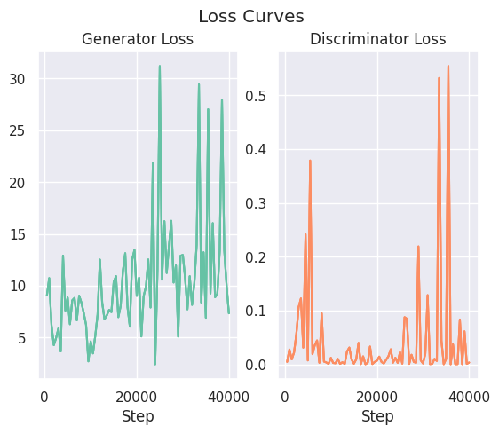

```python
BASE_STEPS = 40000 # Final value should be 40000
best_models = {}
best_cfg = {}

cfg = Configurations({
    'DATA': {
		'name': 'CIFAR10',
		'img_size': 32,
		'num_classes': 10
	},
    'MODEL': {
		'backbone': 'deep_conv',
		'g_cond_mtd': 'cBN',
		'd_cond_mtd': 'PD',
		'g_conv_dim': 'N/A',
		'd_conv_dim': 'N/A'
	},
    'OPTIMIZATION': {
		'd_updates_per_step': 2,
		'total_steps': BASE_STEPS,
		'batch_size': 64,
	}
})

model_name = 'cDCGAN'
trainer = Trainer()
trainer.load(cfg, model_name, DCGAN)
trainer.train()
best_models[model_name] = trainer.best_checkpoint
best_cfg[model_name] = cfg
trainer.plot_loss()

# Reset the trainer and load the best model
trainer = Trainer()
trainer.load(cfg, model_name, DCGAN)
trainer.load_checkpoint(best_models[model_name])
trainer.calc_ndb()
trainer.final_output()
trainer.linear_interpolate()
pass
```

#### Applying **Spectral Normalization:** `cSNGAN`

Spectral Normalization is a method that aims to enforce Lipschitz continuity onto the network. The idea of Lipschitz continuity has been explained above during the Background Research sections. However, what does it mean in **the context of GANs**? In the generator network, enforcing Lipschitz continuity (although less common) means that the network is **robust to perturbations as well as having a more disentangled latent space**. However, applying Spectral Norm to generators is not so common, due to the fact that Lipschitz continuity restricts the change in output/diversity of generated samples and thus would highly likely lead to the generator converging to **mode collapse**.

Rather, the original paper presents the application of Spectral Norm in the discriminator. By limiting the **Lipschitz constant**, we prevent the discriminator from becoming too powerful and overwhelming the generator. This works by restricting the weights of the discriminator to 1, which intuitively means no matter what the input layer is, the magnitude of the output is not increased.

The original SNGAN infact only applies Spectral Normalization to the discriminator network, which we will stick to. We only proceed to add Spectral Normalization to the generator network in later architectures as we will see below, to avoid the potential of **mode collapse** due to the restrictive generator as discussed above.

(Miyato et al., 2018)

**ResNet Backbone**  
Residual Networks, also known as **ResNets**, are a type of deep neural network architecture that was introduced in order to address the problem of **vanishing gradients**, which can occur in very deep neural networks when the gradients of the loss function become too small to effectively update the parameters of the network. The key idea behind **ResNets** is the use of **residual connections**, which are connections that bypass one or more layers of the network and add the input of those layers directly to the output. This allows the gradients to flow more easily through the network, even as the depth of the network increases.

ResNets have been used as a backbone model for many computer vision tasks and have also shown to be useful in other domains such as speech recognition and natural language processing. In the context of GANs, ResNet architectures can also be used as a backbone architecture (He et al., 2015). When using a ResNet as the generator network in a GAN, **the residual connections** and **the use of batch normalization layers** can help to stabilize the training process and improve the quality of the generated images (Salimans et al., 2016). The residual connections, **allow the gradients to flow more easily** through the network, which can help to reduce the risk of mode collapse, a common problem in GANs (Arjovsky et al., 2017).

**Hinge Loss**  
Hinge loss is used as the loss function for discriminator; an alternative to the more commonly used binary cross-entropy loss for the discriminator. Despite being surprisingly simple (as it's just a linear loss function), it has shown to improve both teh stability and performance of GANs (Lim and Ye, 2017). Essentially, it tries to encourage the discriminator to be more confident, thus ultimately make it more robust to the presence of outliers in data (as the discriminator won't just give very vague output distribution of class labels).

Mathetically, it is calculated with $$ l(y) = max(0, 1 - t \cdot y) $$ where $y$ is the classifier score and $t$ is the truth value taking of -1 if `false` and 1 if `true`.

[figure not shown]

*Visualizing Hinge Loss (Image Credits: Ribana Roscher)*

```
Epoch: 256 | Step:  39996 Progress: 100.0% Elapsed: 5:00:05 Gen_loss: 1.713 Dis_loss: 0.4299 Cls_loss: N/A Best FID: 13.6705 Best IS: 8.3369
[INFO] 2023-01-29 18:49:22 > Epoch: 256 | Step:  40001 Progress: 100.0% Elapsed: 5:00:06 Gen_loss: 1.983 Dis_loss: 0.4227 Cls_loss: N/A Best FID: 13.6705 Best IS: 8.3369
```

```
[INFO] 2023-01-29 18:51:32 > Inception Score: 8.184630393981934 | FID: 14.0951244897484
Saving checkpoint 40000 to saves/weights/cSNGAN_256.pt
Files already downloaded and verified
Loading checkpoint: saves/weights/cSNGAN_179.pt
Calculating bin assignments for 10000 samples...
....................................................................................................
```

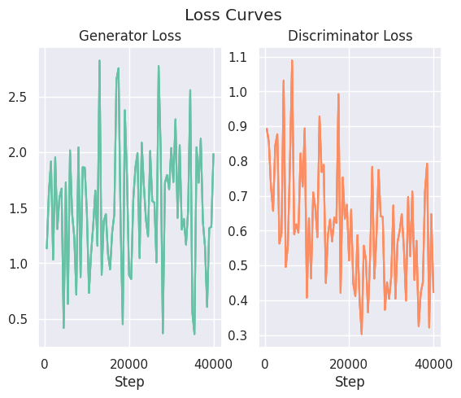

```python
cfg = Configurations({
    'DATA': {
		'name': 'CIFAR10',
		'img_size': 32,
		'num_classes': 10
	},
    'MODEL': {
		'g_cond_mtd': 'cBN',
		'd_cond_mtd': 'PD',
		'apply_d_sn': True
	},
    'LOSS': {
        'adv_loss': 'hinge'
    },
    'OPTIMIZATION': {
		'total_steps': BASE_STEPS,
		'batch_size': 64,
	}
})

model_name = 'cSNGAN'
trainer = Trainer()
trainer.load(cfg, model_name, ResNet)
trainer.train()
best_models[model_name] = trainer.best_checkpoint
best_cfg[model_name] = cfg
trainer.plot_loss()

trainer = Trainer()
trainer.load(cfg, model_name, ResNet)
trainer.load_checkpoint(best_models[model_name])
trainer.calc_ndb()
trainer.final_output()
trainer.linear_interpolate()
pass
```

#### Applying **Self-Attention**: `cSAGAN`

What is self-attention? Traditional convolution layers are local, in the sense that the scope of interactions between inputs is restricted. If the kernel size is less than the image (which it usually is) then one can know that the top left region on an image will only have some interaction with the bottom right region after a certain number of layers. The attention mechanism introduces **global receptive field**. Specifically, it first identifies the dependencies between different tokens on an input, by performing a dot product between two weighted and position-encoded vector embeddings on the input. This leads to a weight matrix that's essentially **calculated on the fly**. The method of producing tokens are generally dependent on the architecture, with the novel Vision Transformer (ViT) using linear layers, while other transformer architectures such as Convolutional Vision Transformers use Convolution layers to generate tokens. Formally, attention is calculated by: $$\text{Att}(Q, K, V) = \text{softmax}(\frac{QK^T}{\sqrt{d_k}})V$$

where $Q, K, V$ are the token matrices.

The authors of the SAGAN (Self Attention GANs) paper showed that their networks were able to:

> leveraging complementary features in distant portions of the image rather than local regions of fixed shape to generate consistent objects/scenarios. (Zhang et al., 2019)

```python
cfg = Configurations({
    'DATA': {
		'name': 'CIFAR10',
		'img_size': 32,
		'num_classes': 10
	},
    'MODEL': {
		'g_cond_mtd': 'cBN',
		'd_cond_mtd': 'PD',
        'apply_g_sn': True,
        'apply_d_sn': True,
        'apply_attn': True,
        'attn_g_loc': [2],
        'attn_d_loc': [1]
	},
    'LOSS': {
        'adv_loss': 'hinge'
    },
    'OPTIMIZATION': {
		'total_steps': BASE_STEPS,
		'batch_size': 64
	}
})

model_name = 'cSAGAN'
trainer = Trainer()
trainer.load(cfg, model_name, ResNet)
trainer.train()
best_models[model_name] = trainer.best_checkpoint
best_cfg[model_name] = cfg
trainer.plot_loss()

trainer = Trainer()
trainer.load(cfg, model_name, ResNet)
trainer.load_checkpoint(best_models[model_name])
trainer.calc_ndb()
trainer.final_output()
trainer.linear_interpolate()
pass
```

```
Epoch: 213 | Step:  33346 Progress: 83.4% Elapsed: 5:43:33 Gen_loss: 1.184 Dis_loss: 0.3962 Cls_loss: N/A Best FID: 15.9302 Best IS: 8.1468
```

#### Applying **BigGAN and DiffAugment**: `BigGAN + DiffAug`

From cSAGAN, we continue add more complexity and introduce more components. This moves us into the direction of BigGAN and DiffAugment.

- Orthogonal Regularization
- Skip connections from Noise
- Exponential Moving Average
- DiffAugment

(Brock, Donahue and Simonyan, 2019)

**Orthogonal Regularization.** This enforces that the weights are orthogonal to each other, in other words tries to enforce that weights have their own specific purpose of doing different things and thus aren't redundant. (Brock, Donahue and Simonyan, 2019)

**Skip Connections from Noise.** Traditionally, the latent noise $z$ would only be connected to the first layer of the generator network. Instead, the concept of skip connections is introduced, connecting the noise $z$ to the entire convolution stack of the generator network. (Brock, Donahue and Simonyan, 2019)

**Exponential moving average.** Used in training GANs that helps to stabilize the training process. It works by maintaining a running average of the generator's parameters. Instead of updating the parameters directly, the EMA updates the parameters with a moving average of their past values, which perhaps can be thought of as similar to momentum in Batch Normalization (Yazıcı et al., 2019). As we see in the code implementation, we instead use the EMA generator parameters to calculate new samples instead of the **current** generator parameters. This is because using the generator with averaged parameters was found to actually improve the quality of the generated images over time and also helps in reducing the risk of mode collapse.

**DiffAugment.** Augments data during GAN training by applying image transformations to both real and generated images. Thus, this allows gradients to flow back to the generator, helping regularize the discriminator without changing the target distribution, and maintains a balance in the training process. The authors of DiffAugment use three specific types of transformations in their experiments: translation, CutOut, and color. (Zhao et al., 2020)

**BigResNet Backbone**  
BigResNet in GANs, refers to a larger variant of ResNets. A BigResNet typically has more layers and more filters per layer than a standard ResNet, making it a more powerful and expressive architecture. The increased capacity of BigResNet allows it to generate higher resolution and more detailed images compared to a standard ResNet. As expected though, that using a BigResNet as the generator network in a GAN can be computationally expensive and require more memory, but the improved image quality can justify the additional computation cost.

```python
BASE_STEPS = 40000
cfg = Configurations({
    'DATA': {
		'name': 'CIFAR10',
		'img_size': 32,
		'num_classes': 10
	},
    'MODEL': {
		'backbone': "big_resnet",
		'g_cond_mtd': "cBN",
		'd_cond_mtd': "PD",
		'apply_g_sn': True,
		'apply_d_sn': True,
		'apply_attn': True,
		'attn_g_loc': [2],
		'attn_d_loc': [1],
		'z_dim': 80,
		'g_shared_dim': 128,
		'g_conv_dim': 96,
		'd_conv_dim': 96,
		'apply_g_ema': True,
		'g_ema_decay': 0.9999,
		'g_ema_start': 1000
	},
	'LOSS': {
		'adv_loss': 'hinge',
	},
    'OPTIMIZATION': {
		'total_steps': BASE_STEPS,
        'batch_size': 64
	},
	'AUG': {
		'apply_diffaug': True,
		'diffaug_type': 'diffaug'
	}
})

model_name = 'BigGAN + DiffAug'
trainer = Trainer()
trainer.load(cfg, model_name, BigResNet)
trainer.train()
best_models[model_name] = trainer.best_checkpoint
best_cfg[model_name] = cfg
trainer.plot_loss()

trainer = Trainer()
trainer.load(cfg, model_name, BigResNet)
trainer.load_checkpoint(best_models[model_name])
trainer.calc_ndb()
trainer.final_output()
trainer.linear_interpolate()
pass
```

```
Epoch: 248 | Step:  38771 Progress: 96.9% Elapsed: 7:24:56 Gen_loss: 0.6915 Dis_loss: 1.205 Cls_loss: N/A Best FID: 9.1786 Best IS: 9.2098
```

[output not shown]

#### Applying **Data-to-Data Cross Entropy** and **Auxiliary Discriminative Classifier**: `ReACGAN + ADC + DiffAug`

There are problems with the traditional Auxiliary Classifier GAN. When training ACGAN, a widely used type of cGAN with softmax cross-entropy loss as an auxiliary classifier, it usually struggles when the number of classes in the dataset increases. Additionally, it also has the problem of generating images with low diversity, to exploit the fact that specific images work best for both classifier and discriminator.

**Data-to-Data Cross Entropy.** This loss allows the discriminator visually compare the differences between multiple images and for data-to-data relationships to develop. This means information across multiple classes can also factor into the deciding factor, thus encouraging inter-class separability and intra-class diversity. (Kang et al., 2021)

**Auxiliary Discriminative Classfiier (ADC)** The typical ACGAN is generator agnostic, in that it is designed to work with any type of generator, and regardless of the architecture. This means there is no specific interaction with the generator, and thus the generator learns to produce label consistent results, leading to low intra class diversity. In essence, it produces strictly classifiable data. Thus, ADC fixes this by introducing the discriminator-like ability to the classifier, encouraging the generator to produce classifiable real datai nstead of classifiable fake data. (Kang et al., 2021)

```
Files already downloaded and verified
Initialize the copied generator's parameters to be source parameters.
Files already downloaded and verified
Loading checkpoint: saves/weights/ReACGAN + ADC + DiffAug_512.pt
Calculating bin assignments for 10000 samples...
....................................................................................................
```

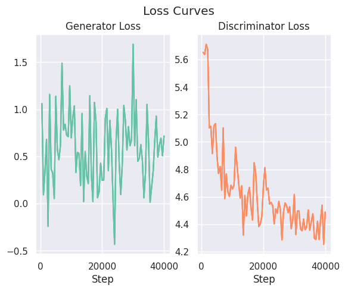

```python
BASE_STEPS = 40000
eval_set = torchvision.datasets.CIFAR10(root='./data', train=True,
										download=True, transform=preprop)
EVAL_MODEL = LoadEvalModel()
eval_dataloader = torch.utils.data.DataLoader(eval_set, batch_size=128, drop_last=False)
MU, SIGMA = prepare_moments(data_loader = eval_dataloader,
							eval_model = EVAL_MODEL,
							quantize = True, batch_size = 128)


cfg = Configurations({
    'DATA': {
		'name': 'CIFAR10',
		'img_size': 32,
		'num_classes': 10
	},
    'MODEL': {
		'backbone': "big_resnet",
		'g_cond_mtd': "cBN",
		'd_cond_mtd': "D2DCE",
        'aux_cls_type': 'ADC',
        'normalize_d_embed': True,
        'd_embed_dim': 512,
		'apply_g_sn': True,
		'apply_d_sn': True,
		'apply_attn': True,
		'attn_g_loc': [2],
		'attn_d_loc': [1],
		'z_dim': 80,
		'g_shared_dim': 128,
		'g_conv_dim': 96,
		'd_conv_dim': 96,
		'apply_g_ema': True,
		'g_ema_decay': 0.9999,
		'g_ema_start': 1000
	},
	'LOSS': {
		'adv_loss': 'hinge',
        'cond_lambda': 0.5,
        'm_p': 0.98,
        'temperature': 0.5
	},
    'OPTIMIZATION': {
		'batch_size': 128,
		'total_steps': BASE_STEPS,
        'g_lr': 0.00028284271,
        'd_lr': 0.00028284271
	},
	'AUG': {
		'apply_diffaug': True,
		'diffaug_type': 'diffaug'
	}
})
model_name = 'ReACGAN + ADC + DiffAug'
trainer = Trainer()
trainer.load(cfg, model_name, BigResNet)
trainer.train()
best_models[model_name] = trainer.best_checkpoint
best_cfg[model_name] = cfg
trainer.plot_loss()

trainer = Trainer()
trainer.load(cfg, model_name, BigResNet)
trainer.load_checkpoint(best_models[model_name])
trainer.calc_ndb()
trainer.final_output()
trainer.linear_interpolate()
pass
```

### **Evaluation of Models**

We evaluate the models by performing **4 different analyses**. They are:

- Image Fidelity
- Latent Space Evolution
- Content Diversity
- Semantic Consistency

#### Evaluating **Image Fidelity**

Here, we will use **Inception Score** and **Frechet Inception Distance** to analyze the metrics. The reason we use these two is because we want to see how our model stacks up to the best models in the world. As other metrics such as iFID and KID are difficult to find on the benchmarks as they are less popular, we avoid them, despite metrics such as KID proving to be a strong and robust metric. Both these metrics use a **Pretrained Inception V3**. Note that this model should be the InceptionV3 Tensorflow version and not the Pytorch, to perform accurate assessment.

```python
METRIC_TRACKER.show_table()
```

|  | Best FID | Best IS |
| --- | --- | --- |
| cDCGAN | 59.2968 | 5.8791 |
| cSAGAN | 14.1824 | 8.2259 |
| cSNGAN | 13.6704 | 8.3368 |
| BigGAN + DiffAug | 8.7205 | 9.2516 |
| ReACGAN + ADC + DiffAug | 8.2247 | 9.3662 |

Plotting the graph over time. We retrieve the Inception Scores and Frechet Inception Distance over time from the logs folder and plot the graphs respectively.

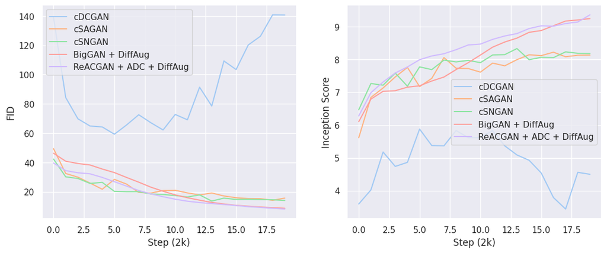

```python
METRIC_TRACKER.plot()
```

We observe:

On the paperswithcode leaderboard, our ReACGAN places around the **6th position** on the paperswithcode leaderboard, in terms of Inception Score and **9th** in terms of Frechet Inception Distance. Link: https://paperswithcode.com/sota/conditional-image-generation-on-cifar-10.

### Evaluating **Latent Space Evolution**

#### Evolution of: **`cSAGAN`**

There are a few observations we can make out of cSAGAN's latent space evolution.

- Changes are drastic, however there is some shape that it tries to maintain
- Color seems to change quite often for automobiles and airplanes
- It contradicts itself, in that for a few steps it works towards **one direction**, then it completely goes back on what it just did. As an example, see the 3rd and 5th Airplane images.
- Thus, the changes over time are **oscillating and drastic.**

[figure not shown]

#### Evolution of: **`BigGAN + DiffAug`**

[figure not shown]

#### Evolution of: **`ReACGAN + ADC + DiffAug`**

- Similar to BigGAN, how the initial change is large, but then changes are smooth as the number of step increases.
- What is interesting is how, we see both BigGAN and ReACGAN actually making realistic images from weird images.

[figure not shown]

#### Evaluating **Content Diversity**

Thus, how can we assess this? One metric is to use **Number of statistically-different bins (NDB Score)**. How does it work?

1. Suppose we have a training set and a fake set.
2. Using K-Means clustering, **divide** the training set into **$K$ number of clusters**
3. Using the centroids of the K clusters, now allocate the images in the fake set to these $K$ clusters, thus forming $K$ bins.
4. Conduct a two-sample test between the train and fake samples for each bin and **calculate the Z-score**.
5. If the z-score is below a certain threshold, mark the bin as statistically different.
6. Find the number of statistically different bins and divide by $K$.

Intuitively, one can think of it as each of the classes having 10 different bins. For example, a horse may have a white horse, a larger horse, small horse and so on. The fake set will then be assigned to the categorization it is most closest to. If any mode collapse happens where there is one feature that is prominent everywhere e.g. too many white horses for a given random distribution, then we know mode collapse is occuring.

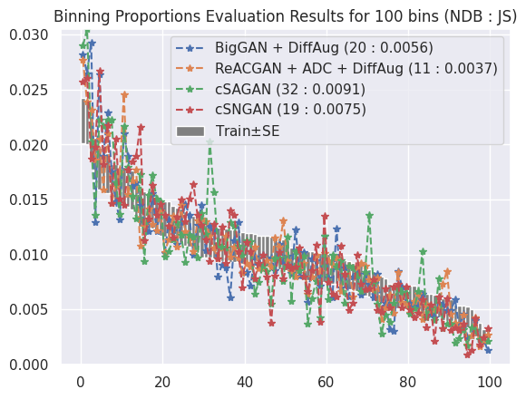

```python
ndb.plot_results()
```

```python
ndb.print_results()
```

```
NSB results (K=100, data whitening):
BigGAN + DiffAug: NDB = 20, NDB/K = 0.200, JS = 0.0056
ReACGAN + ADC + DiffAug: NDB = 11, NDB/K = 0.110, JS = 0.0037
cSAGAN: NDB = 32, NDB/K = 0.320, JS = 0.0091
cSNGAN: NDB = 19, NDB/K = 0.190, JS = 0.0075
```

We observe:

- ReACGAN has the **lowest number** of statistically different bins of **11**
- SAGAN has the **highest number** of statistically different bins of **32**
- BigGAN and cSNGAN are relatively the same at 20 and 19 respectively.
- This tells us that **although BigGAN has Image Fidelity performance levels very similar to ReACGAN**, it suffers from some form of mode collapse where certain features of certain classes are missing.
- Thus ReACGAN appears to be much more robust to this.

#### Evaluating **Semantic Consistency**

Here, we evaluate whether there may be perturbations across one dimension of latent space and also want to identify and observe the property of latent space disentanglement. **How do we do this?** I propose the idea of performing Linear Interpolation Analysis.

1. To start off, we randomly sample our latent space from a Gaussian distribution.
2. We then randomly select **one dimension** of the latent space to edit
3. Next, we **interpolate** on this one dimension, from values **-5 to 5**. I chose these values as they would let us see the most extreme of both ends.
4. Repeat with random selection of latent space dimensions.

NOTE that we want to reset -5 to 5 for every class, but ensure that everything else is the same. Even the originally sampled latent space itself.  
Below, we have performed such on our best model `ReACGAN`.

[figure not shown]

*There seems to be some entanglement here. Specifically, if we look at horse, both the color and size changes going along one dimension. However, this could be that the specific species of white horses are smaller, and so by making the horse more white, it also goes smaller as well.*

[figure not shown]

*We observe color interpolation along ReACGAN*

Is there an alternative method? I have thought of perhaps running an exhausting search, for instance using the patch perception **LPIPS** and performing a pair-wise mean score, then finding the average. However, this was computationally intensive and difficult to implement.

A possible improvement to the current method I'm using, could be to attach some sort of feature extractor to the K Means clustering, so that we would be able to use the power of CNNs into choosing the embeddings instead of letting the pixel relationships develop themselves from the K Means algorithm (which would likely be more inaccurate than the proposed use of CNNs).

### Final Images

Here's all the final images. **1000 images** total, with **100 images per class**. The images can be found in the folder `final_output/` as well.

[figure not shown]

### Conclusion

- I learned a lot about GANs, starting off with very simple components and expanding to more complicated technologies such as Projection Discriminator, Spectral Norm, Auxiliary Classifier, and Data2Data Cross Entropy Loss.
- It was difficult trying to refer to and adapt modularized code into Jupyter Notebook, but am very happy that I was successful and managed to pull it off.
- I came up with and explored new interesting methods of evaluating generated images, to further understand the GAN model.

#### In the future:

I believe that exploring the use of **more interesting evaluation metrics** is something I am interested in looking more about. While assessing the **fidelity of images** is an important aspect of evaluating the performance of a generative model, it is also important to consider other metrics such as **inter- and intra- class diversity, as well as disentanglement** of the latent space. From my research, it appears that there is **plenty of effort** on assessing the fidelity of images, but there is still room for growth in terms of evaluating the **diversity and disentanglement** of the generated images. I hope to explore more of this domain in my own time; **more robust and effective methods** of evaluating these factors could provide a more comprehensive understanding of the capabilities of one's generative model.

By: Kenneth Chen

[figure not shown]

*Here's a meme generated by MidJourney* 😊